# 000409_IBL_bwm_usage_notebook_ipynb

## Installing requirements

The cell below installs every Python package needed to run this notebook, at fully pinned versions, using [`uv`](https://github.com/astral-sh/uv) for fast resolution. In Colab the cell is collapsed by default — click the ▶ button to run it.

```python
# install cell skipped during CI (deps preinstalled into system Python)
```

> **⚠️ Restart runtime after install**

> The install may upgrade packages already loaded in the kernel. Go to **Runtime → Restart session**, then **Run all cells below** (skip this install cell on re-run).

This document is intended to showcase usage and allow the IBL team to access example data until we decide about uploading the full dataset. The idea is to iterate and add improvements to the structure, suggest visualization and data access patterns that might be desirable for the final documentation.

To use it, you will need to run this notebook in an environment that has both pynwb and remfile installed plus any additional dependencies that we use for analysis such as matplotib, numpy, pandas, etc.

# Locate Examples

```python
import h5py
import remfile
from dandi.dandiapi import DandiAPIClient
from pynwb import NWBHDF5IO

# Connect to DANDI and get the dandiset
dandiset_id = "000409"
dandiset_version = "0.260309.1324"
client = DandiAPIClient()
dandiset = client.get_dandiset(dandiset_id, dandiset_version)

# =============================================================================
# Session EIDs for NEW format files (desc-raw / desc-processed)
# =============================================================================

# Complete session with 2 probes - Session 1 (NYU-39, 2021-05-10, angelakilab)
# - Full data: all videos, pose estimation, spike sorting for both probes
TWO_PROBE_SESSION_EID_1 = "6ed57216-498d-48a6-b48b-a243a34710ea"

# Complete session with 2 probes - Session 2 (NYU-39, 2021-05-11, angelakilab)
# - Full data: all videos, pose estimation, spike sorting for both probes
TWO_PROBE_SESSION_EID_2 = "35ed605c-1a1a-47b1-86ff-2b56144f55af"

# Complete session with 1 probe (NYU-46, 2021-06-25, angelakilab)
# - Full data: all videos, pose estimation, spike sorting for probe01
ONE_PROBE_SESSION_EID = "64e3fb86-928c-4079-865c-b364205b502e"

# Choose which session to use
session_eid = ONE_PROBE_SESSION_EID  # Change to TWO_PROBE_SESSION_EID_2 or ONE_PROBE_SESSION_EID
session_eid = "78b4fff5-c5ec-44d9-b5f9-d59493063f00"
# session_eid = "6713a4a7-faed-4df2-acab-ee4e63326f8"
# session_eid = "196a2adf-ff83-49b2-823a-33f990049c2"

# =============================================================================
# Fetch assets by EID
# =============================================================================

# First, filter asse    ts by EID
session_assets = [asset for asset in dandiset.get_assets() if session_eid in asset.path]

# Then, extract raw and processed files
raw_asset = next((asset for asset in session_assets if "desc-raw" in asset.path), None)
processed_asset = next((asset for asset in session_assets if "desc-processed" in asset.path), None)

print(f"Session EID: {session_eid}")
print(f"\nRaw file:       {raw_asset.path if raw_asset else 'Not found'}")
print(f"Processed file: {processed_asset.path if processed_asset else 'Not found'}")
```

```
Session EID: 78b4fff5-c5ec-44d9-b5f9-d59493063f00

Raw file:       sub-KS091/sub-KS091_ses-78b4fff5-c5ec-44d9-b5f9-d59493063f00_desc-raw_ecephys.nwb
Processed file: sub-KS091/sub-KS091_ses-78b4fff5-c5ec-44d9-b5f9-d59493063f00_desc-processed_behavior+ecephys.nwb
```

# Raw NWB file

The raw data is stored in a separate file from the processed data. The raw data file contains the acquisition module with the raw ephys data (both AP and LF bands); video metadata (which includes properly aligned timestamps) and a link to the video files; and, when available, the NIDQ board data.

```python
s3_url = raw_asset.get_content_url(follow_redirects=1, strip_query=False)
file_system = remfile.File(s3_url)
file = h5py.File(file_system, mode="r")

io = NWBHDF5IO(file=file)
nwbfile_raw = io.read()
```

```python
nwbfile_raw.session_start_time
```

```
datetime.datetime(2022, 7, 4, 14, 30, 15, 49000, tzinfo=tzoffset(None, 3600))
```

```python
devices = nwbfile_raw.devices
probe_devices = [devices[name] for name in devices if "Probe" in name]
for probe_device in probe_devices:
    print(f"{probe_device.name}: {probe_device.serial_number}")
```

```
Probe00: 18005102151
Probe01: 18194814141
```

```python
nwbfile_raw
```

root (NWBFile)

session_description:

identifier: b7acca58-2558-4ec2-a797-23f49bc2316e

**session_start_time**

2022-07-04 14:30:15.049000+01:00

**timestamps_reference_time**

2022-07-04 14:30:15.049000+01:00

**file_create_date**

**0**

2026-02-08 09:53:57.452180+00:00

**acquisition**

**ElectricalSeriesProbe00AP (ElectricalSeries)**

resolution: -1.0

comments: no comments

description: Acquisition traces for the ElectricalSeriesProbe00AP.

conversion: 2.34375e-06

offset: 0.0

unit: volts

**data**

HDF5 dataset

| Data type | int16 |
| --- | --- |
| Shape | (164362247, 384) |
| Array size | 117.56 GiB |
| Chunk shape | (13020, 384) |
| Compression | gzip |
| Compression opts | 4 |
| Uncompressed size (bytes) | 126230205696 |
| Compressed size (bytes) | 61453524661 |
| Compression ratio | 2.0540759279851195 |

**timestamps**

HDF5 dataset

| Data type | float64 |
| --- | --- |
| Shape | (164362247,) |
| Array size | 1.22 GiB |
| Chunk shape | (1250000,) |
| Compression | gzip |
| Compression opts | 4 |
| Uncompressed size (bytes) | 1314897976 |
| Compressed size (bytes) | 793462428 |
| Compression ratio | 1.6571647624378756 |

timestamps_unit: seconds

interval: 1

**electrodes (DynamicTableRegion)**

description: electrode_table_region

**table (ElectrodesTable)**

description: metadata about extracellular electrodes

**columns**

**location**

Location of the electrode (channel).

**group**

Reference to the ElectrodeGroup.

**electrode_name**

Unique identifier derived from probe contact ids.

**contact_shapes**

Contact shape per electrode as defined by the probe.

**channel_name**

The name of this channel, showing all recording streams for the electrode (e.g., 'AP379,LF379').

**rel_x**

Relative x coordinate on the probe (µm).

**rel_y**

Relative y coordinate on the probe (µm).

**probe_name**

IBL probe name in canonical format (e.g., 'Probe00', 'Probe01').

**contact_ids**

Channel IDs as specified by the probe manufacturer.

**shank_ids**

Shank ID for each electrode (for multi-shank probes).

**adc_group**

ADC group index from SpikeGLX metadata.

**adc_sample_order**

ADC sample order from SpikeGLX metadata.

**group_name**

Name of the ElectrodeGroup.

**x**

x coordinate of the channel location in the brain.

**y**

y coordinate of the channel location in the brain.

**z**

z coordinate of the channel location in the brain.

**imp**

Impedance of the channel, in ohms.

**filtering**

Description of hardware filtering.

**table**

| id | location | group | electrode_name | contact_shapes | channel_name | rel_x | rel_y | probe_name | contact_ids | shank_ids | adc_group | adc_sample_order | group_name | x | y | z | imp | filtering |
| --- | --- | --- | --- | --- | --- | --- | --- | --- | --- | --- | --- | --- | --- | --- | --- | --- | --- | --- |
| 0 | Infralimbic area layer 1 | Probe01 pynwb.ecephys.ElectrodeGroup at 0x138908627194320\nFields:\n description: Electrode group for probe01\n device: Probe01 pynwb.device.Device at 0x138908627194000\nFields:\n description: A PRB_1… | e0 | square | AP0,LF0 | 16.0 | 0.0 | Probe01 | e0 |  | 0 | 0 | Probe01 | 3401.0 | 4105.0 | 5751.0 | NaN |  |
| 1 | Infralimbic area layer 1 | Probe01 pynwb.ecephys.ElectrodeGroup at 0x138908627194320\nFields:\n description: Electrode group for probe01\n device: Probe01 pynwb.device.Device at 0x138908627194000\nFields:\n description: A PRB_1… | e1 | square | AP1,LF1 | 48.0 | 0.0 | Probe01 | e1 |  | 1 | 0 | Probe01 | 3401.0 | 4105.0 | 5751.0 | NaN |  |
| 2 | Infralimbic area layer 1 | Probe01 pynwb.ecephys.ElectrodeGroup at 0x138908627194320\nFields:\n description: Electrode group for probe01\n device: Probe01 pynwb.device.Device at 0x138908627194000\nFields:\n description: A PRB_1… | e2 | square | AP2,LF2 | 0.0 | 20.0 | Probe01 | e2 |  | 0 | 1 | Probe01 | 3401.0 | 4087.0 | 5745.0 | NaN |  |
| 3 | Infralimbic area layer 1 | Probe01 pynwb.ecephys.ElectrodeGroup at 0x138908627194320\nFields:\n description: Electrode group for probe01\n device: Probe01 pynwb.device.Device at 0x138908627194000\nFields:\n description: A PRB_1… | e3 | square | AP3,LF3 | 32.0 | 20.0 | Probe01 | e3 |  | 1 | 1 | Probe01 | 3401.0 | 4087.0 | 5745.0 | NaN |  |

... and 764 more row(s).

**ElectricalSeriesProbe00LF (ElectricalSeries)**

resolution: -1.0

comments: no comments

description: Acquisition traces for the ElectricalSeriesProbe00LF.

conversion: 4.6875e-06

offset: 0.0

unit: volts

**data**

HDF5 dataset

| Data type | int16 |
| --- | --- |
| Shape | (13696854, 384) |
| Array size | 9.80 GiB |
| Chunk shape | (13020, 384) |
| Compression | gzip |
| Compression opts | 4 |
| Uncompressed size (bytes) | 10519183872 |
| Compressed size (bytes) | 5364846101 |
| Compression ratio | 1.9607615342477835 |

**timestamps**

HDF5 dataset

| Data type | float64 |
| --- | --- |
| Shape | (13696854,) |
| Array size | 104.50 MiB |
| Chunk shape | (1250000,) |
| Compression | gzip |
| Compression opts | 4 |
| Uncompressed size (bytes) | 109574832 |
| Compressed size (bytes) | 71276130 |
| Compression ratio | 1.5373285839172244 |

timestamps_unit: seconds

interval: 1

**electrodes (DynamicTableRegion)**

description: electrode_table_region

**table (ElectrodesTable)**

description: metadata about extracellular electrodes

**columns**

**location**

Location of the electrode (channel).

**group**

Reference to the ElectrodeGroup.

**electrode_name**

Unique identifier derived from probe contact ids.

**contact_shapes**

Contact shape per electrode as defined by the probe.

**channel_name**

The name of this channel, showing all recording streams for the electrode (e.g., 'AP379,LF379').

**rel_x**

Relative x coordinate on the probe (µm).

**rel_y**

Relative y coordinate on the probe (µm).

**probe_name**

IBL probe name in canonical format (e.g., 'Probe00', 'Probe01').

**contact_ids**

Channel IDs as specified by the probe manufacturer.

**shank_ids**

Shank ID for each electrode (for multi-shank probes).

**adc_group**

ADC group index from SpikeGLX metadata.

**adc_sample_order**

ADC sample order from SpikeGLX metadata.

**group_name**

Name of the ElectrodeGroup.

**x**

x coordinate of the channel location in the brain.

**y**

y coordinate of the channel location in the brain.

**z**

z coordinate of the channel location in the brain.

**imp**

Impedance of the channel, in ohms.

**filtering**

Description of hardware filtering.

**table**

| id | location | group | electrode_name | contact_shapes | channel_name | rel_x | rel_y | probe_name | contact_ids | shank_ids | adc_group | adc_sample_order | group_name | x | y | z | imp | filtering |
| --- | --- | --- | --- | --- | --- | --- | --- | --- | --- | --- | --- | --- | --- | --- | --- | --- | --- | --- |
| 0 | Infralimbic area layer 1 | Probe01 pynwb.ecephys.ElectrodeGroup at 0x138908627194320\nFields:\n description: Electrode group for probe01\n device: Probe01 pynwb.device.Device at 0x138908627194000\nFields:\n description: A PRB_1… | e0 | square | AP0,LF0 | 16.0 | 0.0 | Probe01 | e0 |  | 0 | 0 | Probe01 | 3401.0 | 4105.0 | 5751.0 | NaN |  |
| 1 | Infralimbic area layer 1 | Probe01 pynwb.ecephys.ElectrodeGroup at 0x138908627194320\nFields:\n description: Electrode group for probe01\n device: Probe01 pynwb.device.Device at 0x138908627194000\nFields:\n description: A PRB_1… | e1 | square | AP1,LF1 | 48.0 | 0.0 | Probe01 | e1 |  | 1 | 0 | Probe01 | 3401.0 | 4105.0 | 5751.0 | NaN |  |
| 2 | Infralimbic area layer 1 | Probe01 pynwb.ecephys.ElectrodeGroup at 0x138908627194320\nFields:\n description: Electrode group for probe01\n device: Probe01 pynwb.device.Device at 0x138908627194000\nFields:\n description: A PRB_1… | e2 | square | AP2,LF2 | 0.0 | 20.0 | Probe01 | e2 |  | 0 | 1 | Probe01 | 3401.0 | 4087.0 | 5745.0 | NaN |  |
| 3 | Infralimbic area layer 1 | Probe01 pynwb.ecephys.ElectrodeGroup at 0x138908627194320\nFields:\n description: Electrode group for probe01\n device: Probe01 pynwb.device.Device at 0x138908627194000\nFields:\n description: A PRB_1… | e3 | square | AP3,LF3 | 32.0 | 20.0 | Probe01 | e3 |  | 1 | 1 | Probe01 | 3401.0 | 4087.0 | 5745.0 | NaN |  |

... and 764 more row(s).

**ElectricalSeriesProbe01AP (ElectricalSeries)**

resolution: -1.0

comments: no comments

description: Acquisition traces for the ElectricalSeriesProbe01AP.

conversion: 2.34375e-06

offset: 0.0

unit: volts

**data**

HDF5 dataset

| Data type | int16 |
| --- | --- |
| Shape | (164362400, 384) |
| Array size | 117.56 GiB |
| Chunk shape | (13020, 384) |
| Compression | gzip |
| Compression opts | 4 |
| Uncompressed size (bytes) | 126230323200 |
| Compressed size (bytes) | 61994169449 |
| Compression ratio | 2.036164438074203 |

**timestamps**

HDF5 dataset

| Data type | float64 |
| --- | --- |
| Shape | (164362400,) |
| Array size | 1.22 GiB |
| Chunk shape | (1250000,) |
| Compression | gzip |
| Compression opts | 4 |
| Uncompressed size (bytes) | 1314899200 |
| Compressed size (bytes) | 793389570 |
| Compression ratio | 1.6573184847892568 |

timestamps_unit: seconds

interval: 1

**electrodes (DynamicTableRegion)**

description: electrode_table_region

**table (ElectrodesTable)**

description: metadata about extracellular electrodes

**columns**

**location**

Location of the electrode (channel).

**group**

Reference to the ElectrodeGroup.

**electrode_name**

Unique identifier derived from probe contact ids.

**contact_shapes**

Contact shape per electrode as defined by the probe.

**channel_name**

The name of this channel, showing all recording streams for the electrode (e.g., 'AP379,LF379').

**rel_x**

Relative x coordinate on the probe (µm).

**rel_y**

Relative y coordinate on the probe (µm).

**probe_name**

IBL probe name in canonical format (e.g., 'Probe00', 'Probe01').

**contact_ids**

Channel IDs as specified by the probe manufacturer.

**shank_ids**

Shank ID for each electrode (for multi-shank probes).

**adc_group**

ADC group index from SpikeGLX metadata.

**adc_sample_order**

ADC sample order from SpikeGLX metadata.

**group_name**

Name of the ElectrodeGroup.

**x**

x coordinate of the channel location in the brain.

**y**

y coordinate of the channel location in the brain.

**z**

z coordinate of the channel location in the brain.

**imp**

Impedance of the channel, in ohms.

**filtering**

Description of hardware filtering.

**table**

| id | location | group | electrode_name | contact_shapes | channel_name | rel_x | rel_y | probe_name | contact_ids | shank_ids | adc_group | adc_sample_order | group_name | x | y | z | imp | filtering |
| --- | --- | --- | --- | --- | --- | --- | --- | --- | --- | --- | --- | --- | --- | --- | --- | --- | --- | --- |
| 0 | Infralimbic area layer 1 | Probe01 pynwb.ecephys.ElectrodeGroup at 0x138908627194320\nFields:\n description: Electrode group for probe01\n device: Probe01 pynwb.device.Device at 0x138908627194000\nFields:\n description: A PRB_1… | e0 | square | AP0,LF0 | 16.0 | 0.0 | Probe01 | e0 |  | 0 | 0 | Probe01 | 3401.0 | 4105.0 | 5751.0 | NaN |  |
| 1 | Infralimbic area layer 1 | Probe01 pynwb.ecephys.ElectrodeGroup at 0x138908627194320\nFields:\n description: Electrode group for probe01\n device: Probe01 pynwb.device.Device at 0x138908627194000\nFields:\n description: A PRB_1… | e1 | square | AP1,LF1 | 48.0 | 0.0 | Probe01 | e1 |  | 1 | 0 | Probe01 | 3401.0 | 4105.0 | 5751.0 | NaN |  |
| 2 | Infralimbic area layer 1 | Probe01 pynwb.ecephys.ElectrodeGroup at 0x138908627194320\nFields:\n description: Electrode group for probe01\n device: Probe01 pynwb.device.Device at 0x138908627194000\nFields:\n description: A PRB_1… | e2 | square | AP2,LF2 | 0.0 | 20.0 | Probe01 | e2 |  | 0 | 1 | Probe01 | 3401.0 | 4087.0 | 5745.0 | NaN |  |
| 3 | Infralimbic area layer 1 | Probe01 pynwb.ecephys.ElectrodeGroup at 0x138908627194320\nFields:\n description: Electrode group for probe01\n device: Probe01 pynwb.device.Device at 0x138908627194000\nFields:\n description: A PRB_1… | e3 | square | AP3,LF3 | 32.0 | 20.0 | Probe01 | e3 |  | 1 | 1 | Probe01 | 3401.0 | 4087.0 | 5745.0 | NaN |  |

... and 764 more row(s).

**ElectricalSeriesProbe01LF (ElectricalSeries)**

resolution: -1.0

comments: no comments

description: Acquisition traces for the ElectricalSeriesProbe01LF.

conversion: 4.6875e-06

offset: 0.0

unit: volts

**data**

HDF5 dataset

| Data type | int16 |
| --- | --- |
| Shape | (13696867, 384) |
| Array size | 9.80 GiB |
| Chunk shape | (13020, 384) |
| Compression | gzip |
| Compression opts | 4 |
| Uncompressed size (bytes) | 10519193856 |
| Compressed size (bytes) | 5387497680 |
| Compression ratio | 1.9525194219666002 |

**timestamps**

HDF5 dataset

| Data type | float64 |
| --- | --- |
| Shape | (13696867,) |
| Array size | 104.50 MiB |
| Chunk shape | (1250000,) |
| Compression | gzip |
| Compression opts | 4 |
| Uncompressed size (bytes) | 109574936 |
| Compressed size (bytes) | 71277703 |
| Compression ratio | 1.5372961162903918 |

timestamps_unit: seconds

interval: 1

**electrodes (DynamicTableRegion)**

description: electrode_table_region

**table (ElectrodesTable)**

description: metadata about extracellular electrodes

**columns**

**location**

Location of the electrode (channel).

**group**

Reference to the ElectrodeGroup.

**electrode_name**

Unique identifier derived from probe contact ids.

**contact_shapes**

Contact shape per electrode as defined by the probe.

**channel_name**

The name of this channel, showing all recording streams for the electrode (e.g., 'AP379,LF379').

**rel_x**

Relative x coordinate on the probe (µm).

**rel_y**

Relative y coordinate on the probe (µm).

**probe_name**

IBL probe name in canonical format (e.g., 'Probe00', 'Probe01').

**contact_ids**

Channel IDs as specified by the probe manufacturer.

**shank_ids**

Shank ID for each electrode (for multi-shank probes).

**adc_group**

ADC group index from SpikeGLX metadata.

**adc_sample_order**

ADC sample order from SpikeGLX metadata.

**group_name**

Name of the ElectrodeGroup.

**x**

x coordinate of the channel location in the brain.

**y**

y coordinate of the channel location in the brain.

**z**

z coordinate of the channel location in the brain.

**imp**

Impedance of the channel, in ohms.

**filtering**

Description of hardware filtering.

**table**

| id | location | group | electrode_name | contact_shapes | channel_name | rel_x | rel_y | probe_name | contact_ids | shank_ids | adc_group | adc_sample_order | group_name | x | y | z | imp | filtering |
| --- | --- | --- | --- | --- | --- | --- | --- | --- | --- | --- | --- | --- | --- | --- | --- | --- | --- | --- |
| 0 | Infralimbic area layer 1 | Probe01 pynwb.ecephys.ElectrodeGroup at 0x138908627194320\nFields:\n description: Electrode group for probe01\n device: Probe01 pynwb.device.Device at 0x138908627194000\nFields:\n description: A PRB_1… | e0 | square | AP0,LF0 | 16.0 | 0.0 | Probe01 | e0 |  | 0 | 0 | Probe01 | 3401.0 | 4105.0 | 5751.0 | NaN |  |
| 1 | Infralimbic area layer 1 | Probe01 pynwb.ecephys.ElectrodeGroup at 0x138908627194320\nFields:\n description: Electrode group for probe01\n device: Probe01 pynwb.device.Device at 0x138908627194000\nFields:\n description: A PRB_1… | e1 | square | AP1,LF1 | 48.0 | 0.0 | Probe01 | e1 |  | 1 | 0 | Probe01 | 3401.0 | 4105.0 | 5751.0 | NaN |  |
| 2 | Infralimbic area layer 1 | Probe01 pynwb.ecephys.ElectrodeGroup at 0x138908627194320\nFields:\n description: Electrode group for probe01\n device: Probe01 pynwb.device.Device at 0x138908627194000\nFields:\n description: A PRB_1… | e2 | square | AP2,LF2 | 0.0 | 20.0 | Probe01 | e2 |  | 0 | 1 | Probe01 | 3401.0 | 4087.0 | 5745.0 | NaN |  |
| 3 | Infralimbic area layer 1 | Probe01 pynwb.ecephys.ElectrodeGroup at 0x138908627194320\nFields:\n description: Electrode group for probe01\n device: Probe01 pynwb.device.Device at 0x138908627194000\nFields:\n description: A PRB_1… | e3 | square | AP3,LF3 | 32.0 | 20.0 | Probe01 | e3 |  | 1 | 1 | Probe01 | 3401.0 | 4087.0 | 5745.0 | NaN |  |

... and 764 more row(s).

**EventsAudio (LabeledEvents)**

description: Auditory stimulus presentation events. Marks timing of audio stimulus delivery for auditory tasks or cue presentation. Label meanings: - audio_off: Audio stimulus off - audio_on: Audio stimulus on

**timestamps**

HDF5 dataset

| Data type | float64 |
| --- | --- |
| Shape | (2392,) |
| Array size | 18.69 KiB |
| Chunk shape | None |
| Compression | None |
| Compression opts | None |
| Uncompressed size (bytes) | 19136 |
| Compressed size (bytes) | 19136 |
| Compression ratio | 1.0 |

timestamps__unit: seconds

**data**

HDF5 dataset

| Data type | uint64 |
| --- | --- |
| Shape | (2392,) |
| Array size | 18.69 KiB |
| Chunk shape | None |
| Compression | None |
| Compression opts | None |
| Uncompressed size (bytes) | 19136 |
| Compressed size (bytes) | 19136 |
| Compression ratio | 1.0 |

**data__labels**

NumPy array

| Data type | object |
| --- | --- |
| Shape | (2,) |
| Array size | 16.00 bytes |

['audio_off' 'audio_on']

**EventsBodyCamera (LabeledEvents)**

description: Video frame acquisition times for the body camera. Each event marks when a video frame was captured by the camera, enabling temporal alignment of behavior videos with neural and task data. Label meanings: - exposure_end: Camera exposure end or frame readout complete - frame_start: Camera frame acquisition start (frame timestamp)

**timestamps**

HDF5 dataset

| Data type | float64 |
| --- | --- |
| Shape | (321934,) |
| Array size | 2.46 MiB |
| Chunk shape | None |
| Compression | None |
| Compression opts | None |
| Uncompressed size (bytes) | 2575472 |
| Compressed size (bytes) | 2575472 |
| Compression ratio | 1.0 |

timestamps__unit: seconds

**data**

HDF5 dataset

| Data type | uint64 |
| --- | --- |
| Shape | (321934,) |
| Array size | 2.46 MiB |
| Chunk shape | None |
| Compression | None |
| Compression opts | None |
| Uncompressed size (bytes) | 2575472 |
| Compressed size (bytes) | 2575472 |
| Compression ratio | 1.0 |

**data__labels**

NumPy array

| Data type | object |
| --- | --- |
| Shape | (2,) |
| Array size | 16.00 bytes |

['exposure_end' 'frame_start']

**EventsFrame2ttl (LabeledEvents)**

description: Monitor refresh events detected by photodiode for visual stimulus timing. The Frame2TTL device uses a photodiode to detect changes in screen luminance, providing precise timing of when visual stimuli are displayed on the monitor. This is essential for accurate stimulus-response latency measurements. Label meanings: - screen_dark: Screen transitioned to dark (photodiode detected low luminance) - screen_bright: Screen transitioned to bright (photodiode detected high luminance)

**timestamps**

HDF5 dataset

| Data type | float64 |
| --- | --- |
| Shape | (2250,) |
| Array size | 17.58 KiB |
| Chunk shape | None |
| Compression | None |
| Compression opts | None |
| Uncompressed size (bytes) | 18000 |
| Compressed size (bytes) | 18000 |
| Compression ratio | 1.0 |

timestamps__unit: seconds

**data**

HDF5 dataset

| Data type | uint64 |
| --- | --- |
| Shape | (2250,) |
| Array size | 17.58 KiB |
| Chunk shape | None |
| Compression | None |
| Compression opts | None |
| Uncompressed size (bytes) | 18000 |
| Compressed size (bytes) | 18000 |
| Compression ratio | 1.0 |

**data__labels**

NumPy array

| Data type | object |
| --- | --- |
| Shape | (2,) |
| Array size | 16.00 bytes |

['screen_dark' 'screen_bright']

**EventsImecSync (LabeledEvents)**

description: Multi-probe synchronization signal (1 Hz square wave). This signal is simultaneously recorded on NIDQ and all Neuropixels probes, enabling precise temporal alignment across multiple recording devices. The 1 Hz square wave provides regular alignment points for drift correction. Label meanings: - sync_low: Sync signal low phase (0.5s duration at 1 Hz) - sync_high: Sync signal high phase (0.5s duration at 1 Hz)

**timestamps**

HDF5 dataset

| Data type | float64 |
| --- | --- |
| Shape | (51712,) |
| Array size | 404.00 KiB |
| Chunk shape | None |
| Compression | None |
| Compression opts | None |
| Uncompressed size (bytes) | 413696 |
| Compressed size (bytes) | 413696 |
| Compression ratio | 1.0 |

timestamps__unit: seconds

**data**

HDF5 dataset

| Data type | uint64 |
| --- | --- |
| Shape | (51712,) |
| Array size | 404.00 KiB |
| Chunk shape | None |
| Compression | None |
| Compression opts | None |
| Uncompressed size (bytes) | 413696 |
| Compressed size (bytes) | 413696 |
| Compression ratio | 1.0 |

**data__labels**

NumPy array

| Data type | object |
| --- | --- |
| Shape | (2,) |
| Array size | 16.00 bytes |

['sync_low' 'sync_high']

**EventsLeftCamera (LabeledEvents)**

description: Video frame acquisition times for the left-side camera (body camera). Each event marks when a video frame was captured by the camera, enabling temporal alignment of behavior videos with neural and task data. Label meanings: - exposure_end: Camera exposure end or frame readout complete - frame_start: Camera frame acquisition start (frame timestamp)

**timestamps**

HDF5 dataset

| Data type | float64 |
| --- | --- |
| Shape | (644632,) |
| Array size | 4.92 MiB |
| Chunk shape | None |
| Compression | None |
| Compression opts | None |
| Uncompressed size (bytes) | 5157056 |
| Compressed size (bytes) | 5157056 |
| Compression ratio | 1.0 |

timestamps__unit: seconds

**data**

HDF5 dataset

| Data type | uint64 |
| --- | --- |
| Shape | (644632,) |
| Array size | 4.92 MiB |
| Chunk shape | None |
| Compression | None |
| Compression opts | None |
| Uncompressed size (bytes) | 5157056 |
| Compressed size (bytes) | 5157056 |
| Compression ratio | 1.0 |

**data__labels**

NumPy array

| Data type | object |
| --- | --- |
| Shape | (2,) |
| Array size | 16.00 bytes |

['exposure_end' 'frame_start']

**EventsRightCamera (LabeledEvents)**

description: Video frame acquisition times for the right-side camera (body camera). Each event marks when a video frame was captured by the camera, enabling temporal alignment of behavior videos with neural and task data. Label meanings: - exposure_end: Camera exposure end or frame readout complete - frame_start: Camera frame acquisition start (frame timestamp)

**timestamps**

HDF5 dataset

| Data type | float64 |
| --- | --- |
| Shape | (1614062,) |
| Array size | 12.31 MiB |
| Chunk shape | None |
| Compression | None |
| Compression opts | None |
| Uncompressed size (bytes) | 12912496 |
| Compressed size (bytes) | 12912496 |
| Compression ratio | 1.0 |

timestamps__unit: seconds

**data**

HDF5 dataset

| Data type | uint64 |
| --- | --- |
| Shape | (1614062,) |
| Array size | 12.31 MiB |
| Chunk shape | None |
| Compression | None |
| Compression opts | None |
| Uncompressed size (bytes) | 12912496 |
| Compressed size (bytes) | 12912496 |
| Compression ratio | 1.0 |

**data__labels**

NumPy array

| Data type | object |
| --- | --- |
| Shape | (2,) |
| Array size | 16.00 bytes |

['exposure_end' 'frame_start']

**EventsRotaryEncoder0 (LabeledEvents)**

description: Rotary encoder pulses tracking wheel movement (quadrature phase A). Each pulse represents a discrete angular increment of the wheel rotation, used to measure behavioral responses and locomotion with high temporal precision. Label meanings: - phase_low: Encoder phase transition to LOW - phase_high: Encoder phase transition to HIGH

**timestamps**

HDF5 dataset

| Data type | float64 |
| --- | --- |
| Shape | (1102925,) |
| Array size | 8.41 MiB |
| Chunk shape | None |
| Compression | None |
| Compression opts | None |
| Uncompressed size (bytes) | 8823400 |
| Compressed size (bytes) | 8823400 |
| Compression ratio | 1.0 |

timestamps__unit: seconds

**data**

HDF5 dataset

| Data type | uint64 |
| --- | --- |
| Shape | (1102925,) |
| Array size | 8.41 MiB |
| Chunk shape | None |
| Compression | None |
| Compression opts | None |
| Uncompressed size (bytes) | 8823400 |
| Compressed size (bytes) | 8823400 |
| Compression ratio | 1.0 |

**data__labels**

NumPy array

| Data type | object |
| --- | --- |
| Shape | (2,) |
| Array size | 16.00 bytes |

['phase_low' 'phase_high']

**EventsRotaryEncoder1 (LabeledEvents)**

description: Rotary encoder pulses tracking wheel movement (quadrature phase B). Combined with rotary_encoder_0, this provides directional information for wheel rotation through quadrature encoding. Label meanings: - phase_low: Encoder phase transition to LOW - phase_high: Encoder phase transition to HIGH

**timestamps**

HDF5 dataset

| Data type | float64 |
| --- | --- |
| Shape | (1103151,) |
| Array size | 8.42 MiB |
| Chunk shape | None |
| Compression | None |
| Compression opts | None |
| Uncompressed size (bytes) | 8825208 |
| Compressed size (bytes) | 8825208 |
| Compression ratio | 1.0 |

timestamps__unit: seconds

**data**

HDF5 dataset

| Data type | uint64 |
| --- | --- |
| Shape | (1103151,) |
| Array size | 8.42 MiB |
| Chunk shape | None |
| Compression | None |
| Compression opts | None |
| Uncompressed size (bytes) | 8825208 |
| Compressed size (bytes) | 8825208 |
| Compression ratio | 1.0 |

**data__labels**

NumPy array

| Data type | object |
| --- | --- |
| Shape | (2,) |
| Array size | 16.00 bytes |

['phase_low' 'phase_high']

**TimeSeriesBpod (TimeSeries)**

starting_time: 2449.774671117159

rate: 30002.678151

resolution: -1.0

comments: no comments

description: Analog signal from Bpod behavioral control system. This continuous voltage signal encodes behavioral state machine events and timestamps from the Bpod system, which controls stimulus presentation and reward delivery during tasks. The analog encoding allows precise temporal alignment between Bpod events and neural recordings.

conversion: 0.000152587890625

offset: 0.0

unit: V

**data**

HDF5 dataset

| Data type | int16 |
| --- | --- |
| Shape | (164377344, 1) |
| Array size | 313.52 MiB |
| Chunk shape | (5000000, 1) |
| Compression | gzip |
| Compression opts | 4 |
| Uncompressed size (bytes) | 328754688 |
| Compressed size (bytes) | 70432554 |
| Compression ratio | 4.667652517612807 |

starting_time_unit: seconds

**TimeSeriesImec0Sync (TimeSeries)**

resolution: -1.0

comments: no comments

description: Synchronization channel (SY0) from Neuropixel probe 0 AP stream (stream: imec0.ap-SYNC). Contains a 16-bit status word where bit 6 carries a 1 Hz square wave (toggling between 0 and 1 every 0.5 seconds) used for sub-millisecond timing alignment across acquisition devices and data streams. The other bits carry hardware status and error flags. For NP1.0 probes, the sync channel appears identically in both AP and LF files. The sync signal can be generated internally by the Imec module (PXIe or OneBox) or externally by an NI-DAQ device acting as the master sync generator for multi-device setups.

conversion: 1171.875

offset: 0.0

unit: uV

**data**

HDF5 dataset

| Data type | int16 |
| --- | --- |
| Shape | (164362247, 1) |
| Array size | 313.50 MiB |
| Chunk shape | (5000000, 1) |
| Compression | gzip |
| Compression opts | 4 |
| Uncompressed size (bytes) | 328724494 |
| Compressed size (bytes) | 525936 |
| Compression ratio | 625.0275584862036 |

**timestamps**

HDF5 dataset

| Data type | float64 |
| --- | --- |
| Shape | (164362247,) |
| Array size | 1.22 GiB |
| Chunk shape | (1250000,) |
| Compression | gzip |
| Compression opts | 4 |
| Uncompressed size (bytes) | 1314897976 |
| Compressed size (bytes) | 793462428 |
| Compression ratio | 1.6571647624378756 |

timestamps_unit: seconds

interval: 1

**VideoBodyCamera (ImageSeries)**

resolution: -1.0

comments: no comments

description: Raw video from camera recording behavioral and task events.

conversion: 1.0

offset: 0.0

unit: n.a.

**data**

HDF5 dataset

| Data type | uint8 |
| --- | --- |
| Shape | (0, 0, 0) |
| Array size | 0.00 bytes |
| Chunk shape | None |
| Compression | None |
| Compression opts | None |
| Uncompressed size (bytes) | 0 |
| Compressed size (bytes) | 0 |
| Compression ratio | undefined |

[]

**timestamps**

HDF5 dataset

| Data type | float64 |
| --- | --- |
| Shape | (160785,) |
| Array size | 1.23 MiB |
| Chunk shape | (160785,) |
| Compression | gzip |
| Compression opts | 4 |
| Uncompressed size (bytes) | 1286280 |
| Compressed size (bytes) | 952756 |
| Compression ratio | 1.3500623454483625 |

timestamps_unit: seconds

interval: 1

**external_file**

HDF5 dataset

| Data type | object |
| --- | --- |
| Shape | (1,) |
| Array size | 8.00 bytes |
| Chunk shape | None |
| Compression | None |
| Compression opts | None |
| Uncompressed size (bytes) | 8 |
| Compressed size (bytes) | 16 |
| Compression ratio | 0.5 |

['./sub-KS091_ses-78b4fff5-c5ec-44d9-b5f9-d59493063f00_ecephys+image/sub-KS091_ses-78b4fff5-c5ec-44d9-b5f9-d59493063f00_VideoBodyCamera.mp4']

**starting_frame**

NumPy array

| Data type | int64 |
| --- | --- |
| Shape | (1,) |
| Array size | 8.00 bytes |

[0]

format: external

**VideoLeftCamera (ImageSeries)**

resolution: -1.0

comments: no comments

description: Raw video from camera recording behavioral and task events.

conversion: 1.0

offset: 0.0

unit: n.a.

**data**

HDF5 dataset

| Data type | uint8 |
| --- | --- |
| Shape | (0, 0, 0) |
| Array size | 0.00 bytes |
| Chunk shape | None |
| Compression | None |
| Compression opts | None |
| Uncompressed size (bytes) | 0 |
| Compressed size (bytes) | 0 |
| Compression ratio | undefined |

[]

**timestamps**

HDF5 dataset

| Data type | float64 |
| --- | --- |
| Shape | (321951,) |
| Array size | 2.46 MiB |
| Chunk shape | (321951,) |
| Compression | gzip |
| Compression opts | 4 |
| Uncompressed size (bytes) | 2575608 |
| Compressed size (bytes) | 1898451 |
| Compression ratio | 1.3566892166297682 |

timestamps_unit: seconds

interval: 1

**external_file**

HDF5 dataset

| Data type | object |
| --- | --- |
| Shape | (1,) |
| Array size | 8.00 bytes |
| Chunk shape | None |
| Compression | None |
| Compression opts | None |
| Uncompressed size (bytes) | 8 |
| Compressed size (bytes) | 16 |
| Compression ratio | 0.5 |

['./sub-KS091_ses-78b4fff5-c5ec-44d9-b5f9-d59493063f00_ecephys+image/sub-KS091_ses-78b4fff5-c5ec-44d9-b5f9-d59493063f00_VideoLeftCamera.mp4']

**starting_frame**

NumPy array

| Data type | int64 |
| --- | --- |
| Shape | (1,) |
| Array size | 8.00 bytes |

[0]

format: external

**VideoRightCamera (ImageSeries)**

resolution: -1.0

comments: no comments

description: Raw video from camera recording behavioral and task events.

conversion: 1.0

offset: 0.0

unit: n.a.

**data**

HDF5 dataset

| Data type | uint8 |
| --- | --- |
| Shape | (0, 0, 0) |
| Array size | 0.00 bytes |
| Chunk shape | None |
| Compression | None |
| Compression opts | None |
| Uncompressed size (bytes) | 0 |
| Compressed size (bytes) | 0 |
| Compression ratio | undefined |

[]

**timestamps**

HDF5 dataset

| Data type | float64 |
| --- | --- |
| Shape | (806112,) |
| Array size | 6.15 MiB |
| Chunk shape | (806112,) |
| Compression | gzip |
| Compression opts | 4 |
| Uncompressed size (bytes) | 6448896 |
| Compressed size (bytes) | 4691942 |
| Compression ratio | 1.3744620031534918 |

timestamps_unit: seconds

interval: 1

**external_file**

HDF5 dataset

| Data type | object |
| --- | --- |
| Shape | (1,) |
| Array size | 8.00 bytes |
| Chunk shape | None |
| Compression | None |
| Compression opts | None |
| Uncompressed size (bytes) | 8 |
| Compressed size (bytes) | 16 |
| Compression ratio | 0.5 |

['./sub-KS091_ses-78b4fff5-c5ec-44d9-b5f9-d59493063f00_ecephys+image/sub-KS091_ses-78b4fff5-c5ec-44d9-b5f9-d59493063f00_VideoRightCamera.mp4']

**starting_frame**

NumPy array

| Data type | int64 |
| --- | --- |
| Shape | (1,) |
| Array size | 8.00 bytes |

[0]

format: external

**electrodes (ElectrodesTable)**

description: metadata about extracellular electrodes

**columns**

**location**

Location of the electrode (channel).

**group**

Reference to the ElectrodeGroup.

**electrode_name**

Unique identifier derived from probe contact ids.

**contact_shapes**

Contact shape per electrode as defined by the probe.

**channel_name**

The name of this channel, showing all recording streams for the electrode (e.g., 'AP379,LF379').

**rel_x**

Relative x coordinate on the probe (µm).

**rel_y**

Relative y coordinate on the probe (µm).

**probe_name**

IBL probe name in canonical format (e.g., 'Probe00', 'Probe01').

**contact_ids**

Channel IDs as specified by the probe manufacturer.

**shank_ids**

Shank ID for each electrode (for multi-shank probes).

**adc_group**

ADC group index from SpikeGLX metadata.

**adc_sample_order**

ADC sample order from SpikeGLX metadata.

**group_name**

Name of the ElectrodeGroup.

**x**

x coordinate of the channel location in the brain.

**y**

y coordinate of the channel location in the brain.

**z**

z coordinate of the channel location in the brain.

**imp**

Impedance of the channel, in ohms.

**filtering**

Description of hardware filtering.

**table**

| id | location | group | electrode_name | contact_shapes | channel_name | rel_x | rel_y | probe_name | contact_ids | shank_ids | adc_group | adc_sample_order | group_name | x | y | z | imp | filtering |
| --- | --- | --- | --- | --- | --- | --- | --- | --- | --- | --- | --- | --- | --- | --- | --- | --- | --- | --- |
| 0 | Infralimbic area layer 1 | Probe01 pynwb.ecephys.ElectrodeGroup at 0x138908627194320\nFields:\n description: Electrode group for probe01\n device: Probe01 pynwb.device.Device at 0x138908627194000\nFields:\n description: A PRB_1… | e0 | square | AP0,LF0 | 16.0 | 0.0 | Probe01 | e0 |  | 0 | 0 | Probe01 | 3401.0 | 4105.0 | 5751.0 | NaN |  |
| 1 | Infralimbic area layer 1 | Probe01 pynwb.ecephys.ElectrodeGroup at 0x138908627194320\nFields:\n description: Electrode group for probe01\n device: Probe01 pynwb.device.Device at 0x138908627194000\nFields:\n description: A PRB_1… | e1 | square | AP1,LF1 | 48.0 | 0.0 | Probe01 | e1 |  | 1 | 0 | Probe01 | 3401.0 | 4105.0 | 5751.0 | NaN |  |
| 2 | Infralimbic area layer 1 | Probe01 pynwb.ecephys.ElectrodeGroup at 0x138908627194320\nFields:\n description: Electrode group for probe01\n device: Probe01 pynwb.device.Device at 0x138908627194000\nFields:\n description: A PRB_1… | e2 | square | AP2,LF2 | 0.0 | 20.0 | Probe01 | e2 |  | 0 | 1 | Probe01 | 3401.0 | 4087.0 | 5745.0 | NaN |  |
| 3 | Infralimbic area layer 1 | Probe01 pynwb.ecephys.ElectrodeGroup at 0x138908627194320\nFields:\n description: Electrode group for probe01\n device: Probe01 pynwb.device.Device at 0x138908627194000\nFields:\n description: A PRB_1… | e3 | square | AP3,LF3 | 32.0 | 20.0 | Probe01 | e3 |  | 1 | 1 | Probe01 | 3401.0 | 4087.0 | 5745.0 | NaN |  |

... and 764 more row(s).

**electrode_groups**

**Probe00 (ElectrodeGroup)**

description: Electrode group for probe00

location: Unresolved

**device (Device)**

description: A PRB_1_4_0480_1 probe. Additional metadata: {"model_name": "PRB_1_4_0480_1", "manufacturer": "imec", "port": "3", "slot": "2", "part_number": "PRB_1_4_0480_1"}

manufacturer: imec

serial_number: 18005102151

**Probe01 (ElectrodeGroup)**

description: Electrode group for probe01

location: Unresolved

**device (Device)**

description: A PRB_1_4_0480_1 probe. Additional metadata: {"model_name": "PRB_1_4_0480_1", "manufacturer": "imec", "port": "4", "slot": "2", "part_number": "PRB_1_4_0480_1"}

manufacturer: imec

serial_number: 18194814141

**devices**

**NIDQBoard (Device)**

description: A NIDQ board used in conjunction with SpikeGLX.

**Probe00 (Device)**

description: A PRB_1_4_0480_1 probe. Additional metadata: {"model_name": "PRB_1_4_0480_1", "manufacturer": "imec", "port": "3", "slot": "2", "part_number": "PRB_1_4_0480_1"}

manufacturer: imec

serial_number: 18005102151

**Probe01 (Device)**

description: A PRB_1_4_0480_1 probe. Additional metadata: {"model_name": "PRB_1_4_0480_1", "manufacturer": "imec", "port": "4", "slot": "2", "part_number": "PRB_1_4_0480_1"}

manufacturer: imec

serial_number: 18194814141

**intervals**

**epochs (TimeIntervals)**

description: Session-level epochs defining the two main phases of an IBL recording session. The 'task' epoch covers the active behavioral task period where the mouse performs the decision-making task (responding to visual stimuli by turning a wheel). The 'passive' epoch covers the passive replay period where visual and auditory stimuli are presented without the mouse performing any task, used for receptive field mapping and stimulus response characterization. The passive protocol includes replay of task stimuli, sparse noise for receptive field mapping, and natural movie clips. See the 'protocol_type' column to distinguish between epochs.

**columns**

**start_time**

Start time of epoch, in seconds

**stop_time**

Stop time of epoch, in seconds

**protocol_type**

Type of protocol phase (task or passive)

**epoch_description**

Detailed description of what occurs during this epoch

**table**

| id | start_time | stop_time | protocol_type | epoch_description |
| --- | --- | --- | --- | --- |
| 0 | 0.00000 | 4173.279130 | task | Active behavioral task period. The mouse performs a decision-making task where it must turn a wheel to move a visual stimulus (Gabor patch) to the center of the screen. Correct responses are rewarded … |
| 1 | 4173.27913 | 5478.753002 | passive | Passive stimulus replay period. Visual and auditory stimuli are presented while the mouse is head-fixed but not performing any task. This epoch includes: (1) replay of task-relevant stimuli (Gabor pat… |

**subject (IblSubject)**

age__reference: birth

sex: M

species: Mus musculus

subject_id: KS091

weight: 0.028399999999999998 kg

**date_of_birth**

2021-12-14 00:00:00+00:00

uuid: e7a62e2c-9a39-41ce-98ce-35c7c1b4a845

expected_water_ml: 1.1900000000000002

remaining_water_ml: 1.1900000000000002

**lab_meta_data**

**ibl_metadata (IblMetadata)**

revision: 2025-05-06

**localization (Localization)**

**anatomical_coordinates_tables**

**ElectrodesCCFv3 (AnatomicalCoordinatesTable)**

description: Electrode positions in the Allen CCF coordinate system

method: IBL histology alignment pipeline

**space (AllenCCFv3Space)**

space_name: AllenCCFv3

origin: Anterior-Superior-Left (ASL) corner of the 3D image volume

units: um

orientation: PIR

**extent**

HDF5 dataset

| Data type | float64 |
| --- | --- |
| Shape | (3,) |
| Array size | 24.00 bytes |
| Chunk shape | None |
| Compression | None |
| Compression opts | None |
| Uncompressed size (bytes) | 24 |
| Compressed size (bytes) | 24 |
| Compression ratio | 1.0 |

[13200. 8000. 11400.]

**columns**

**x**

The x coordinate

**y**

The y coordinate

**z**

The z coordinate

**localized_entity**

A reference to the object being localized (e.g. electrode)

**probe_name**

IBL probe name in canonical format (e.g., Probe00, Probe01).

**brain_region**

The brain region associated with the localization

**table**

| id | x | y | z | localized_entity | probe_name | brain_region |
| --- | --- | --- | --- | --- | --- | --- |
| 0 | 3401.0 | 4105.0 | 5751.0 | 0 | Probe01 | ILA1 |
| 1 | 3401.0 | 4105.0 | 5751.0 | 1 | Probe01 | ILA1 |
| 2 | 3401.0 | 4087.0 | 5745.0 | 2 | Probe01 | ILA1 |
| 3 | 3401.0 | 4087.0 | 5745.0 | 3 | Probe01 | ILA1 |

... and 764 more row(s).

**ElectrodesIBLBregma (AnatomicalCoordinatesTable)**

description: Electrode positions in the IBL-Bregma coordinate system

method: IBL histology alignment pipeline

**space (Space)**

space_name: IBLBregma

origin: bregma

units: um

orientation: RAS

**columns**

**x**

The x coordinate

**y**

The y coordinate

**z**

The z coordinate

**localized_entity**

A reference to the object being localized (e.g. electrode)

**probe_name**

IBL probe name in canonical format (e.g., Probe00, Probe01).

**atlas_id**

Allen Brain Atlas region ID. Negative values indicate left hemisphere, positive values indicate right hemisphere.

**beryl_location**

Brain region in IBL Beryl atlas (coarse grouping).

**cosmos_location**

Brain region in IBL Cosmos atlas (very coarse grouping).

**brain_region**

The brain region associated with the localization

**table**

| id | x | y | z | localized_entity | probe_name | atlas_id | beryl_location | cosmos_location | brain_region |
| --- | --- | --- | --- | --- | --- | --- | --- | --- | --- |
| 0 | 12.0 | 1999.0 | -3773.0 | 0 | Probe01 | 707 | ILA | Isocortex | ILA1 |
| 1 | 12.0 | 1999.0 | -3773.0 | 1 | Probe01 | 707 | ILA | Isocortex | ILA1 |
| 2 | 6.0 | 1999.0 | -3755.0 | 2 | Probe01 | 707 | ILA | Isocortex | ILA1 |
| 3 | 6.0 | 1999.0 | -3755.0 | 3 | Probe01 | 707 | ILA | Isocortex | ILA1 |

... and 764 more row(s).

**spaces**

**AllenCCFv3 (AllenCCFv3Space)**

space_name: AllenCCFv3

origin: Anterior-Superior-Left (ASL) corner of the 3D image volume

units: um

orientation: PIR

**extent**

HDF5 dataset

| Data type | float64 |
| --- | --- |
| Shape | (3,) |
| Array size | 24.00 bytes |
| Chunk shape | None |
| Compression | None |
| Compression opts | None |
| Uncompressed size (bytes) | 24 |
| Compressed size (bytes) | 24 |
| Compression ratio | 1.0 |

[13200. 8000. 11400.]

**IBLBregma (Space)**

space_name: IBLBregma

origin: bregma

units: um

orientation: RAS

**epochs (TimeIntervals)**

description: Session-level epochs defining the two main phases of an IBL recording session. The 'task' epoch covers the active behavioral task period where the mouse performs the decision-making task (responding to visual stimuli by turning a wheel). The 'passive' epoch covers the passive replay period where visual and auditory stimuli are presented without the mouse performing any task, used for receptive field mapping and stimulus response characterization. The passive protocol includes replay of task stimuli, sparse noise for receptive field mapping, and natural movie clips. See the 'protocol_type' column to distinguish between epochs.

**columns**

**start_time**

Start time of epoch, in seconds

**stop_time**

Stop time of epoch, in seconds

**protocol_type**

Type of protocol phase (task or passive)

**epoch_description**

Detailed description of what occurs during this epoch

**table**

| id | start_time | stop_time | protocol_type | epoch_description |
| --- | --- | --- | --- | --- |
| 0 | 0.00000 | 4173.279130 | task | Active behavioral task period. The mouse performs a decision-making task where it must turn a wheel to move a visual stimulus (Gabor patch) to the center of the screen. Correct responses are rewarded … |
| 1 | 4173.27913 | 5478.753002 | passive | Passive stimulus replay period. Visual and auditory stimuli are presented while the mouse is head-fixed but not performing any task. This epoch includes: (1) replay of task-relevant stimuli (Gabor pat… |

session_id: 78b4fff5-c5ec-44d9-b5f9-d59493063f00

lab: cortexlab

institution: University College London

protocol: _iblrig_tasks_ephysChoiceWorld6.5.3

source_script: Created using NeuroConv v0.9.2

source_script_file_name: /ebs/IBL-to-nwb/.venv/lib/python3.10/site-packages/neuroconv/basedatainterface.py

## Locating and Accessing the AP and LF bands

The raw data is stored in the acquisition module as an ElectricalSeries. We can access the AP bands of each probe as follows and use the HTML representation to display the metada of the ElectricalSeries

```python
ap_series = {name: nwbfile_raw.acquisition[name] for name in nwbfile_raw.acquisition if name.endswith("AP")}
for name, series in ap_series.items():
    print(f"{name}: {series.data.shape}")

# Display the first AP series
first_ap = next(iter(ap_series.values()))
first_ap
```

```
ElectricalSeriesProbe00AP: (164362247, 384)
ElectricalSeriesProbe01AP: (164362400, 384)
```

ElectricalSeriesProbe00AP (ElectricalSeries)

resolution: -1.0

comments: no comments

description: Acquisition traces for the ElectricalSeriesProbe00AP.

conversion: 2.34375e-06

offset: 0.0

unit: volts

**data**

HDF5 dataset

| Data type | int16 |
| --- | --- |
| Shape | (164362247, 384) |
| Array size | 117.56 GiB |
| Chunk shape | (13020, 384) |
| Compression | gzip |
| Compression opts | 4 |
| Uncompressed size (bytes) | 126230205696 |
| Compressed size (bytes) | 61453524661 |
| Compression ratio | 2.0540759279851195 |

**timestamps**

HDF5 dataset

| Data type | float64 |
| --- | --- |
| Shape | (164362247,) |
| Array size | 1.22 GiB |
| Chunk shape | (1250000,) |
| Compression | gzip |
| Compression opts | 4 |
| Uncompressed size (bytes) | 1314897976 |
| Compressed size (bytes) | 793462428 |
| Compression ratio | 1.6571647624378756 |

timestamps_unit: seconds

interval: 1

**electrodes (DynamicTableRegion)**

description: electrode_table_region

**table (ElectrodesTable)**

description: metadata about extracellular electrodes

**columns**

**location**

Location of the electrode (channel).

**group**

Reference to the ElectrodeGroup.

**electrode_name**

Unique identifier derived from probe contact ids.

**contact_shapes**

Contact shape per electrode as defined by the probe.

**channel_name**

The name of this channel, showing all recording streams for the electrode (e.g., 'AP379,LF379').

**rel_x**

Relative x coordinate on the probe (µm).

**rel_y**

Relative y coordinate on the probe (µm).

**probe_name**

IBL probe name in canonical format (e.g., 'Probe00', 'Probe01').

**contact_ids**

Channel IDs as specified by the probe manufacturer.

**shank_ids**

Shank ID for each electrode (for multi-shank probes).

**adc_group**

ADC group index from SpikeGLX metadata.

**adc_sample_order**

ADC sample order from SpikeGLX metadata.

**group_name**

Name of the ElectrodeGroup.

**x**

x coordinate of the channel location in the brain.

**y**

y coordinate of the channel location in the brain.

**z**

z coordinate of the channel location in the brain.

**imp**

Impedance of the channel, in ohms.

**filtering**

Description of hardware filtering.

**table**

| id | location | group | electrode_name | contact_shapes | channel_name | rel_x | rel_y | probe_name | contact_ids | shank_ids | adc_group | adc_sample_order | group_name | x | y | z | imp | filtering |
| --- | --- | --- | --- | --- | --- | --- | --- | --- | --- | --- | --- | --- | --- | --- | --- | --- | --- | --- |
| 0 | Infralimbic area layer 1 | Probe01 pynwb.ecephys.ElectrodeGroup at 0x138908627194320\nFields:\n description: Electrode group for probe01\n device: Probe01 pynwb.device.Device at 0x138908627194000\nFields:\n description: A PRB_1… | e0 | square | AP0,LF0 | 16.0 | 0.0 | Probe01 | e0 |  | 0 | 0 | Probe01 | 3401.0 | 4105.0 | 5751.0 | NaN |  |
| 1 | Infralimbic area layer 1 | Probe01 pynwb.ecephys.ElectrodeGroup at 0x138908627194320\nFields:\n description: Electrode group for probe01\n device: Probe01 pynwb.device.Device at 0x138908627194000\nFields:\n description: A PRB_1… | e1 | square | AP1,LF1 | 48.0 | 0.0 | Probe01 | e1 |  | 1 | 0 | Probe01 | 3401.0 | 4105.0 | 5751.0 | NaN |  |
| 2 | Infralimbic area layer 1 | Probe01 pynwb.ecephys.ElectrodeGroup at 0x138908627194320\nFields:\n description: Electrode group for probe01\n device: Probe01 pynwb.device.Device at 0x138908627194000\nFields:\n description: A PRB_1… | e2 | square | AP2,LF2 | 0.0 | 20.0 | Probe01 | e2 |  | 0 | 1 | Probe01 | 3401.0 | 4087.0 | 5745.0 | NaN |  |
| 3 | Infralimbic area layer 1 | Probe01 pynwb.ecephys.ElectrodeGroup at 0x138908627194320\nFields:\n description: Electrode group for probe01\n device: Probe01 pynwb.device.Device at 0x138908627194000\nFields:\n description: A PRB_1… | e3 | square | AP3,LF3 | 32.0 | 20.0 | Probe01 | e3 |  | 1 | 1 | Probe01 | 3401.0 | 4087.0 | 5745.0 | NaN |  |

... and 764 more row(s).

The LF bands can be accessed in a similar way:

```python
lf_series = {name: nwbfile_raw.acquisition[name] for name in nwbfile_raw.acquisition if name.endswith("LF")}
for name, series in lf_series.items():
    print(f"{name}: {series.data.shape}")

# Display the first LF series
first_lf = next(iter(lf_series.values()))
first_lf
```

```
ElectricalSeriesProbe00LF: (13696854, 384)
ElectricalSeriesProbe01LF: (13696867, 384)
```

ElectricalSeriesProbe00LF (ElectricalSeries)

resolution: -1.0

comments: no comments

description: Acquisition traces for the ElectricalSeriesProbe00LF.

conversion: 4.6875e-06

offset: 0.0

unit: volts

**data**

HDF5 dataset

| Data type | int16 |
| --- | --- |
| Shape | (13696854, 384) |
| Array size | 9.80 GiB |
| Chunk shape | (13020, 384) |
| Compression | gzip |
| Compression opts | 4 |
| Uncompressed size (bytes) | 10519183872 |
| Compressed size (bytes) | 5364846101 |
| Compression ratio | 1.9607615342477835 |

**timestamps**

HDF5 dataset

| Data type | float64 |
| --- | --- |
| Shape | (13696854,) |
| Array size | 104.50 MiB |
| Chunk shape | (1250000,) |
| Compression | gzip |
| Compression opts | 4 |
| Uncompressed size (bytes) | 109574832 |
| Compressed size (bytes) | 71276130 |
| Compression ratio | 1.5373285839172244 |

timestamps_unit: seconds

interval: 1

**electrodes (DynamicTableRegion)**

description: electrode_table_region

**table (ElectrodesTable)**

description: metadata about extracellular electrodes

**columns**

**location**

Location of the electrode (channel).

**group**

Reference to the ElectrodeGroup.

**electrode_name**

Unique identifier derived from probe contact ids.

**contact_shapes**

Contact shape per electrode as defined by the probe.

**channel_name**

The name of this channel, showing all recording streams for the electrode (e.g., 'AP379,LF379').

**rel_x**

Relative x coordinate on the probe (µm).

**rel_y**

Relative y coordinate on the probe (µm).

**probe_name**

IBL probe name in canonical format (e.g., 'Probe00', 'Probe01').

**contact_ids**

Channel IDs as specified by the probe manufacturer.

**shank_ids**

Shank ID for each electrode (for multi-shank probes).

**adc_group**

ADC group index from SpikeGLX metadata.

**adc_sample_order**

ADC sample order from SpikeGLX metadata.

**group_name**

Name of the ElectrodeGroup.

**x**

x coordinate of the channel location in the brain.

**y**

y coordinate of the channel location in the brain.

**z**

z coordinate of the channel location in the brain.

**imp**

Impedance of the channel, in ohms.

**filtering**

Description of hardware filtering.

**table**

| id | location | group | electrode_name | contact_shapes | channel_name | rel_x | rel_y | probe_name | contact_ids | shank_ids | adc_group | adc_sample_order | group_name | x | y | z | imp | filtering |
| --- | --- | --- | --- | --- | --- | --- | --- | --- | --- | --- | --- | --- | --- | --- | --- | --- | --- | --- |
| 0 | Infralimbic area layer 1 | Probe01 pynwb.ecephys.ElectrodeGroup at 0x138908627194320\nFields:\n description: Electrode group for probe01\n device: Probe01 pynwb.device.Device at 0x138908627194000\nFields:\n description: A PRB_1… | e0 | square | AP0,LF0 | 16.0 | 0.0 | Probe01 | e0 |  | 0 | 0 | Probe01 | 3401.0 | 4105.0 | 5751.0 | NaN |  |
| 1 | Infralimbic area layer 1 | Probe01 pynwb.ecephys.ElectrodeGroup at 0x138908627194320\nFields:\n description: Electrode group for probe01\n device: Probe01 pynwb.device.Device at 0x138908627194000\nFields:\n description: A PRB_1… | e1 | square | AP1,LF1 | 48.0 | 0.0 | Probe01 | e1 |  | 1 | 0 | Probe01 | 3401.0 | 4105.0 | 5751.0 | NaN |  |
| 2 | Infralimbic area layer 1 | Probe01 pynwb.ecephys.ElectrodeGroup at 0x138908627194320\nFields:\n description: Electrode group for probe01\n device: Probe01 pynwb.device.Device at 0x138908627194000\nFields:\n description: A PRB_1… | e2 | square | AP2,LF2 | 0.0 | 20.0 | Probe01 | e2 |  | 0 | 1 | Probe01 | 3401.0 | 4087.0 | 5745.0 | NaN |  |
| 3 | Infralimbic area layer 1 | Probe01 pynwb.ecephys.ElectrodeGroup at 0x138908627194320\nFields:\n description: Electrode group for probe01\n device: Probe01 pynwb.device.Device at 0x138908627194000\nFields:\n description: A PRB_1… | e3 | square | AP3,LF3 | 32.0 | 20.0 | Probe01 | e3 |  | 1 | 1 | Probe01 | 3401.0 | 4087.0 | 5745.0 | NaN |  |

... and 764 more row(s).

Each of the ElectricalSeries has its own timestamps that are aligned to the common clock used across the entire NWB file. Each of the ElectricalSeries is linked to the corresponding probe metadata stored in the electrodes table. For example, we can access the electrodes table for probe 0 as follows:

```python
first_ap.electrodes.to_dataframe()
```

| id | location | group | electrode_name | contact_shapes | channel_name | rel_x | rel_y | probe_name | contact_ids | shank_ids | adc_group | adc_sample_order | group_name | x | y | z | imp | filtering |
| --- | --- | --- | --- | --- | --- | --- | --- | --- | --- | --- | --- | --- | --- | --- | --- | --- | --- | --- |
| 384 | Cortical amygdalar area posterior part lateral... | Probe00 pynwb.ecephys.ElectrodeGroup at 0x1389... | e0 | square | AP0,LF0 | 16.0 | 0.0 | Probe00 | e0 |  | 0 | 0 | Probe00 | 7800.0 | 7016.0 | 2539.0 | NaN |  |
| 385 | Cortical amygdalar area posterior part lateral... | Probe00 pynwb.ecephys.ElectrodeGroup at 0x1389... | e1 | square | AP1,LF1 | 48.0 | 0.0 | Probe00 | e1 |  | 1 | 0 | Probe00 | 7800.0 | 7016.0 | 2539.0 | NaN |  |
| 386 | Cortical amygdalar area posterior part lateral... | Probe00 pynwb.ecephys.ElectrodeGroup at 0x1389... | e2 | square | AP2,LF2 | 0.0 | 20.0 | Probe00 | e2 |  | 0 | 1 | Probe00 | 7800.0 | 6996.0 | 2544.0 | NaN |  |
| 387 | Cortical amygdalar area posterior part lateral... | Probe00 pynwb.ecephys.ElectrodeGroup at 0x1389... | e3 | square | AP3,LF3 | 32.0 | 20.0 | Probe00 | e3 |  | 1 | 1 | Probe00 | 7800.0 | 6996.0 | 2544.0 | NaN |  |
| 388 | Cortical amygdalar area posterior part lateral... | Probe00 pynwb.ecephys.ElectrodeGroup at 0x1389... | e4 | square | AP4,LF4 | 16.0 | 40.0 | Probe00 | e4 |  | 0 | 2 | Probe00 | 7800.0 | 6976.0 | 2548.0 | NaN |  |
| ... | ... | ... | ... | ... | ... | ... | ... | ... | ... | ... | ... | ... | ... | ... | ... | ... | ... | ... |
| 763 | Field CA3 | Probe00 pynwb.ecephys.ElectrodeGroup at 0x1389... | e379 | square | AP379,LF379 | 32.0 | 3780.0 | Probe00 | e379 |  | 31 | 9 | Probe00 | 7925.0 | 3198.0 | 3002.0 | NaN |  |
| 764 | Field CA3 | Probe00 pynwb.ecephys.ElectrodeGroup at 0x1389... | e380 | square | AP380,LF380 | 16.0 | 3800.0 | Probe00 | e380 |  | 30 | 10 | Probe00 | 7925.0 | 3180.0 | 3011.0 | NaN |  |
| 765 | Field CA3 | Probe00 pynwb.ecephys.ElectrodeGroup at 0x1389... | e381 | square | AP381,LF381 | 48.0 | 3800.0 | Probe00 | e381 |  | 31 | 10 | Probe00 | 7925.0 | 3180.0 | 3011.0 | NaN |  |
| 766 | Field CA3 | Probe00 pynwb.ecephys.ElectrodeGroup at 0x1389... | e382 | square | AP382,LF382 | 0.0 | 3820.0 | Probe00 | e382 |  | 30 | 11 | Probe00 | 7925.0 | 3162.0 | 3020.0 | NaN |  |
| 767 | Field CA3 | Probe00 pynwb.ecephys.ElectrodeGroup at 0x1389... | e383 | square | AP383,LF383 | 32.0 | 3820.0 | Probe00 | e383 |  | 31 | 11 | Probe00 | 7925.0 | 3162.0 | 3020.0 | NaN |  |

384 rows × 18 columns

## Electrode Metadata

The electrodes attribute of an ElectricalSeries defines a region of the electrodes table stored in the NWB file. This table contains metadata about each of the channels recorded by the probe, including their location in the brain, their position in the probe shank, and other relevant information. A convenient way to access this information is to convert the table to a pandas dataframe as follows:

```python
electrodes = nwbfile_raw.electrodes
electrodes
```

electrodes (ElectrodesTable)

description: metadata about extracellular electrodes

**columns**

**location**

Location of the electrode (channel).

**group**

Reference to the ElectrodeGroup.

**electrode_name**

Unique identifier derived from probe contact ids.

**contact_shapes**

Contact shape per electrode as defined by the probe.

**channel_name**

The name of this channel, showing all recording streams for the electrode (e.g., 'AP379,LF379').

**rel_x**

Relative x coordinate on the probe (µm).

**rel_y**

Relative y coordinate on the probe (µm).

**probe_name**

IBL probe name in canonical format (e.g., 'Probe00', 'Probe01').

**contact_ids**

Channel IDs as specified by the probe manufacturer.

**shank_ids**

Shank ID for each electrode (for multi-shank probes).

**adc_group**

ADC group index from SpikeGLX metadata.

**adc_sample_order**

ADC sample order from SpikeGLX metadata.

**group_name**

Name of the ElectrodeGroup.

**x**

x coordinate of the channel location in the brain.

**y**

y coordinate of the channel location in the brain.

**z**

z coordinate of the channel location in the brain.

**imp**

Impedance of the channel, in ohms.

**filtering**

Description of hardware filtering.

**table**

| id | location | group | electrode_name | contact_shapes | channel_name | rel_x | rel_y | probe_name | contact_ids | shank_ids | adc_group | adc_sample_order | group_name | x | y | z | imp | filtering |
| --- | --- | --- | --- | --- | --- | --- | --- | --- | --- | --- | --- | --- | --- | --- | --- | --- | --- | --- |
| 0 | Infralimbic area layer 1 | Probe01 pynwb.ecephys.ElectrodeGroup at 0x138908627194320\nFields:\n description: Electrode group for probe01\n device: Probe01 pynwb.device.Device at 0x138908627194000\nFields:\n description: A PRB_1… | e0 | square | AP0,LF0 | 16.0 | 0.0 | Probe01 | e0 |  | 0 | 0 | Probe01 | 3401.0 | 4105.0 | 5751.0 | NaN |  |
| 1 | Infralimbic area layer 1 | Probe01 pynwb.ecephys.ElectrodeGroup at 0x138908627194320\nFields:\n description: Electrode group for probe01\n device: Probe01 pynwb.device.Device at 0x138908627194000\nFields:\n description: A PRB_1… | e1 | square | AP1,LF1 | 48.0 | 0.0 | Probe01 | e1 |  | 1 | 0 | Probe01 | 3401.0 | 4105.0 | 5751.0 | NaN |  |
| 2 | Infralimbic area layer 1 | Probe01 pynwb.ecephys.ElectrodeGroup at 0x138908627194320\nFields:\n description: Electrode group for probe01\n device: Probe01 pynwb.device.Device at 0x138908627194000\nFields:\n description: A PRB_1… | e2 | square | AP2,LF2 | 0.0 | 20.0 | Probe01 | e2 |  | 0 | 1 | Probe01 | 3401.0 | 4087.0 | 5745.0 | NaN |  |
| 3 | Infralimbic area layer 1 | Probe01 pynwb.ecephys.ElectrodeGroup at 0x138908627194320\nFields:\n description: Electrode group for probe01\n device: Probe01 pynwb.device.Device at 0x138908627194000\nFields:\n description: A PRB_1… | e3 | square | AP3,LF3 | 32.0 | 20.0 | Probe01 | e3 |  | 1 | 1 | Probe01 | 3401.0 | 4087.0 | 5745.0 | NaN |  |

... and 764 more row(s).

DynamicTable objects such as the electrodes table (but also the Units and trials tables) can be easily converted to pandas dataframes for easier access and manipulation.

```python
electrodes_df = electrodes.to_dataframe()
electrodes_df.columns
```

```
Index(['location', 'group', 'electrode_name', 'contact_shapes', 'channel_name',
       'rel_x', 'rel_y', 'probe_name', 'contact_ids', 'shank_ids', 'adc_group',
       'adc_sample_order', 'group_name', 'x', 'y', 'z', 'imp', 'filtering'],
      dtype='object')
```

Specially useful columns includes 'x', 'y', and 'z' which contain the coordinates of each electrode in the Allen CCF space. Where x is the anterior-posterior axis (AP), y is the dorsal-ventral axis (DV), and z is the medial-lateral axis (ML). In addition, the location column contains the full name of the brain region where each electrode is located. Another useful property are the coordinates `rel_x` and `rel_y` which contain the position of each electrode in the probe shank (relative to the probe) and can be used to visualize the probe geometry. Note that all the position columns are in units of micrometers. Finally, the electrode table also contains the probe name which can be used to filter the table by probe.

```python
columns = ["probe_name", "location", "x", "y", "z", "rel_x", "rel_y"]
electrodes_df[columns].sample(n=5)
```

| id | probe_name | location | x | y | z | rel_x | rel_y |
| --- | --- | --- | --- | --- | --- | --- | --- |
| 411 | Probe00 | Cortical amygdalar area posterior part lateral... | 7800.0 | 6759.0 | 2593.0 | 32.0 | 260.0 |
| 507 | Probe00 | Basomedial amygdalar nucleus posterior part | 7800.0 | 5798.0 | 2719.0 | 32.0 | 1220.0 |
| 125 | Probe01 | Prelimbic area layer 2/3 | 3201.0 | 2971.0 | 5449.0 | 48.0 | 1240.0 |
| 563 | Probe00 | Field CA3 | 7824.0 | 5162.0 | 2822.0 | 32.0 | 1780.0 |
| 718 | Probe00 | fiber tracts | 7925.0 | 3661.0 | 2901.0 | 0.0 | 3340.0 |

## Anatomical Location

More detailed anatomical location information is stored in the localization module

```python
localization = nwbfile_raw.lab_meta_data["localization"]
localization
```

localization (Localization)

**anatomical_coordinates_tables**

**ElectrodesCCFv3 (AnatomicalCoordinatesTable)**

description: Electrode positions in the Allen CCF coordinate system

method: IBL histology alignment pipeline

**space (AllenCCFv3Space)**

space_name: AllenCCFv3

origin: Anterior-Superior-Left (ASL) corner of the 3D image volume

units: um

orientation: PIR

**extent**

HDF5 dataset

| Data type | float64 |
| --- | --- |
| Shape | (3,) |
| Array size | 24.00 bytes |
| Chunk shape | None |
| Compression | None |
| Compression opts | None |
| Uncompressed size (bytes) | 24 |
| Compressed size (bytes) | 24 |
| Compression ratio | 1.0 |

[13200. 8000. 11400.]

**columns**

**x**

The x coordinate

**y**

The y coordinate

**z**

The z coordinate

**localized_entity**

A reference to the object being localized (e.g. electrode)

**probe_name**

IBL probe name in canonical format (e.g., Probe00, Probe01).

**brain_region**

The brain region associated with the localization

**table**

| id | x | y | z | localized_entity | probe_name | brain_region |
| --- | --- | --- | --- | --- | --- | --- |
| 0 | 3401.0 | 4105.0 | 5751.0 | 0 | Probe01 | ILA1 |
| 1 | 3401.0 | 4105.0 | 5751.0 | 1 | Probe01 | ILA1 |
| 2 | 3401.0 | 4087.0 | 5745.0 | 2 | Probe01 | ILA1 |
| 3 | 3401.0 | 4087.0 | 5745.0 | 3 | Probe01 | ILA1 |

... and 764 more row(s).

**ElectrodesIBLBregma (AnatomicalCoordinatesTable)**

description: Electrode positions in the IBL-Bregma coordinate system

method: IBL histology alignment pipeline

**space (Space)**

space_name: IBLBregma

origin: bregma

units: um

orientation: RAS

**columns**

**x**

The x coordinate

**y**

The y coordinate

**z**

The z coordinate

**localized_entity**

A reference to the object being localized (e.g. electrode)

**probe_name**

IBL probe name in canonical format (e.g., Probe00, Probe01).

**atlas_id**

Allen Brain Atlas region ID. Negative values indicate left hemisphere, positive values indicate right hemisphere.

**beryl_location**

Brain region in IBL Beryl atlas (coarse grouping).

**cosmos_location**

Brain region in IBL Cosmos atlas (very coarse grouping).

**brain_region**

The brain region associated with the localization

**table**

| id | x | y | z | localized_entity | probe_name | atlas_id | beryl_location | cosmos_location | brain_region |
| --- | --- | --- | --- | --- | --- | --- | --- | --- | --- |
| 0 | 12.0 | 1999.0 | -3773.0 | 0 | Probe01 | 707 | ILA | Isocortex | ILA1 |
| 1 | 12.0 | 1999.0 | -3773.0 | 1 | Probe01 | 707 | ILA | Isocortex | ILA1 |
| 2 | 6.0 | 1999.0 | -3755.0 | 2 | Probe01 | 707 | ILA | Isocortex | ILA1 |
| 3 | 6.0 | 1999.0 | -3755.0 | 3 | Probe01 | 707 | ILA | Isocortex | ILA1 |

... and 764 more row(s).

**spaces**

**AllenCCFv3 (AllenCCFv3Space)**

space_name: AllenCCFv3

origin: Anterior-Superior-Left (ASL) corner of the 3D image volume

units: um

orientation: PIR

**extent**

HDF5 dataset

| Data type | float64 |
| --- | --- |
| Shape | (3,) |
| Array size | 24.00 bytes |
| Chunk shape | None |
| Compression | None |
| Compression opts | None |
| Uncompressed size (bytes) | 24 |
| Compressed size (bytes) | 24 |
| Compression ratio | 1.0 |

[13200. 8000. 11400.]

**IBLBregma (Space)**

space_name: IBLBregma

origin: bregma

units: um

orientation: RAS

These module contains two coordinate tables linking the electrodes to their anatomical locations in the Allen CCF space and in the IBL virtual bregma centered space. As with the electrodes table, these tables can be converted to pandas dataframes for easier access and manipulation.

```python
ccf_table_df = localization.anatomical_coordinates_tables["ElectrodesCCFv3"].to_dataframe()
ibl_bregma_table_df = localization.anatomical_coordinates_tables["ElectrodesIBLBregma"].to_dataframe()

ccf_table_df.columns
```

```
Index(['x', 'y', 'z', 'localized_entity', 'probe_name', 'brain_region'], dtype='object')
```

```python
ccf_table_df.sample(n=5)
```

| id | x | y | z | localized_entity | probe_name | brain_region |
| --- | --- | --- | --- | --- | --- | --- |
| 126 | 3201.0 | 2953.0 | 5440.0 | location \ id ... | Probe01 | PL2/3 |
| 345 | 3001.0 | 921.0 | 4838.0 | location ... | Probe01 | void |
| 258 | 3072.0 | 1750.0 | 5094.0 | location \ id ... | Probe01 | MOs2/3 |
| 44 | 3290.0 | 3714.0 | 5646.0 | location \ id ... | Probe01 | ILA1 |
| 742 | 7925.0 | 3395.0 | 2960.0 | location ... | Probe00 | CA3 |

The tables provide the localization of each electrode in different coordinate systems and can be used for more detailed anatomical analyses and visualizations. For example, both tables contain the `probe_name` column which can be used to identify the probe associated with each electrode. In addition, the `ElectrodesIBLBregma` contains the localization in the Cosmos and Beryl spaces that should facilitate certain type of analyses and visualizations.

The localized_entity is a dynamic table region that links back to the electrodes table in the NWB file. This allows us to easily access the electrode metadata for each of the localized electrodes.

## Anatomical Location of Probe Structure

We can illustrate how to combine the information from the anatomical coordinates table with the metadata contained in the electrodes table to create a visualization that combines the relative positions of the electrodes plus the atlas information. This allows us to see what areas does the probe traverse. We use here the Cosmos parcellation for this visualization as that provides an overall and easy view of the probe localization.

```
Found 2 probe(s): ['Probe00', 'Probe01']
```

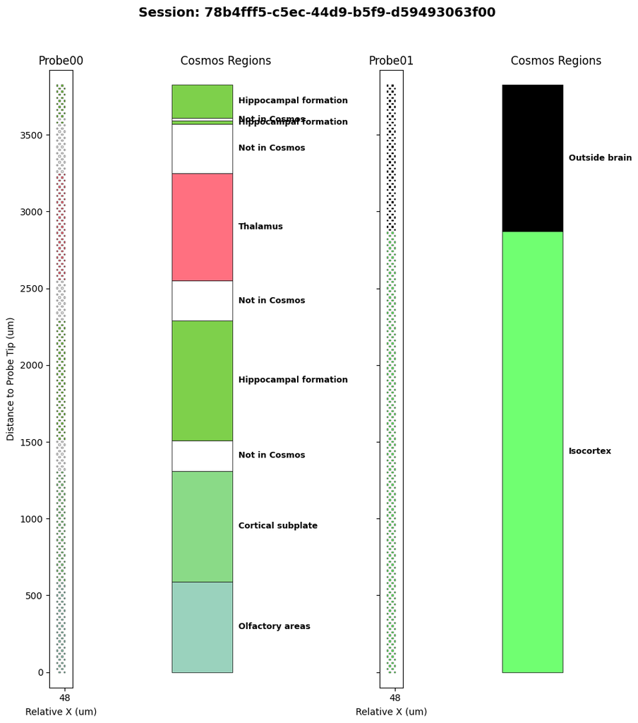

```python
import matplotlib.pyplot as plt

from iblatlas.regions import BrainRegions

COSMOS_FULL_NAMES = {
    "Isocortex": "Isocortex",
    "OLF": "Olfactory areas",
    "HPF": "Hippocampal formation",
    "CTXsp": "Cortical subplate",
    "CNU": "Cerebral nuclei",
    "TH": "Thalamus",
    "HY": "Hypothalamus",
    "MB": "Midbrain",
    "HB": "Hindbrain",
    "CB": "Cerebellum",
    "root": "Not in Cosmos",
    "void": "Outside brain",
}


def get_cosmos_color(cosmos_acronym, brain_regions=None):
    if brain_regions is None:
        brain_regions = BrainRegions()
    try:
        index = brain_regions.acronym2index(cosmos_acronym)[1][0]
        if hasattr(index, "__len__"):
            index = index[0]
        rgb = brain_regions.rgb[index]
        return (rgb[0] / 255, rgb[1] / 255, rgb[2] / 255)
    except (IndexError, KeyError):
        return (0.5, 0.5, 0.5)

nwbfile = nwbfile_raw

# %% Get anatomical localization table
anatomical_tables = localization.anatomical_coordinates_tables
ibl_bregma_table_df = anatomical_tables["ElectrodesIBLBregma"].to_dataframe()

# %% Get all unique probe names
probe_names = sorted(ibl_bregma_table_df["probe_name"].unique())
n_probes = len(probe_names)

print(f"Found {n_probes} probe(s): {probe_names}")

# %% Create figure - 2 columns per probe (contacts + regions), side by side
fig, axes = plt.subplots(1, n_probes * 2, figsize=(5 * n_probes, 12), sharey=True)

# Handle single probe case (axes won't be a list)
if n_probes == 1:
    axes = [axes[0], axes[1]]

# Track all unique regions across all probes for the legend
all_unique_regions = []

# %% Plot each probe
for probe_index, probe_name in enumerate(probe_names):
    # Get axes for this probe
    ax_probe = axes[probe_index * 2]
    ax_regions = axes[probe_index * 2 + 1]

    # Filter data for this probe
    probe_table = ibl_bregma_table_df[ibl_bregma_table_df["probe_name"] == probe_name].copy()

    # Extract electrode positions from localized_entity
    probe_table["rel_x"] = [electrode["rel_x"].iloc[0] for electrode in probe_table["localized_entity"]]
    probe_table["rel_y"] = [electrode["rel_y"].iloc[0] for electrode in probe_table["localized_entity"]]

    # Sort by depth (rel_y)
    probe_table = probe_table.sort_values("rel_y").reset_index(drop=True)

    # Precompute colors
    cosmos_values = probe_table["cosmos_location"].values
    rel_x_values = probe_table["rel_x"].values
    rel_y_values = probe_table["rel_y"].values
    colors = [get_cosmos_color(c) for c in cosmos_values]

    # Track unique regions for legend
    for region in cosmos_values:
        if region not in all_unique_regions:
            all_unique_regions.append(region)

    # --- Left panel: Probe contacts ---
    contact_width = 12  # um
    contact_height = 10  # um

    for i in range(len(rel_x_values)):
        rect = plt.Rectangle(
            (rel_x_values[i] - contact_width / 2, rel_y_values[i] - contact_height / 2),
            contact_width,
            contact_height,
            facecolor=colors[i],
            edgecolor="black",
            linewidth=0.3,
        )
        ax_probe.add_patch(rect)

    # Set probe axis limits
    x_min, x_max = probe_table["rel_x"].min(), probe_table["rel_x"].max()
    y_min, y_max = probe_table["rel_y"].min(), probe_table["rel_y"].max()
    x_margin, y_margin = 50, 100

    ax_probe.set_xlim(x_min - x_margin, x_max + x_margin)
    ax_probe.set_ylim(y_min - y_margin, y_max + y_margin)

    # Simplify x-axis: single tick at max value
    ax_probe.set_xticks([x_max])
    ax_probe.set_xticklabels([f"{x_max:.0f}"])
    ax_probe.set_xlabel("Relative X (um)")

    if probe_index == 0:
        ax_probe.set_ylabel("Distance to Probe Tip (um)")
    ax_probe.set_title(f"{probe_name}")
    ax_probe.set_aspect("equal", adjustable="box")

    # --- Right panel: Region blocks ---
    blocks = []
    current_region = cosmos_values[0]
    block_start = rel_y_values[0]

    for i in range(1, len(cosmos_values)):
        if cosmos_values[i] != current_region:
            block_end = (rel_y_values[i - 1] + rel_y_values[i]) / 2
            blocks.append((current_region, block_start, block_end))
            current_region = cosmos_values[i]
            block_start = block_end

    # Add final block
    blocks.append((current_region, block_start, rel_y_values[-1] + contact_height / 2))

    # Plot region blocks
    block_width = 1.0
    for region, y_start, y_end in blocks:
        color = get_cosmos_color(region)
        height = y_end - y_start

        rect = plt.Rectangle(
            (0, y_start),
            block_width,
            height,
            facecolor=color,
            edgecolor="black",
            linewidth=0.5,
        )
        ax_regions.add_patch(rect)

        # Add label in the middle of the block
        y_center = (y_start + y_end) / 2
        display_name = COSMOS_FULL_NAMES.get(region, region)
        ax_regions.text(block_width + 0.1, y_center, display_name, va="center", ha="left", fontsize=9, fontweight="bold")

    ax_regions.set_xlim(-0.2, 2.0)
    ax_regions.set_ylim(y_min - y_margin, y_max + y_margin)
    ax_regions.set_xticks([])
    ax_regions.set_title("Cosmos Regions")
    ax_regions.axis("off")

# %% Add legend and title
legend_handles = [
    plt.Rectangle((0, 0), 1, 1, facecolor=get_cosmos_color(r), edgecolor="black", linewidth=0.5)
    for r in all_unique_regions
]
legend_labels = [COSMOS_FULL_NAMES.get(r, r) for r in all_unique_regions]


plt.suptitle(f"Session: {nwbfile.session_id}", fontsize=14, fontweight="bold")
plt.tight_layout(rect=[0, 0.08, 1, 0.96])

plt.show()
```

## Anatomical Location of Probes in the CCFv3 space

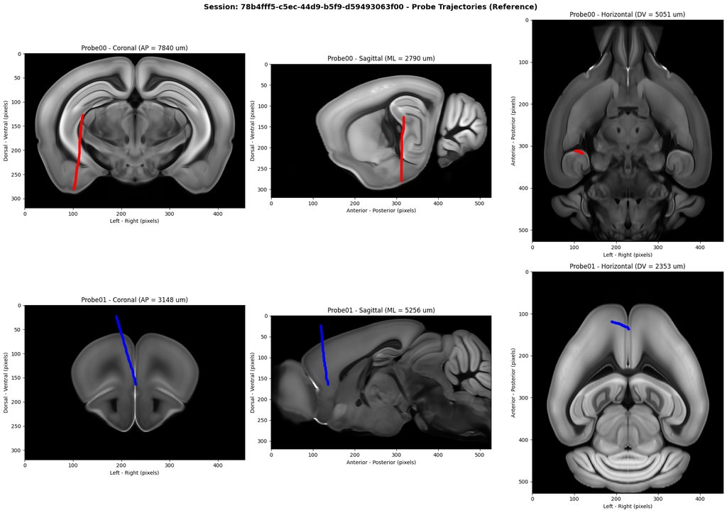

```python
# Workaround: brainglobe-atlasapi 2.3.1 fetches its atlas-version manifest
# from a Colab-unfriendly S3 endpoint that returns 403 for some Colab IPs.
# Pre-seed the cache so BrainGlobeAtlas() below can find a version manifest
# even when the live fetch fails. See https://github.com/brainglobe/brainglobe-atlasapi/issues/738
from pathlib import Path
import urllib.request

_bg_dir = Path.home() / ".brainglobe"
_manifest_url = (
    "https://brainglobe.s3.us-west-2.amazonaws.com/atlas/atlases/last_versions.conf"
)
try:
    _manifest = urllib.request.urlopen(_manifest_url, timeout=20).read().decode()
except Exception as _e:  # noqa: BLE001
    print(f"Couldn't reach brainglobe manifest ({_e}); writing a minimal fallback.")
    _manifest = "[atlases]\nallen_mouse_25um = 3.0\n"

# Write to both the V1 and V2 cache paths so whichever brainglobe-atlasapi
# code path reads from disk finds the file.
for _p in (_bg_dir / "last_versions.conf",
           _bg_dir / "brainglobe-atlasapi" / "atlases" / "last_versions.conf"):
    _p.parent.mkdir(parents=True, exist_ok=True)
    if not _p.exists():
        _p.write_text(_manifest)

import matplotlib.pyplot as plt
import numpy as np
from brainglobe_atlasapi import BrainGlobeAtlas

# %% Get CCFv3 coordinates for all probes
anatomical_tables = localization.anatomical_coordinates_tables
ccf_table_df = anatomical_tables["ElectrodesCCFv3"].to_dataframe()

# Get all unique probe names
probe_names = sorted(ccf_table_df["probe_name"].unique())
n_probes = len(probe_names)

# Define colors for each probe
probe_colors = ["red", "blue", "green", "orange", "purple"][:n_probes]

# %% Load atlas
atlas = BrainGlobeAtlas("allen_mouse_25um")

# %% Collect probe data - compute slice positions per probe (mean coordinate approach)
# See documentation/probe_slice_visualization_guide.md for heuristics
probe_data = {}

for probe_name in probe_names:
    probe_table = ccf_table_df[ccf_table_df["probe_name"] == probe_name].copy()
    bg_x = probe_table["x"].values  # Anterior (0) to Posterior (13200)
    bg_y = probe_table["y"].values  # Dorsal (0) to Ventral (8000)
    bg_z = probe_table["z"].values  # Left (0) to Right (11400)

    # Calculate slice positions for this specific probe (mean coordinate)
    coronal_position = int(np.mean(bg_x))
    sagittal_position = int(np.mean(bg_z))
    horizontal_position = int(np.mean(bg_y))

    # Convert to slice indices
    coronal_index = int(coronal_position / atlas.resolution[0])
    sagittal_index = int(sagittal_position / atlas.resolution[2])
    horizontal_index = int(horizontal_position / atlas.resolution[1])

    probe_data[probe_name] = {
        "x_px": bg_x / atlas.resolution[0],
        "y_px": bg_y / atlas.resolution[1],
        "z_px": bg_z / atlas.resolution[2],
        "coronal_position": coronal_position,
        "sagittal_position": sagittal_position,
        "horizontal_position": horizontal_position,
        "coronal_index": coronal_index,
        "sagittal_index": sagittal_index,
        "horizontal_index": horizontal_index,
    }

# %% Create Figure: Grid with n_probes rows x 3 columns (one row per probe)
fig, axes = plt.subplots(n_probes, 3, figsize=(20, 7 * n_probes))

# Handle single probe case (axes won't be 2D)
if n_probes == 1:
    axes = axes.reshape(1, -1)

for row, probe_name in enumerate(probe_names):
    data = probe_data[probe_name]
    color = probe_colors[row]

    # Get slices centered on this probe's location
    reference_coronal = atlas.reference[data["coronal_index"], :, :]
    reference_sagittal = atlas.reference[:, :, data["sagittal_index"]]
    reference_horizontal = atlas.reference[:, data["horizontal_index"], :]

    # Coronal view
    ax = axes[row, 0]
    ax.imshow(reference_coronal, cmap="gray", aspect="equal")
    ax.scatter(data["z_px"], data["y_px"], c=color, s=10, alpha=0.8)
    ax.set_xlabel("Left - Right (pixels)")
    ax.set_ylabel("Dorsal - Ventral (pixels)")
    ax.set_title(f"{probe_name} - Coronal (AP = {data['coronal_position']} um)")

    # Sagittal view (transposed for correct orientation)
    ax = axes[row, 1]
    ax.imshow(reference_sagittal.T, cmap="gray", aspect="equal")
    ax.scatter(data["x_px"], data["y_px"], c=color, s=10, alpha=0.8)
    ax.set_xlabel("Anterior - Posterior (pixels)")
    ax.set_ylabel("Dorsal - Ventral (pixels)")
    ax.set_title(f"{probe_name} - Sagittal (ML = {data['sagittal_position']} um)")

    # Horizontal view
    ax = axes[row, 2]
    ax.imshow(reference_horizontal, cmap="gray", aspect="equal")
    ax.scatter(data["z_px"], data["x_px"], c=color, s=10, alpha=0.8)
    ax.set_xlabel("Left - Right (pixels)")
    ax.set_ylabel("Anterior - Posterior (pixels)")
    ax.set_title(f"{probe_name} - Horizontal (DV = {data['horizontal_position']} um)")

fig.suptitle(f"Session: {nwbfile_raw.session_id} - Probe Trajectories (Reference)", fontsize=14, fontweight="bold")
plt.tight_layout()
plt.show()
```

Both the electrode and the anatomical coordinates tables are present both nwbfiles (the one with the raw data and the one with the processed data) and are identical in both files.

## Accessing Video Data

```python
from pathlib import Path

from pynwb.image import ImageSeries

# Videos in NWB are stored as ImageSeries with external_file containing relative paths
# We resolve them to full DANDI asset paths and get S3 URLs for streaming

nwb_parent = Path(raw_asset.path).parent
video_s3_urls = {}

for name, obj in nwbfile_raw.acquisition.items():
    # Check for ImageSeries with external_file (videos stored externally)
    if isinstance(obj, ImageSeries) and obj.external_file is not None:
        # Get the relative path and resolve to full DANDI path
        relative_path = obj.external_file[0].lstrip("./")
        full_path = str(nwb_parent / relative_path)

        # Fetch the video asset and get its S3 URL
        video_asset = dandiset.get_asset_by_path(full_path)
        if video_asset is not None:
            video_s3_urls[name] = video_asset.get_content_url(
                follow_redirects=1, strip_query=True
            )

video_s3_urls
```

```
{'VideoBodyCamera': 'https://dandiarchive.s3.amazonaws.com/blobs/710/ab6/710ab6a6-0092-463d-80d7-c7c19966a380',
 'VideoLeftCamera': 'https://dandiarchive.s3.amazonaws.com/blobs/8bd/94f/8bd94ffa-07c3-4889-9ee8-adf26f1761b2',
 'VideoRightCamera': 'https://dandiarchive.s3.amazonaws.com/blobs/c9f/c05/c9fc050a-a7f0-4d97-bd87-a076eb483e8a'}
```

```python
# Stream a video directly in the notebook using IPython HTML display
# This works but might have limitations in some notebook environments
from IPython.display import HTML

camera_to_display = "VideoLeftCamera"

if camera_to_display in video_s3_urls:
    video_url = video_s3_urls[camera_to_display]
    display(HTML(f"""
    <video width="640" height="480" controls>
        <source src="{video_url}" type="video/mp4">
        Your browser does not support the video tag.
    </video>
    <p><b>{camera_to_display}</b></p>
    """))
else:
    print(f"{camera_to_display} not available for this session")
```

[video not shown]

**VideoLeftCamera**

While IPython's HTML display works for basic video playback, anywidget provides a more robust, cross-platform solution. The package nwb-video-widgets offers a suite of widgets specifically designed for NWB video data that synchronize playback with timestamps and support multiple video streams. Here's how to use it:

```python
from nwb_video_widgets import NWBDANDIVideoPlayer

video_grid=[["VideoLeftCamera", "VideoBodyCamera", "VideoRightCamera"]]
NWBDANDIVideoPlayer(asset=raw_asset, nwbfile=nwbfile_raw, video_grid = video_grid)
```

# Processed files

The processed file contains the processed data including the spike sorting results, the trials information, the pose estimation results, the wheel position, lick times and other behavioral data.

```python
s3_url = processed_asset.get_content_url(follow_redirects=1, strip_query=False)
file_system = remfile.File(s3_url)
file = h5py.File(file_system, mode="r")

io = NWBHDF5IO(file=file)
nwbfile_processed = io.read()
```

```python
nwbfile_processed
```

root (NWBFile)

session_description:

identifier: e9740564-a40c-4761-a3e9-efb83394a9ca

**session_start_time**

2022-07-04 14:30:15.049000+01:00

**timestamps_reference_time**

2022-07-04 14:30:15.049000+01:00

**file_create_date**

**0**

2026-03-03 09:32:05.447286+00:00

**processing**

**lick_times (ProcessingModule)**

description: Lick event timestamps detected from video-based tongue pose estimation. Licks are detected by tracking tongue landmark positions (Lightning Pose) and identifying frames with significant tongue movement. Licking indicates consummatory behavior following water reward delivery.

**EventsLickTimes (Events)**

description: Lick event timestamps detected from tongue pose estimation (Lightning Pose). Detection algorithm: frame-to-frame position changes in tongue landmarks (tongue_end_l_x, tongue_end_l_y, tongue_end_r_x, tongue_end_r_y) are computed, and frames where any coordinate changes by more than std(diff)/4 are marked as lick events. If left and right camera data exist, the licks detected from both cameras are combined.

**timestamps**

HDF5 dataset

| Data type | float64 |
| --- | --- |
| Shape | (40348,) |
| Array size | 315.22 KiB |
| Chunk shape | (40348,) |
| Compression | gzip |
| Compression opts | 4 |
| Uncompressed size (bytes) | 322784 |
| Compressed size (bytes) | 240819 |
| Compression ratio | 1.340359357027477 |

timestamps__unit: seconds

**motion_energy (ProcessingModule)**

description: Motion energy quantifies total movement within video regions of interest (ROIs). Values are computed as the sum of Euclidean pixel intensity differences between frames, normalized to [0, 1] range. Useful as a behavioral covariate for neural analysis.

**LeftCameraMotionEnergy (TimeSeries)**

resolution: -1.0

comments: no comments

description: Motion energy calculated for a region of the left camera video. ROI dimensions: 168 pixels wide, 112 pixels tall, top-left corner at (249, 191). Calculation: For each frame, pixel intensity differences are computed between frame N and frame N+2 (default offset). The Euclidean norm (L2) of differences is summed across all ROI pixels, then min-max normalized to [0, 1] range. Higher values indicate more movement within the ROI. CAUTION: Video loading libraries may use different axis conventions. When loading with cv2 in Python, x and y axes are flipped. The region then becomes [191:303, 249:417].

conversion: 1.0

offset: 0.0

unit: a.u.

**data**

HDF5 dataset

| Data type | float64 |
| --- | --- |
| Shape | (321951,) |
| Array size | 2.46 MiB |
| Chunk shape | (321951,) |
| Compression | gzip |
| Compression opts | 4 |
| Uncompressed size (bytes) | 2575608 |
| Compressed size (bytes) | 1344276 |
| Compression ratio | 1.9159815395052802 |

**timestamps**

HDF5 dataset

| Data type | float64 |
| --- | --- |
| Shape | (321951,) |
| Array size | 2.46 MiB |
| Chunk shape | (321951,) |
| Compression | gzip |
| Compression opts | 4 |
| Uncompressed size (bytes) | 2575608 |
| Compressed size (bytes) | 1898451 |
| Compression ratio | 1.3566892166297682 |

timestamps_unit: seconds

interval: 1

**RightCameraMotionEnergy (TimeSeries)**

resolution: -1.0

comments: no comments

description: Motion energy calculated for a region of the right camera video. ROI dimensions: 85 pixels wide, 57 pixels tall, top-left corner at (446, 81). Calculation: For each frame, pixel intensity differences are computed between frame N and frame N+2 (default offset). The Euclidean norm (L2) of differences is summed across all ROI pixels, then min-max normalized to [0, 1] range. Higher values indicate more movement within the ROI. CAUTION: Video loading libraries may use different axis conventions. When loading with cv2 in Python, x and y axes are flipped. The region then becomes [81:138, 446:531].

conversion: 1.0

offset: 0.0

unit: a.u.

**data**

HDF5 dataset

| Data type | float64 |
| --- | --- |
| Shape | (806112,) |
| Array size | 6.15 MiB |
| Chunk shape | (806112,) |
| Compression | gzip |
| Compression opts | 4 |
| Uncompressed size (bytes) | 6448896 |
| Compressed size (bytes) | 3307964 |
| Compression ratio | 1.9495061010337476 |

**timestamps**

HDF5 dataset

| Data type | float64 |
| --- | --- |
| Shape | (806112,) |
| Array size | 6.15 MiB |
| Chunk shape | (806112,) |
| Compression | gzip |
| Compression opts | 4 |
| Uncompressed size (bytes) | 6448896 |
| Compressed size (bytes) | 4691942 |
| Compression ratio | 1.3744620031534918 |

timestamps_unit: seconds

interval: 1

**passive_protocol (ProcessingModule)**

description: Data from the IBL passive stimulus protocol, presented at the end of each recording session while the mouse is disengaged from the task. The protocol consists of three phases: (1) spontaneous activity with no stimuli, (2) receptive field mapping (RFM) using sparse noise visual stimuli, and (3) task replay presenting the same Gabor patches and auditory stimuli (valve, tone, noise) used during the active behavioral task. Data revision: 2025-12-04.

**gabor_table (TimeIntervals)**

description: Gabor patch presentations table. Data revision: 2025-12-04.

**columns**

**start_time**

The beginning of the stimulus.

**stop_time**

The end of the stimulus.

**position**

gabor patch position

**contrast**

gabor patch contrast

**phase**

gabor patch phase

**table**

| id | start_time | stop_time | position | contrast | phase |
| --- | --- | --- | --- | --- | --- |
| 0 | 5126.874515 | 5127.185221 | -35.0 | 0.0625 | 3.124994 |
| 1 | 5129.124614 | 5129.435687 | -35.0 | 1.0000 | 2.162905 |
| 2 | 5131.441141 | 5131.768878 | 35.0 | 1.0000 | 2.200607 |
| 3 | 5134.424608 | 5134.735413 | 35.0 | 0.0625 | 1.741850 |

... and 175 more row(s).

**passive_intervals (TimeIntervals)**

description: Detailed timing of passive protocol phases (spontaneous activity, RFM, task replay). Data revision: 2025-12-04.

**columns**

**start_time**

Start time of epoch, in seconds

**stop_time**

Stop time of epoch, in seconds

**protocol_name**

Name of the specific passive protocol phase

**table**

| id | start_time | stop_time | protocol_name |
| --- | --- | --- | --- |
| 0 | 4185.545797 | 4785.626265 | spontaneousActivity |
| 1 | 5111.224793 | 5478.753002 | taskReplay |

**passive_task_replay (TimeIntervals)**

description: Passive stimulation events including valve, tone, and noise stimuli. Data revision: 2025-12-04.

**columns**

**start_time**

Start time of epoch, in seconds

**stop_time**

Stop time of epoch, in seconds

**stim_type**

Type of stimulation (valve, tone, or noise)

**table**

| id | start_time | stop_time | stim_type |
| --- | --- | --- | --- |
| 0 | 5125.087475 | 5125.587463 | noise |
| 1 | 5127.316809 | 5127.416800 | tone |
| 2 | 5130.037133 | 5130.137124 | tone |
| 3 | 5130.516457 | 5130.583451 | valve |

... and 116 more row(s).

**pose_estimation (ProcessingModule)**

description: Pose estimation from video using Lightning Pose.

**LeftCamera (PoseEstimation)**

**PoseEstimationSeriesLeftPaw (PoseEstimationSeries)**

resolution: -1.0

comments: no comments

description: Marker placed on or around, labeled 'PoseEstimationSeriesLeftPaw'.

conversion: 1.0

offset: 0.0

unit: px

**data**

HDF5 dataset

| Data type | float64 |
| --- | --- |
| Shape | (321951, 2) |
| Array size | 4.91 MiB |
| Chunk shape | (321950, 2) |
| Compression | gzip |
| Compression opts | 4 |
| Uncompressed size (bytes) | 5151216 |
| Compressed size (bytes) | 2260409 |
| Compression ratio | 2.278886697053498 |

**timestamps (link to processing/pose_estimation/LeftCamera/PoseEstimationSeriesNoseTip/timestamps)**

HDF5 dataset

| Data type | float64 |
| --- | --- |
| Shape | (321951,) |
| Array size | 2.46 MiB |
| Chunk shape | (321951,) |
| Compression | gzip |
| Compression opts | 4 |
| Uncompressed size (bytes) | 2575608 |
| Compressed size (bytes) | 1898451 |
| Compression ratio | 1.3566892166297682 |

timestamps_unit: seconds

interval: 1

reference_frame: (0,0) corresponds to the upper left corner when using width by height convention.

**confidence**

HDF5 dataset

| Data type | float64 |
| --- | --- |
| Shape | (321951,) |
| Array size | 2.46 MiB |
| Chunk shape | (2516,) |
| Compression | None |
| Compression opts | None |
| Uncompressed size (bytes) | 2575608 |
| Compressed size (bytes) | 2576384 |
| Compression ratio | 0.9996988026629571 |

**PoseEstimationSeriesLeftTongueEnd (PoseEstimationSeries)**

resolution: -1.0

comments: no comments

description: Marker placed on or around, labeled 'PoseEstimationSeriesLeftTongueEnd'.

conversion: 1.0

offset: 0.0

unit: px

**data**

HDF5 dataset

| Data type | float64 |
| --- | --- |
| Shape | (321951, 2) |
| Array size | 4.91 MiB |
| Chunk shape | (321950, 2) |
| Compression | gzip |
| Compression opts | 4 |
| Uncompressed size (bytes) | 5151216 |
| Compressed size (bytes) | 223870 |
| Compression ratio | 23.009853933086166 |

**timestamps (link to processing/pose_estimation/LeftCamera/PoseEstimationSeriesNoseTip/timestamps)**

HDF5 dataset

| Data type | float64 |
| --- | --- |
| Shape | (321951,) |
| Array size | 2.46 MiB |
| Chunk shape | (321951,) |
| Compression | gzip |
| Compression opts | 4 |
| Uncompressed size (bytes) | 2575608 |
| Compressed size (bytes) | 1898451 |
| Compression ratio | 1.3566892166297682 |

timestamps_unit: seconds

interval: 1

reference_frame: (0,0) corresponds to the upper left corner when using width by height convention.

**confidence**

HDF5 dataset

| Data type | float64 |
| --- | --- |
| Shape | (321951,) |
| Array size | 2.46 MiB |
| Chunk shape | (2516,) |
| Compression | None |
| Compression opts | None |
| Uncompressed size (bytes) | 2575608 |
| Compressed size (bytes) | 2576384 |
| Compression ratio | 0.9996988026629571 |

**PoseEstimationSeriesNoseTip (PoseEstimationSeries)**

resolution: -1.0

comments: no comments

description: Marker placed on or around, labeled 'PoseEstimationSeriesNoseTip'.

conversion: 1.0

offset: 0.0

unit: px

**data**

HDF5 dataset

| Data type | float64 |
| --- | --- |
| Shape | (321951, 2) |
| Array size | 4.91 MiB |
| Chunk shape | (321950, 2) |
| Compression | gzip |
| Compression opts | 4 |
| Uncompressed size (bytes) | 5151216 |
| Compressed size (bytes) | 2528216 |
| Compression ratio | 2.0374904675866303 |

**timestamps**

HDF5 dataset

| Data type | float64 |
| --- | --- |
| Shape | (321951,) |
| Array size | 2.46 MiB |
| Chunk shape | (321951,) |
| Compression | gzip |
| Compression opts | 4 |
| Uncompressed size (bytes) | 2575608 |
| Compressed size (bytes) | 1898451 |
| Compression ratio | 1.3566892166297682 |

timestamps_unit: seconds

interval: 1

reference_frame: (0,0) corresponds to the upper left corner when using width by height convention.

**confidence**

HDF5 dataset

| Data type | float64 |
| --- | --- |
| Shape | (321951,) |
| Array size | 2.46 MiB |
| Chunk shape | (2516,) |
| Compression | None |
| Compression opts | None |
| Uncompressed size (bytes) | 2575608 |
| Compressed size (bytes) | 2576384 |
| Compression ratio | 0.9996988026629571 |

**timestamp_link**

**0 (PoseEstimationSeries)**

resolution: -1.0

comments: no comments

description: Marker placed on or around, labeled 'PoseEstimationSeriesLeftPaw'.

conversion: 1.0

offset: 0.0

unit: px

**data**

HDF5 dataset

| Data type | float64 |
| --- | --- |
| Shape | (321951, 2) |
| Array size | 4.91 MiB |
| Chunk shape | (321950, 2) |
| Compression | gzip |
| Compression opts | 4 |
| Uncompressed size (bytes) | 5151216 |
| Compressed size (bytes) | 2260409 |
| Compression ratio | 2.278886697053498 |

**timestamps (link to processing/pose_estimation/LeftCamera/PoseEstimationSeriesNoseTip/timestamps)**

HDF5 dataset

| Data type | float64 |
| --- | --- |
| Shape | (321951,) |
| Array size | 2.46 MiB |
| Chunk shape | (321951,) |
| Compression | gzip |
| Compression opts | 4 |
| Uncompressed size (bytes) | 2575608 |
| Compressed size (bytes) | 1898451 |
| Compression ratio | 1.3566892166297682 |

timestamps_unit: seconds

interval: 1

reference_frame: (0,0) corresponds to the upper left corner when using width by height convention.

**confidence**

HDF5 dataset

| Data type | float64 |
| --- | --- |
| Shape | (321951,) |
| Array size | 2.46 MiB |
| Chunk shape | (2516,) |
| Compression | None |
| Compression opts | None |
| Uncompressed size (bytes) | 2575608 |
| Compressed size (bytes) | 2576384 |
| Compression ratio | 0.9996988026629571 |

**1 (PoseEstimationSeries)**

resolution: -1.0

comments: no comments

description: Marker placed on or around, labeled 'PoseEstimationSeriesLeftTongueEnd'.

conversion: 1.0

offset: 0.0

unit: px

**data**

HDF5 dataset

| Data type | float64 |
| --- | --- |
| Shape | (321951, 2) |
| Array size | 4.91 MiB |
| Chunk shape | (321950, 2) |
| Compression | gzip |
| Compression opts | 4 |
| Uncompressed size (bytes) | 5151216 |
| Compressed size (bytes) | 223870 |
| Compression ratio | 23.009853933086166 |

**timestamps (link to processing/pose_estimation/LeftCamera/PoseEstimationSeriesNoseTip/timestamps)**

HDF5 dataset

| Data type | float64 |
| --- | --- |
| Shape | (321951,) |
| Array size | 2.46 MiB |
| Chunk shape | (321951,) |
| Compression | gzip |
| Compression opts | 4 |
| Uncompressed size (bytes) | 2575608 |
| Compressed size (bytes) | 1898451 |
| Compression ratio | 1.3566892166297682 |

timestamps_unit: seconds

interval: 1

reference_frame: (0,0) corresponds to the upper left corner when using width by height convention.

**confidence**

HDF5 dataset

| Data type | float64 |
| --- | --- |
| Shape | (321951,) |
| Array size | 2.46 MiB |
| Chunk shape | (2516,) |
| Compression | None |
| Compression opts | None |
| Uncompressed size (bytes) | 2575608 |
| Compressed size (bytes) | 2576384 |
| Compression ratio | 0.9996988026629571 |

**2 (PoseEstimationSeries)**

resolution: -1.0

comments: no comments

description: Marker placed on or around, labeled 'PoseEstimationSeriesRightPaw'.

conversion: 1.0

offset: 0.0

unit: px

**data**

HDF5 dataset

| Data type | float64 |
| --- | --- |
| Shape | (321951, 2) |
| Array size | 4.91 MiB |
| Chunk shape | (321950, 2) |
| Compression | gzip |
| Compression opts | 4 |
| Uncompressed size (bytes) | 5151216 |
| Compressed size (bytes) | 2161629 |
| Compression ratio | 2.3830250241831505 |

**timestamps (link to processing/pose_estimation/LeftCamera/PoseEstimationSeriesNoseTip/timestamps)**

HDF5 dataset

| Data type | float64 |
| --- | --- |
| Shape | (321951,) |
| Array size | 2.46 MiB |
| Chunk shape | (321951,) |
| Compression | gzip |
| Compression opts | 4 |
| Uncompressed size (bytes) | 2575608 |
| Compressed size (bytes) | 1898451 |
| Compression ratio | 1.3566892166297682 |

timestamps_unit: seconds

interval: 1

reference_frame: (0,0) corresponds to the upper left corner when using width by height convention.

**confidence**

HDF5 dataset

| Data type | float64 |
| --- | --- |
| Shape | (321951,) |
| Array size | 2.46 MiB |
| Chunk shape | (2516,) |
| Compression | None |
| Compression opts | None |
| Uncompressed size (bytes) | 2575608 |
| Compressed size (bytes) | 2576384 |
| Compression ratio | 0.9996988026629571 |

**3 (PoseEstimationSeries)**

resolution: -1.0

comments: no comments

description: Marker placed on or around, labeled 'PoseEstimationSeriesRightPupilBottom'.

conversion: 1.0

offset: 0.0

unit: px

**data**

HDF5 dataset

| Data type | float64 |
| --- | --- |
| Shape | (321951, 2) |
| Array size | 4.91 MiB |
| Chunk shape | (321950, 2) |
| Compression | gzip |
| Compression opts | 4 |
| Uncompressed size (bytes) | 5151216 |
| Compressed size (bytes) | 4381698 |
| Compression ratio | 1.1756209579026213 |

**timestamps (link to processing/pose_estimation/LeftCamera/PoseEstimationSeriesNoseTip/timestamps)**

HDF5 dataset

| Data type | float64 |
| --- | --- |
| Shape | (321951,) |
| Array size | 2.46 MiB |
| Chunk shape | (321951,) |
| Compression | gzip |
| Compression opts | 4 |
| Uncompressed size (bytes) | 2575608 |
| Compressed size (bytes) | 1898451 |
| Compression ratio | 1.3566892166297682 |

timestamps_unit: seconds

interval: 1

reference_frame: (0,0) corresponds to the upper left corner when using width by height convention.

**confidence**

HDF5 dataset

| Data type | float64 |
| --- | --- |
| Shape | (321951,) |
| Array size | 2.46 MiB |
| Chunk shape | (2516,) |
| Compression | None |
| Compression opts | None |
| Uncompressed size (bytes) | 2575608 |
| Compressed size (bytes) | 2576384 |
| Compression ratio | 0.9996988026629571 |

**4 (PoseEstimationSeries)**

resolution: -1.0

comments: no comments

description: Marker placed on or around, labeled 'PoseEstimationSeriesRightPupilLeft'.

conversion: 1.0

offset: 0.0

unit: px

**data**

HDF5 dataset

| Data type | float64 |
| --- | --- |
| Shape | (321951, 2) |
| Array size | 4.91 MiB |
| Chunk shape | (321950, 2) |
| Compression | gzip |
| Compression opts | 4 |
| Uncompressed size (bytes) | 5151216 |
| Compressed size (bytes) | 4380152 |
| Compression ratio | 1.176035900124014 |

**timestamps (link to processing/pose_estimation/LeftCamera/PoseEstimationSeriesNoseTip/timestamps)**

HDF5 dataset

| Data type | float64 |
| --- | --- |
| Shape | (321951,) |
| Array size | 2.46 MiB |
| Chunk shape | (321951,) |
| Compression | gzip |
| Compression opts | 4 |
| Uncompressed size (bytes) | 2575608 |
| Compressed size (bytes) | 1898451 |
| Compression ratio | 1.3566892166297682 |

timestamps_unit: seconds

interval: 1

reference_frame: (0,0) corresponds to the upper left corner when using width by height convention.

**confidence**

HDF5 dataset

| Data type | float64 |
| --- | --- |
| Shape | (321951,) |
| Array size | 2.46 MiB |
| Chunk shape | (2516,) |
| Compression | None |
| Compression opts | None |
| Uncompressed size (bytes) | 2575608 |
| Compressed size (bytes) | 2576384 |
| Compression ratio | 0.9996988026629571 |

**5 (PoseEstimationSeries)**

resolution: -1.0

comments: no comments

description: Marker placed on or around, labeled 'PoseEstimationSeriesRightPupilRight'.

conversion: 1.0

offset: 0.0

unit: px

**data**

HDF5 dataset

| Data type | float64 |
| --- | --- |
| Shape | (321951, 2) |
| Array size | 4.91 MiB |
| Chunk shape | (321950, 2) |
| Compression | gzip |
| Compression opts | 4 |
| Uncompressed size (bytes) | 5151216 |
| Compressed size (bytes) | 4378088 |
| Compression ratio | 1.1765903289289754 |

**timestamps (link to processing/pose_estimation/LeftCamera/PoseEstimationSeriesNoseTip/timestamps)**

HDF5 dataset

| Data type | float64 |
| --- | --- |
| Shape | (321951,) |
| Array size | 2.46 MiB |
| Chunk shape | (321951,) |
| Compression | gzip |
| Compression opts | 4 |
| Uncompressed size (bytes) | 2575608 |
| Compressed size (bytes) | 1898451 |
| Compression ratio | 1.3566892166297682 |

timestamps_unit: seconds

interval: 1

reference_frame: (0,0) corresponds to the upper left corner when using width by height convention.

**confidence**

HDF5 dataset

| Data type | float64 |
| --- | --- |
| Shape | (321951,) |
| Array size | 2.46 MiB |
| Chunk shape | (2516,) |
| Compression | None |
| Compression opts | None |
| Uncompressed size (bytes) | 2575608 |
| Compressed size (bytes) | 2576384 |
| Compression ratio | 0.9996988026629571 |

**6 (PoseEstimationSeries)**

resolution: -1.0

comments: no comments

description: Marker placed on or around, labeled 'PoseEstimationSeriesRightPupilTop'.

conversion: 1.0

offset: 0.0

unit: px

**data**

HDF5 dataset

| Data type | float64 |
| --- | --- |
| Shape | (321951, 2) |
| Array size | 4.91 MiB |
| Chunk shape | (321950, 2) |
| Compression | gzip |
| Compression opts | 4 |
| Uncompressed size (bytes) | 5151216 |
| Compressed size (bytes) | 4433984 |
| Compression ratio | 1.161757913425037 |

**timestamps (link to processing/pose_estimation/LeftCamera/PoseEstimationSeriesNoseTip/timestamps)**

HDF5 dataset

| Data type | float64 |
| --- | --- |
| Shape | (321951,) |
| Array size | 2.46 MiB |
| Chunk shape | (321951,) |
| Compression | gzip |
| Compression opts | 4 |
| Uncompressed size (bytes) | 2575608 |
| Compressed size (bytes) | 1898451 |
| Compression ratio | 1.3566892166297682 |

timestamps_unit: seconds

interval: 1

reference_frame: (0,0) corresponds to the upper left corner when using width by height convention.

**confidence**

HDF5 dataset

| Data type | float64 |
| --- | --- |
| Shape | (321951,) |
| Array size | 2.46 MiB |
| Chunk shape | (2516,) |
| Compression | None |
| Compression opts | None |
| Uncompressed size (bytes) | 2575608 |
| Compressed size (bytes) | 2576384 |
| Compression ratio | 0.9996988026629571 |

**7 (PoseEstimationSeries)**

resolution: -1.0

comments: no comments

description: Marker placed on or around, labeled 'PoseEstimationSeriesRightTongueEnd'.

conversion: 1.0

offset: 0.0

unit: px

**data**

HDF5 dataset

| Data type | float64 |
| --- | --- |
| Shape | (321951, 2) |
| Array size | 4.91 MiB |
| Chunk shape | (321950, 2) |
| Compression | gzip |
| Compression opts | 4 |
| Uncompressed size (bytes) | 5151216 |
| Compressed size (bytes) | 226410 |
| Compression ratio | 22.751715913608056 |

**timestamps (link to processing/pose_estimation/LeftCamera/PoseEstimationSeriesNoseTip/timestamps)**

HDF5 dataset

| Data type | float64 |
| --- | --- |
| Shape | (321951,) |
| Array size | 2.46 MiB |
| Chunk shape | (321951,) |
| Compression | gzip |
| Compression opts | 4 |
| Uncompressed size (bytes) | 2575608 |
| Compressed size (bytes) | 1898451 |
| Compression ratio | 1.3566892166297682 |

timestamps_unit: seconds

interval: 1

reference_frame: (0,0) corresponds to the upper left corner when using width by height convention.

**confidence**

HDF5 dataset

| Data type | float64 |
| --- | --- |
| Shape | (321951,) |
| Array size | 2.46 MiB |
| Chunk shape | (2516,) |
| Compression | None |
| Compression opts | None |
| Uncompressed size (bytes) | 2575608 |
| Compressed size (bytes) | 2576384 |
| Compression ratio | 0.9996988026629571 |

**8 (PoseEstimationSeries)**

resolution: -1.0

comments: no comments

description: Marker placed on or around, labeled 'PoseEstimationSeriesTubeBottom'.

conversion: 1.0

offset: 0.0

unit: px

**data**

HDF5 dataset

| Data type | float64 |
| --- | --- |
| Shape | (321951, 2) |
| Array size | 4.91 MiB |
| Chunk shape | (321950, 2) |
| Compression | gzip |
| Compression opts | 4 |
| Uncompressed size (bytes) | 5151216 |
| Compressed size (bytes) | 2199970 |
| Compression ratio | 2.3414937476420135 |

**timestamps (link to processing/pose_estimation/LeftCamera/PoseEstimationSeriesNoseTip/timestamps)**

HDF5 dataset

| Data type | float64 |
| --- | --- |
| Shape | (321951,) |
| Array size | 2.46 MiB |
| Chunk shape | (321951,) |
| Compression | gzip |
| Compression opts | 4 |
| Uncompressed size (bytes) | 2575608 |
| Compressed size (bytes) | 1898451 |
| Compression ratio | 1.3566892166297682 |

timestamps_unit: seconds

interval: 1

reference_frame: (0,0) corresponds to the upper left corner when using width by height convention.

**confidence**

HDF5 dataset

| Data type | float64 |
| --- | --- |
| Shape | (321951,) |
| Array size | 2.46 MiB |
| Chunk shape | (2516,) |
| Compression | None |
| Compression opts | None |
| Uncompressed size (bytes) | 2575608 |
| Compressed size (bytes) | 2576384 |
| Compression ratio | 0.9996988026629571 |

**9 (PoseEstimationSeries)**

resolution: -1.0

comments: no comments

description: Marker placed on or around, labeled 'PoseEstimationSeriesTubeTop'.

conversion: 1.0

offset: 0.0

unit: px

**data**

HDF5 dataset

| Data type | float64 |
| --- | --- |
| Shape | (321951, 2) |
| Array size | 4.91 MiB |
| Chunk shape | (321950, 2) |
| Compression | gzip |
| Compression opts | 4 |
| Uncompressed size (bytes) | 5151216 |
| Compressed size (bytes) | 2239492 |
| Compression ratio | 2.3001716460697335 |

**timestamps (link to processing/pose_estimation/LeftCamera/PoseEstimationSeriesNoseTip/timestamps)**

HDF5 dataset

| Data type | float64 |
| --- | --- |
| Shape | (321951,) |
| Array size | 2.46 MiB |
| Chunk shape | (321951,) |
| Compression | gzip |
| Compression opts | 4 |
| Uncompressed size (bytes) | 2575608 |
| Compressed size (bytes) | 1898451 |
| Compression ratio | 1.3566892166297682 |

timestamps_unit: seconds

interval: 1

reference_frame: (0,0) corresponds to the upper left corner when using width by height convention.

**confidence**

HDF5 dataset

| Data type | float64 |
| --- | --- |
| Shape | (321951,) |
| Array size | 2.46 MiB |
| Chunk shape | (2516,) |
| Compression | None |
| Compression opts | None |
| Uncompressed size (bytes) | 2575608 |
| Compressed size (bytes) | 2576384 |
| Compression ratio | 0.9996988026629571 |

**PoseEstimationSeriesRightPaw (PoseEstimationSeries)**

resolution: -1.0

comments: no comments

description: Marker placed on or around, labeled 'PoseEstimationSeriesRightPaw'.

conversion: 1.0

offset: 0.0

unit: px

**data**

HDF5 dataset

| Data type | float64 |
| --- | --- |
| Shape | (321951, 2) |
| Array size | 4.91 MiB |
| Chunk shape | (321950, 2) |
| Compression | gzip |
| Compression opts | 4 |
| Uncompressed size (bytes) | 5151216 |
| Compressed size (bytes) | 2161629 |
| Compression ratio | 2.3830250241831505 |

**timestamps (link to processing/pose_estimation/LeftCamera/PoseEstimationSeriesNoseTip/timestamps)**

HDF5 dataset

| Data type | float64 |
| --- | --- |
| Shape | (321951,) |
| Array size | 2.46 MiB |
| Chunk shape | (321951,) |
| Compression | gzip |
| Compression opts | 4 |
| Uncompressed size (bytes) | 2575608 |
| Compressed size (bytes) | 1898451 |
| Compression ratio | 1.3566892166297682 |

timestamps_unit: seconds

interval: 1

reference_frame: (0,0) corresponds to the upper left corner when using width by height convention.

**confidence**

HDF5 dataset

| Data type | float64 |
| --- | --- |
| Shape | (321951,) |
| Array size | 2.46 MiB |
| Chunk shape | (2516,) |
| Compression | None |
| Compression opts | None |
| Uncompressed size (bytes) | 2575608 |
| Compressed size (bytes) | 2576384 |
| Compression ratio | 0.9996988026629571 |

**PoseEstimationSeriesRightPupilBottom (PoseEstimationSeries)**

resolution: -1.0

comments: no comments

description: Marker placed on or around, labeled 'PoseEstimationSeriesRightPupilBottom'.

conversion: 1.0

offset: 0.0

unit: px

**data**

HDF5 dataset

| Data type | float64 |
| --- | --- |
| Shape | (321951, 2) |
| Array size | 4.91 MiB |
| Chunk shape | (321950, 2) |
| Compression | gzip |
| Compression opts | 4 |
| Uncompressed size (bytes) | 5151216 |
| Compressed size (bytes) | 4381698 |
| Compression ratio | 1.1756209579026213 |

**timestamps (link to processing/pose_estimation/LeftCamera/PoseEstimationSeriesNoseTip/timestamps)**

HDF5 dataset

| Data type | float64 |
| --- | --- |
| Shape | (321951,) |
| Array size | 2.46 MiB |
| Chunk shape | (321951,) |
| Compression | gzip |
| Compression opts | 4 |
| Uncompressed size (bytes) | 2575608 |
| Compressed size (bytes) | 1898451 |
| Compression ratio | 1.3566892166297682 |

timestamps_unit: seconds

interval: 1

reference_frame: (0,0) corresponds to the upper left corner when using width by height convention.

**confidence**

HDF5 dataset

| Data type | float64 |
| --- | --- |
| Shape | (321951,) |
| Array size | 2.46 MiB |
| Chunk shape | (2516,) |
| Compression | None |
| Compression opts | None |
| Uncompressed size (bytes) | 2575608 |
| Compressed size (bytes) | 2576384 |
| Compression ratio | 0.9996988026629571 |

**PoseEstimationSeriesRightPupilLeft (PoseEstimationSeries)**

resolution: -1.0

comments: no comments

description: Marker placed on or around, labeled 'PoseEstimationSeriesRightPupilLeft'.

conversion: 1.0

offset: 0.0

unit: px

**data**

HDF5 dataset

| Data type | float64 |
| --- | --- |
| Shape | (321951, 2) |
| Array size | 4.91 MiB |
| Chunk shape | (321950, 2) |
| Compression | gzip |
| Compression opts | 4 |
| Uncompressed size (bytes) | 5151216 |
| Compressed size (bytes) | 4380152 |
| Compression ratio | 1.176035900124014 |

**timestamps (link to processing/pose_estimation/LeftCamera/PoseEstimationSeriesNoseTip/timestamps)**

HDF5 dataset

| Data type | float64 |
| --- | --- |
| Shape | (321951,) |
| Array size | 2.46 MiB |
| Chunk shape | (321951,) |
| Compression | gzip |
| Compression opts | 4 |
| Uncompressed size (bytes) | 2575608 |
| Compressed size (bytes) | 1898451 |
| Compression ratio | 1.3566892166297682 |

timestamps_unit: seconds

interval: 1

reference_frame: (0,0) corresponds to the upper left corner when using width by height convention.

**confidence**

HDF5 dataset

| Data type | float64 |
| --- | --- |
| Shape | (321951,) |
| Array size | 2.46 MiB |
| Chunk shape | (2516,) |
| Compression | None |
| Compression opts | None |
| Uncompressed size (bytes) | 2575608 |
| Compressed size (bytes) | 2576384 |
| Compression ratio | 0.9996988026629571 |

**PoseEstimationSeriesRightPupilRight (PoseEstimationSeries)**

resolution: -1.0

comments: no comments

description: Marker placed on or around, labeled 'PoseEstimationSeriesRightPupilRight'.

conversion: 1.0

offset: 0.0

unit: px

**data**

HDF5 dataset

| Data type | float64 |
| --- | --- |
| Shape | (321951, 2) |
| Array size | 4.91 MiB |
| Chunk shape | (321950, 2) |
| Compression | gzip |
| Compression opts | 4 |
| Uncompressed size (bytes) | 5151216 |
| Compressed size (bytes) | 4378088 |
| Compression ratio | 1.1765903289289754 |

**timestamps (link to processing/pose_estimation/LeftCamera/PoseEstimationSeriesNoseTip/timestamps)**

HDF5 dataset

| Data type | float64 |
| --- | --- |
| Shape | (321951,) |
| Array size | 2.46 MiB |
| Chunk shape | (321951,) |
| Compression | gzip |
| Compression opts | 4 |
| Uncompressed size (bytes) | 2575608 |
| Compressed size (bytes) | 1898451 |
| Compression ratio | 1.3566892166297682 |

timestamps_unit: seconds

interval: 1

reference_frame: (0,0) corresponds to the upper left corner when using width by height convention.

**confidence**

HDF5 dataset

| Data type | float64 |
| --- | --- |
| Shape | (321951,) |
| Array size | 2.46 MiB |
| Chunk shape | (2516,) |
| Compression | None |
| Compression opts | None |
| Uncompressed size (bytes) | 2575608 |
| Compressed size (bytes) | 2576384 |
| Compression ratio | 0.9996988026629571 |

**PoseEstimationSeriesRightPupilTop (PoseEstimationSeries)**

resolution: -1.0

comments: no comments

description: Marker placed on or around, labeled 'PoseEstimationSeriesRightPupilTop'.

conversion: 1.0

offset: 0.0

unit: px

**data**

HDF5 dataset

| Data type | float64 |
| --- | --- |
| Shape | (321951, 2) |
| Array size | 4.91 MiB |
| Chunk shape | (321950, 2) |
| Compression | gzip |
| Compression opts | 4 |
| Uncompressed size (bytes) | 5151216 |
| Compressed size (bytes) | 4433984 |
| Compression ratio | 1.161757913425037 |

**timestamps (link to processing/pose_estimation/LeftCamera/PoseEstimationSeriesNoseTip/timestamps)**

HDF5 dataset

| Data type | float64 |
| --- | --- |
| Shape | (321951,) |
| Array size | 2.46 MiB |
| Chunk shape | (321951,) |
| Compression | gzip |
| Compression opts | 4 |
| Uncompressed size (bytes) | 2575608 |
| Compressed size (bytes) | 1898451 |
| Compression ratio | 1.3566892166297682 |

timestamps_unit: seconds

interval: 1

reference_frame: (0,0) corresponds to the upper left corner when using width by height convention.

**confidence**

HDF5 dataset

| Data type | float64 |
| --- | --- |
| Shape | (321951,) |
| Array size | 2.46 MiB |
| Chunk shape | (2516,) |
| Compression | None |
| Compression opts | None |
| Uncompressed size (bytes) | 2575608 |
| Compressed size (bytes) | 2576384 |
| Compression ratio | 0.9996988026629571 |

**PoseEstimationSeriesRightTongueEnd (PoseEstimationSeries)**

resolution: -1.0

comments: no comments

description: Marker placed on or around, labeled 'PoseEstimationSeriesRightTongueEnd'.

conversion: 1.0

offset: 0.0

unit: px

**data**

HDF5 dataset

| Data type | float64 |
| --- | --- |
| Shape | (321951, 2) |
| Array size | 4.91 MiB |
| Chunk shape | (321950, 2) |
| Compression | gzip |
| Compression opts | 4 |
| Uncompressed size (bytes) | 5151216 |
| Compressed size (bytes) | 226410 |
| Compression ratio | 22.751715913608056 |

**timestamps (link to processing/pose_estimation/LeftCamera/PoseEstimationSeriesNoseTip/timestamps)**

HDF5 dataset

| Data type | float64 |
| --- | --- |
| Shape | (321951,) |
| Array size | 2.46 MiB |
| Chunk shape | (321951,) |
| Compression | gzip |
| Compression opts | 4 |
| Uncompressed size (bytes) | 2575608 |
| Compressed size (bytes) | 1898451 |
| Compression ratio | 1.3566892166297682 |

timestamps_unit: seconds

interval: 1

reference_frame: (0,0) corresponds to the upper left corner when using width by height convention.

**confidence**

HDF5 dataset

| Data type | float64 |
| --- | --- |
| Shape | (321951,) |
| Array size | 2.46 MiB |
| Chunk shape | (2516,) |
| Compression | None |
| Compression opts | None |
| Uncompressed size (bytes) | 2575608 |
| Compressed size (bytes) | 2576384 |
| Compression ratio | 0.9996988026629571 |

**PoseEstimationSeriesTubeBottom (PoseEstimationSeries)**

resolution: -1.0

comments: no comments

description: Marker placed on or around, labeled 'PoseEstimationSeriesTubeBottom'.

conversion: 1.0

offset: 0.0

unit: px

**data**

HDF5 dataset

| Data type | float64 |
| --- | --- |
| Shape | (321951, 2) |
| Array size | 4.91 MiB |
| Chunk shape | (321950, 2) |
| Compression | gzip |
| Compression opts | 4 |
| Uncompressed size (bytes) | 5151216 |
| Compressed size (bytes) | 2199970 |
| Compression ratio | 2.3414937476420135 |

**timestamps (link to processing/pose_estimation/LeftCamera/PoseEstimationSeriesNoseTip/timestamps)**

HDF5 dataset

| Data type | float64 |
| --- | --- |
| Shape | (321951,) |
| Array size | 2.46 MiB |
| Chunk shape | (321951,) |
| Compression | gzip |
| Compression opts | 4 |
| Uncompressed size (bytes) | 2575608 |
| Compressed size (bytes) | 1898451 |
| Compression ratio | 1.3566892166297682 |

timestamps_unit: seconds

interval: 1

reference_frame: (0,0) corresponds to the upper left corner when using width by height convention.

**confidence**

HDF5 dataset

| Data type | float64 |
| --- | --- |
| Shape | (321951,) |
| Array size | 2.46 MiB |
| Chunk shape | (2516,) |
| Compression | None |
| Compression opts | None |
| Uncompressed size (bytes) | 2575608 |
| Compressed size (bytes) | 2576384 |
| Compression ratio | 0.9996988026629571 |

**PoseEstimationSeriesTubeTop (PoseEstimationSeries)**

resolution: -1.0

comments: no comments

description: Marker placed on or around, labeled 'PoseEstimationSeriesTubeTop'.

conversion: 1.0

offset: 0.0

unit: px

**data**

HDF5 dataset

| Data type | float64 |
| --- | --- |
| Shape | (321951, 2) |
| Array size | 4.91 MiB |
| Chunk shape | (321950, 2) |
| Compression | gzip |
| Compression opts | 4 |
| Uncompressed size (bytes) | 5151216 |
| Compressed size (bytes) | 2239492 |
| Compression ratio | 2.3001716460697335 |

**timestamps (link to processing/pose_estimation/LeftCamera/PoseEstimationSeriesNoseTip/timestamps)**

HDF5 dataset

| Data type | float64 |
| --- | --- |
| Shape | (321951,) |
| Array size | 2.46 MiB |
| Chunk shape | (321951,) |
| Compression | gzip |
| Compression opts | 4 |
| Uncompressed size (bytes) | 2575608 |
| Compressed size (bytes) | 1898451 |
| Compression ratio | 1.3566892166297682 |

timestamps_unit: seconds

interval: 1

reference_frame: (0,0) corresponds to the upper left corner when using width by height convention.

**confidence**

HDF5 dataset

| Data type | float64 |
| --- | --- |
| Shape | (321951,) |
| Array size | 2.46 MiB |
| Chunk shape | (2516,) |
| Compression | None |
| Compression opts | None |
| Uncompressed size (bytes) | 2575608 |
| Compressed size (bytes) | 2576384 |
| Compression ratio | 0.9996988026629571 |

description: Estimated positions of body parts using Lightning Pose.

source_software: Lightning Pose

**skeleton (Skeleton)**

**nodes**

HDF5 dataset

| Data type | object |
| --- | --- |
| Shape | (11,) |
| Array size | 88.00 bytes |
| Chunk shape | (11,) |
| Compression | None |
| Compression opts | None |
| Uncompressed size (bytes) | 88 |
| Compressed size (bytes) | 176 |
| Compression ratio | 0.5 |

['PoseEstimationSeriesNoseTip' 'PoseEstimationSeriesLeftPaw' 'PoseEstimationSeriesRightPaw' 'PoseEstimationSeriesRightPupilBottom' 'PoseEstimationSeriesRightPupilLeft' 'PoseEstimationSeriesRightPupilRight' 'PoseEstimationSeriesRightPupilTop' 'PoseEstimationSeriesLeftTongueEnd' 'PoseEstimationSeriesRightTongueEnd' 'PoseEstimationSeriesTubeBottom' 'PoseEstimationSeriesTubeTop']

**edges**

HDF5 dataset

| Data type | uint8 |
| --- | --- |
| Shape | (0, 2) |
| Array size | 0.00 bytes |
| Chunk shape | (1024, 2) |
| Compression | None |
| Compression opts | None |
| Uncompressed size (bytes) | 0 |
| Compressed size (bytes) | 0 |
| Compression ratio | undefined |

[]

**RightCamera (PoseEstimation)**

**PoseEstimationSeriesLeftPaw (PoseEstimationSeries)**

resolution: -1.0

comments: no comments

description: Marker placed on or around, labeled 'PoseEstimationSeriesLeftPaw'.

conversion: 1.0

offset: 0.0

unit: px

**data**

HDF5 dataset

| Data type | float64 |
| --- | --- |
| Shape | (806112, 2) |
| Array size | 12.30 MiB |
| Chunk shape | (403056, 1) |
| Compression | gzip |
| Compression opts | 4 |
| Uncompressed size (bytes) | 12897792 |
| Compressed size (bytes) | 2327239 |
| Compression ratio | 5.54210031715694 |

**timestamps (link to processing/pose_estimation/RightCamera/PoseEstimationSeriesNoseTip/timestamps)**

HDF5 dataset

| Data type | float64 |
| --- | --- |
| Shape | (806112,) |
| Array size | 6.15 MiB |
| Chunk shape | (806112,) |
| Compression | gzip |
| Compression opts | 4 |
| Uncompressed size (bytes) | 6448896 |
| Compressed size (bytes) | 4691942 |
| Compression ratio | 1.3744620031534918 |

timestamps_unit: seconds

interval: 1

reference_frame: (0,0) corresponds to the upper left corner when using width by height convention.

**confidence**

HDF5 dataset

| Data type | float64 |
| --- | --- |
| Shape | (806112,) |
| Array size | 6.15 MiB |
| Chunk shape | (3149,) |
| Compression | None |
| Compression opts | None |
| Uncompressed size (bytes) | 6448896 |
| Compressed size (bytes) | 6449152 |
| Compression ratio | 0.9999603048586853 |

**PoseEstimationSeriesLeftTongueEnd (PoseEstimationSeries)**

resolution: -1.0

comments: no comments

description: Marker placed on or around, labeled 'PoseEstimationSeriesLeftTongueEnd'.

conversion: 1.0

offset: 0.0

unit: px

**data**

HDF5 dataset

| Data type | float64 |
| --- | --- |
| Shape | (806112, 2) |
| Array size | 12.30 MiB |
| Chunk shape | (403056, 1) |
| Compression | gzip |
| Compression opts | 4 |
| Uncompressed size (bytes) | 12897792 |
| Compressed size (bytes) | 426927 |
| Compression ratio | 30.210766711873458 |

**timestamps (link to processing/pose_estimation/RightCamera/PoseEstimationSeriesNoseTip/timestamps)**

HDF5 dataset

| Data type | float64 |
| --- | --- |
| Shape | (806112,) |
| Array size | 6.15 MiB |
| Chunk shape | (806112,) |
| Compression | gzip |
| Compression opts | 4 |
| Uncompressed size (bytes) | 6448896 |
| Compressed size (bytes) | 4691942 |
| Compression ratio | 1.3744620031534918 |

timestamps_unit: seconds

interval: 1

reference_frame: (0,0) corresponds to the upper left corner when using width by height convention.

**confidence**

HDF5 dataset

| Data type | float64 |
| --- | --- |
| Shape | (806112,) |
| Array size | 6.15 MiB |
| Chunk shape | (3149,) |
| Compression | None |
| Compression opts | None |
| Uncompressed size (bytes) | 6448896 |
| Compressed size (bytes) | 6449152 |
| Compression ratio | 0.9999603048586853 |

**PoseEstimationSeriesNoseTip (PoseEstimationSeries)**

resolution: -1.0

comments: no comments

description: Marker placed on or around, labeled 'PoseEstimationSeriesNoseTip'.

conversion: 1.0

offset: 0.0

unit: px

**data**

HDF5 dataset

| Data type | float64 |
| --- | --- |
| Shape | (806112, 2) |
| Array size | 12.30 MiB |
| Chunk shape | (403056, 1) |
| Compression | gzip |
| Compression opts | 4 |
| Uncompressed size (bytes) | 12897792 |
| Compressed size (bytes) | 5888418 |
| Compression ratio | 2.1903662409835714 |

**timestamps**

HDF5 dataset

| Data type | float64 |
| --- | --- |
| Shape | (806112,) |
| Array size | 6.15 MiB |
| Chunk shape | (806112,) |
| Compression | gzip |
| Compression opts | 4 |
| Uncompressed size (bytes) | 6448896 |
| Compressed size (bytes) | 4691942 |
| Compression ratio | 1.3744620031534918 |

timestamps_unit: seconds

interval: 1

reference_frame: (0,0) corresponds to the upper left corner when using width by height convention.

**confidence**

HDF5 dataset

| Data type | float64 |
| --- | --- |
| Shape | (806112,) |
| Array size | 6.15 MiB |
| Chunk shape | (3149,) |
| Compression | None |
| Compression opts | None |
| Uncompressed size (bytes) | 6448896 |
| Compressed size (bytes) | 6449152 |
| Compression ratio | 0.9999603048586853 |

**timestamp_link**

**0 (PoseEstimationSeries)**

resolution: -1.0

comments: no comments

description: Marker placed on or around, labeled 'PoseEstimationSeriesLeftPaw'.

conversion: 1.0

offset: 0.0

unit: px

**data**

HDF5 dataset

| Data type | float64 |
| --- | --- |
| Shape | (806112, 2) |
| Array size | 12.30 MiB |
| Chunk shape | (403056, 1) |
| Compression | gzip |
| Compression opts | 4 |
| Uncompressed size (bytes) | 12897792 |
| Compressed size (bytes) | 2327239 |
| Compression ratio | 5.54210031715694 |

**timestamps (link to processing/pose_estimation/RightCamera/PoseEstimationSeriesNoseTip/timestamps)**

HDF5 dataset

| Data type | float64 |
| --- | --- |
| Shape | (806112,) |
| Array size | 6.15 MiB |
| Chunk shape | (806112,) |
| Compression | gzip |
| Compression opts | 4 |
| Uncompressed size (bytes) | 6448896 |
| Compressed size (bytes) | 4691942 |
| Compression ratio | 1.3744620031534918 |

timestamps_unit: seconds

interval: 1

reference_frame: (0,0) corresponds to the upper left corner when using width by height convention.

**confidence**

HDF5 dataset

| Data type | float64 |
| --- | --- |
| Shape | (806112,) |
| Array size | 6.15 MiB |
| Chunk shape | (3149,) |
| Compression | None |
| Compression opts | None |
| Uncompressed size (bytes) | 6448896 |
| Compressed size (bytes) | 6449152 |
| Compression ratio | 0.9999603048586853 |

**1 (PoseEstimationSeries)**

resolution: -1.0

comments: no comments

description: Marker placed on or around, labeled 'PoseEstimationSeriesLeftTongueEnd'.

conversion: 1.0

offset: 0.0

unit: px

**data**

HDF5 dataset

| Data type | float64 |
| --- | --- |
| Shape | (806112, 2) |
| Array size | 12.30 MiB |
| Chunk shape | (403056, 1) |
| Compression | gzip |
| Compression opts | 4 |
| Uncompressed size (bytes) | 12897792 |
| Compressed size (bytes) | 426927 |
| Compression ratio | 30.210766711873458 |

**timestamps (link to processing/pose_estimation/RightCamera/PoseEstimationSeriesNoseTip/timestamps)**

HDF5 dataset

| Data type | float64 |
| --- | --- |
| Shape | (806112,) |
| Array size | 6.15 MiB |
| Chunk shape | (806112,) |
| Compression | gzip |
| Compression opts | 4 |
| Uncompressed size (bytes) | 6448896 |
| Compressed size (bytes) | 4691942 |
| Compression ratio | 1.3744620031534918 |

timestamps_unit: seconds

interval: 1

reference_frame: (0,0) corresponds to the upper left corner when using width by height convention.

**confidence**

HDF5 dataset

| Data type | float64 |
| --- | --- |
| Shape | (806112,) |
| Array size | 6.15 MiB |
| Chunk shape | (3149,) |
| Compression | None |
| Compression opts | None |
| Uncompressed size (bytes) | 6448896 |
| Compressed size (bytes) | 6449152 |
| Compression ratio | 0.9999603048586853 |

**2 (PoseEstimationSeries)**

resolution: -1.0

comments: no comments

description: Marker placed on or around, labeled 'PoseEstimationSeriesRightPaw'.

conversion: 1.0

offset: 0.0

unit: px

**data**

HDF5 dataset

| Data type | float64 |
| --- | --- |
| Shape | (806112, 2) |
| Array size | 12.30 MiB |
| Chunk shape | (403056, 1) |
| Compression | gzip |
| Compression opts | 4 |
| Uncompressed size (bytes) | 12897792 |
| Compressed size (bytes) | 5444531 |
| Compression ratio | 2.3689445426979843 |

**timestamps (link to processing/pose_estimation/RightCamera/PoseEstimationSeriesNoseTip/timestamps)**

HDF5 dataset

| Data type | float64 |
| --- | --- |
| Shape | (806112,) |
| Array size | 6.15 MiB |
| Chunk shape | (806112,) |
| Compression | gzip |
| Compression opts | 4 |
| Uncompressed size (bytes) | 6448896 |
| Compressed size (bytes) | 4691942 |
| Compression ratio | 1.3744620031534918 |

timestamps_unit: seconds

interval: 1

reference_frame: (0,0) corresponds to the upper left corner when using width by height convention.

**confidence**

HDF5 dataset

| Data type | float64 |
| --- | --- |
| Shape | (806112,) |
| Array size | 6.15 MiB |
| Chunk shape | (3149,) |
| Compression | None |
| Compression opts | None |
| Uncompressed size (bytes) | 6448896 |
| Compressed size (bytes) | 6449152 |
| Compression ratio | 0.9999603048586853 |

**3 (PoseEstimationSeries)**

resolution: -1.0

comments: no comments

description: Marker placed on or around, labeled 'PoseEstimationSeriesRightPupilBottom'.

conversion: 1.0

offset: 0.0

unit: px

**data**

HDF5 dataset

| Data type | float64 |
| --- | --- |
| Shape | (806112, 2) |
| Array size | 12.30 MiB |
| Chunk shape | (403056, 1) |
| Compression | gzip |
| Compression opts | 4 |
| Uncompressed size (bytes) | 12897792 |
| Compressed size (bytes) | 10758534 |
| Compression ratio | 1.198842890676369 |

**timestamps (link to processing/pose_estimation/RightCamera/PoseEstimationSeriesNoseTip/timestamps)**

HDF5 dataset

| Data type | float64 |
| --- | --- |
| Shape | (806112,) |
| Array size | 6.15 MiB |
| Chunk shape | (806112,) |
| Compression | gzip |
| Compression opts | 4 |
| Uncompressed size (bytes) | 6448896 |
| Compressed size (bytes) | 4691942 |
| Compression ratio | 1.3744620031534918 |

timestamps_unit: seconds

interval: 1

reference_frame: (0,0) corresponds to the upper left corner when using width by height convention.

**confidence**

HDF5 dataset

| Data type | float64 |
| --- | --- |
| Shape | (806112,) |
| Array size | 6.15 MiB |
| Chunk shape | (3149,) |
| Compression | None |
| Compression opts | None |
| Uncompressed size (bytes) | 6448896 |
| Compressed size (bytes) | 6449152 |
| Compression ratio | 0.9999603048586853 |

**4 (PoseEstimationSeries)**

resolution: -1.0

comments: no comments

description: Marker placed on or around, labeled 'PoseEstimationSeriesRightPupilLeft'.

conversion: 1.0

offset: 0.0

unit: px

**data**

HDF5 dataset

| Data type | float64 |
| --- | --- |
| Shape | (806112, 2) |
| Array size | 12.30 MiB |
| Chunk shape | (403056, 1) |
| Compression | gzip |
| Compression opts | 4 |
| Uncompressed size (bytes) | 12897792 |
| Compressed size (bytes) | 10762599 |
| Compression ratio | 1.198390091463967 |

**timestamps (link to processing/pose_estimation/RightCamera/PoseEstimationSeriesNoseTip/timestamps)**

HDF5 dataset

| Data type | float64 |
| --- | --- |
| Shape | (806112,) |
| Array size | 6.15 MiB |
| Chunk shape | (806112,) |
| Compression | gzip |
| Compression opts | 4 |
| Uncompressed size (bytes) | 6448896 |
| Compressed size (bytes) | 4691942 |
| Compression ratio | 1.3744620031534918 |

timestamps_unit: seconds

interval: 1

reference_frame: (0,0) corresponds to the upper left corner when using width by height convention.

**confidence**

HDF5 dataset

| Data type | float64 |
| --- | --- |
| Shape | (806112,) |
| Array size | 6.15 MiB |
| Chunk shape | (3149,) |
| Compression | None |
| Compression opts | None |
| Uncompressed size (bytes) | 6448896 |
| Compressed size (bytes) | 6449152 |
| Compression ratio | 0.9999603048586853 |

**5 (PoseEstimationSeries)**

resolution: -1.0

comments: no comments

description: Marker placed on or around, labeled 'PoseEstimationSeriesRightPupilRight'.

conversion: 1.0

offset: 0.0

unit: px

**data**

HDF5 dataset

| Data type | float64 |
| --- | --- |
| Shape | (806112, 2) |
| Array size | 12.30 MiB |
| Chunk shape | (403056, 1) |
| Compression | gzip |
| Compression opts | 4 |
| Uncompressed size (bytes) | 12897792 |
| Compressed size (bytes) | 10784081 |
| Compression ratio | 1.1960028861059184 |

**timestamps (link to processing/pose_estimation/RightCamera/PoseEstimationSeriesNoseTip/timestamps)**

HDF5 dataset

| Data type | float64 |
| --- | --- |
| Shape | (806112,) |
| Array size | 6.15 MiB |
| Chunk shape | (806112,) |
| Compression | gzip |
| Compression opts | 4 |
| Uncompressed size (bytes) | 6448896 |
| Compressed size (bytes) | 4691942 |
| Compression ratio | 1.3744620031534918 |

timestamps_unit: seconds

interval: 1

reference_frame: (0,0) corresponds to the upper left corner when using width by height convention.

**confidence**

HDF5 dataset

| Data type | float64 |
| --- | --- |
| Shape | (806112,) |
| Array size | 6.15 MiB |
| Chunk shape | (3149,) |
| Compression | None |
| Compression opts | None |
| Uncompressed size (bytes) | 6448896 |
| Compressed size (bytes) | 6449152 |
| Compression ratio | 0.9999603048586853 |

**6 (PoseEstimationSeries)**

resolution: -1.0

comments: no comments

description: Marker placed on or around, labeled 'PoseEstimationSeriesRightPupilTop'.

conversion: 1.0

offset: 0.0

unit: px

**data**

HDF5 dataset

| Data type | float64 |
| --- | --- |
| Shape | (806112, 2) |
| Array size | 12.30 MiB |
| Chunk shape | (403056, 1) |
| Compression | gzip |
| Compression opts | 4 |
| Uncompressed size (bytes) | 12897792 |
| Compressed size (bytes) | 10782972 |
| Compression ratio | 1.196125891822774 |

**timestamps (link to processing/pose_estimation/RightCamera/PoseEstimationSeriesNoseTip/timestamps)**

HDF5 dataset

| Data type | float64 |
| --- | --- |
| Shape | (806112,) |
| Array size | 6.15 MiB |
| Chunk shape | (806112,) |
| Compression | gzip |
| Compression opts | 4 |
| Uncompressed size (bytes) | 6448896 |
| Compressed size (bytes) | 4691942 |
| Compression ratio | 1.3744620031534918 |

timestamps_unit: seconds

interval: 1

reference_frame: (0,0) corresponds to the upper left corner when using width by height convention.

**confidence**

HDF5 dataset

| Data type | float64 |
| --- | --- |
| Shape | (806112,) |
| Array size | 6.15 MiB |
| Chunk shape | (3149,) |
| Compression | None |
| Compression opts | None |
| Uncompressed size (bytes) | 6448896 |
| Compressed size (bytes) | 6449152 |
| Compression ratio | 0.9999603048586853 |

**7 (PoseEstimationSeries)**

resolution: -1.0

comments: no comments

description: Marker placed on or around, labeled 'PoseEstimationSeriesRightTongueEnd'.

conversion: 1.0

offset: 0.0

unit: px

**data**

HDF5 dataset

| Data type | float64 |
| --- | --- |
| Shape | (806112, 2) |
| Array size | 12.30 MiB |
| Chunk shape | (403056, 1) |
| Compression | gzip |
| Compression opts | 4 |
| Uncompressed size (bytes) | 12897792 |
| Compressed size (bytes) | 454491 |
| Compression ratio | 28.378542149349492 |

**timestamps (link to processing/pose_estimation/RightCamera/PoseEstimationSeriesNoseTip/timestamps)**

HDF5 dataset

| Data type | float64 |
| --- | --- |
| Shape | (806112,) |
| Array size | 6.15 MiB |
| Chunk shape | (806112,) |
| Compression | gzip |
| Compression opts | 4 |
| Uncompressed size (bytes) | 6448896 |
| Compressed size (bytes) | 4691942 |
| Compression ratio | 1.3744620031534918 |

timestamps_unit: seconds

interval: 1

reference_frame: (0,0) corresponds to the upper left corner when using width by height convention.

**confidence**

HDF5 dataset

| Data type | float64 |
| --- | --- |
| Shape | (806112,) |
| Array size | 6.15 MiB |
| Chunk shape | (3149,) |
| Compression | None |
| Compression opts | None |
| Uncompressed size (bytes) | 6448896 |
| Compressed size (bytes) | 6449152 |
| Compression ratio | 0.9999603048586853 |

**8 (PoseEstimationSeries)**

resolution: -1.0

comments: no comments

description: Marker placed on or around, labeled 'PoseEstimationSeriesTubeBottom'.

conversion: 1.0

offset: 0.0

unit: px

**data**

HDF5 dataset

| Data type | float64 |
| --- | --- |
| Shape | (806112, 2) |
| Array size | 12.30 MiB |
| Chunk shape | (403056, 1) |
| Compression | gzip |
| Compression opts | 4 |
| Uncompressed size (bytes) | 12897792 |
| Compressed size (bytes) | 5267188 |
| Compression ratio | 2.448705457257269 |

**timestamps (link to processing/pose_estimation/RightCamera/PoseEstimationSeriesNoseTip/timestamps)**

HDF5 dataset

| Data type | float64 |
| --- | --- |
| Shape | (806112,) |
| Array size | 6.15 MiB |
| Chunk shape | (806112,) |
| Compression | gzip |
| Compression opts | 4 |
| Uncompressed size (bytes) | 6448896 |
| Compressed size (bytes) | 4691942 |
| Compression ratio | 1.3744620031534918 |

timestamps_unit: seconds

interval: 1

reference_frame: (0,0) corresponds to the upper left corner when using width by height convention.

**confidence**

HDF5 dataset

| Data type | float64 |
| --- | --- |
| Shape | (806112,) |
| Array size | 6.15 MiB |
| Chunk shape | (3149,) |
| Compression | None |
| Compression opts | None |
| Uncompressed size (bytes) | 6448896 |
| Compressed size (bytes) | 6449152 |
| Compression ratio | 0.9999603048586853 |

**9 (PoseEstimationSeries)**

resolution: -1.0

comments: no comments

description: Marker placed on or around, labeled 'PoseEstimationSeriesTubeTop'.

conversion: 1.0

offset: 0.0

unit: px

**data**

HDF5 dataset

| Data type | float64 |
| --- | --- |
| Shape | (806112, 2) |
| Array size | 12.30 MiB |
| Chunk shape | (403056, 1) |
| Compression | gzip |
| Compression opts | 4 |
| Uncompressed size (bytes) | 12897792 |
| Compressed size (bytes) | 1453269 |
| Compression ratio | 8.87502038507668 |

**timestamps (link to processing/pose_estimation/RightCamera/PoseEstimationSeriesNoseTip/timestamps)**

HDF5 dataset

| Data type | float64 |
| --- | --- |
| Shape | (806112,) |
| Array size | 6.15 MiB |
| Chunk shape | (806112,) |
| Compression | gzip |
| Compression opts | 4 |
| Uncompressed size (bytes) | 6448896 |
| Compressed size (bytes) | 4691942 |
| Compression ratio | 1.3744620031534918 |

timestamps_unit: seconds

interval: 1

reference_frame: (0,0) corresponds to the upper left corner when using width by height convention.

**confidence**

HDF5 dataset

| Data type | float64 |
| --- | --- |
| Shape | (806112,) |
| Array size | 6.15 MiB |
| Chunk shape | (3149,) |
| Compression | None |
| Compression opts | None |
| Uncompressed size (bytes) | 6448896 |
| Compressed size (bytes) | 6449152 |
| Compression ratio | 0.9999603048586853 |

**PoseEstimationSeriesRightPaw (PoseEstimationSeries)**

resolution: -1.0

comments: no comments

description: Marker placed on or around, labeled 'PoseEstimationSeriesRightPaw'.

conversion: 1.0

offset: 0.0

unit: px

**data**

HDF5 dataset

| Data type | float64 |
| --- | --- |
| Shape | (806112, 2) |
| Array size | 12.30 MiB |
| Chunk shape | (403056, 1) |
| Compression | gzip |
| Compression opts | 4 |
| Uncompressed size (bytes) | 12897792 |
| Compressed size (bytes) | 5444531 |
| Compression ratio | 2.3689445426979843 |

**timestamps (link to processing/pose_estimation/RightCamera/PoseEstimationSeriesNoseTip/timestamps)**

HDF5 dataset

| Data type | float64 |
| --- | --- |
| Shape | (806112,) |
| Array size | 6.15 MiB |
| Chunk shape | (806112,) |
| Compression | gzip |
| Compression opts | 4 |
| Uncompressed size (bytes) | 6448896 |
| Compressed size (bytes) | 4691942 |
| Compression ratio | 1.3744620031534918 |

timestamps_unit: seconds

interval: 1

reference_frame: (0,0) corresponds to the upper left corner when using width by height convention.

**confidence**

HDF5 dataset

| Data type | float64 |
| --- | --- |
| Shape | (806112,) |
| Array size | 6.15 MiB |
| Chunk shape | (3149,) |
| Compression | None |
| Compression opts | None |
| Uncompressed size (bytes) | 6448896 |
| Compressed size (bytes) | 6449152 |
| Compression ratio | 0.9999603048586853 |

**PoseEstimationSeriesRightPupilBottom (PoseEstimationSeries)**

resolution: -1.0

comments: no comments

description: Marker placed on or around, labeled 'PoseEstimationSeriesRightPupilBottom'.

conversion: 1.0

offset: 0.0

unit: px

**data**

HDF5 dataset

| Data type | float64 |
| --- | --- |
| Shape | (806112, 2) |
| Array size | 12.30 MiB |
| Chunk shape | (403056, 1) |
| Compression | gzip |
| Compression opts | 4 |
| Uncompressed size (bytes) | 12897792 |
| Compressed size (bytes) | 10758534 |
| Compression ratio | 1.198842890676369 |

**timestamps (link to processing/pose_estimation/RightCamera/PoseEstimationSeriesNoseTip/timestamps)**

HDF5 dataset

| Data type | float64 |
| --- | --- |
| Shape | (806112,) |
| Array size | 6.15 MiB |
| Chunk shape | (806112,) |
| Compression | gzip |
| Compression opts | 4 |
| Uncompressed size (bytes) | 6448896 |
| Compressed size (bytes) | 4691942 |
| Compression ratio | 1.3744620031534918 |

timestamps_unit: seconds

interval: 1

reference_frame: (0,0) corresponds to the upper left corner when using width by height convention.

**confidence**

HDF5 dataset

| Data type | float64 |
| --- | --- |
| Shape | (806112,) |
| Array size | 6.15 MiB |
| Chunk shape | (3149,) |
| Compression | None |
| Compression opts | None |
| Uncompressed size (bytes) | 6448896 |
| Compressed size (bytes) | 6449152 |
| Compression ratio | 0.9999603048586853 |

**PoseEstimationSeriesRightPupilLeft (PoseEstimationSeries)**

resolution: -1.0

comments: no comments

description: Marker placed on or around, labeled 'PoseEstimationSeriesRightPupilLeft'.

conversion: 1.0

offset: 0.0

unit: px

**data**

HDF5 dataset

| Data type | float64 |
| --- | --- |
| Shape | (806112, 2) |
| Array size | 12.30 MiB |
| Chunk shape | (403056, 1) |
| Compression | gzip |
| Compression opts | 4 |
| Uncompressed size (bytes) | 12897792 |
| Compressed size (bytes) | 10762599 |
| Compression ratio | 1.198390091463967 |

**timestamps (link to processing/pose_estimation/RightCamera/PoseEstimationSeriesNoseTip/timestamps)**

HDF5 dataset

| Data type | float64 |
| --- | --- |
| Shape | (806112,) |
| Array size | 6.15 MiB |
| Chunk shape | (806112,) |
| Compression | gzip |
| Compression opts | 4 |
| Uncompressed size (bytes) | 6448896 |
| Compressed size (bytes) | 4691942 |
| Compression ratio | 1.3744620031534918 |

timestamps_unit: seconds

interval: 1

reference_frame: (0,0) corresponds to the upper left corner when using width by height convention.

**confidence**

HDF5 dataset

| Data type | float64 |
| --- | --- |
| Shape | (806112,) |
| Array size | 6.15 MiB |
| Chunk shape | (3149,) |
| Compression | None |
| Compression opts | None |
| Uncompressed size (bytes) | 6448896 |
| Compressed size (bytes) | 6449152 |
| Compression ratio | 0.9999603048586853 |

**PoseEstimationSeriesRightPupilRight (PoseEstimationSeries)**

resolution: -1.0

comments: no comments

description: Marker placed on or around, labeled 'PoseEstimationSeriesRightPupilRight'.

conversion: 1.0

offset: 0.0

unit: px

**data**

HDF5 dataset

| Data type | float64 |
| --- | --- |
| Shape | (806112, 2) |
| Array size | 12.30 MiB |
| Chunk shape | (403056, 1) |
| Compression | gzip |
| Compression opts | 4 |
| Uncompressed size (bytes) | 12897792 |
| Compressed size (bytes) | 10784081 |
| Compression ratio | 1.1960028861059184 |

**timestamps (link to processing/pose_estimation/RightCamera/PoseEstimationSeriesNoseTip/timestamps)**

HDF5 dataset

| Data type | float64 |
| --- | --- |
| Shape | (806112,) |
| Array size | 6.15 MiB |
| Chunk shape | (806112,) |
| Compression | gzip |
| Compression opts | 4 |
| Uncompressed size (bytes) | 6448896 |
| Compressed size (bytes) | 4691942 |
| Compression ratio | 1.3744620031534918 |

timestamps_unit: seconds

interval: 1

reference_frame: (0,0) corresponds to the upper left corner when using width by height convention.

**confidence**

HDF5 dataset

| Data type | float64 |
| --- | --- |
| Shape | (806112,) |
| Array size | 6.15 MiB |
| Chunk shape | (3149,) |
| Compression | None |
| Compression opts | None |
| Uncompressed size (bytes) | 6448896 |
| Compressed size (bytes) | 6449152 |
| Compression ratio | 0.9999603048586853 |

**PoseEstimationSeriesRightPupilTop (PoseEstimationSeries)**

resolution: -1.0

comments: no comments

description: Marker placed on or around, labeled 'PoseEstimationSeriesRightPupilTop'.

conversion: 1.0

offset: 0.0

unit: px

**data**

HDF5 dataset

| Data type | float64 |
| --- | --- |
| Shape | (806112, 2) |
| Array size | 12.30 MiB |
| Chunk shape | (403056, 1) |
| Compression | gzip |
| Compression opts | 4 |
| Uncompressed size (bytes) | 12897792 |
| Compressed size (bytes) | 10782972 |
| Compression ratio | 1.196125891822774 |

**timestamps (link to processing/pose_estimation/RightCamera/PoseEstimationSeriesNoseTip/timestamps)**

HDF5 dataset

| Data type | float64 |
| --- | --- |
| Shape | (806112,) |
| Array size | 6.15 MiB |
| Chunk shape | (806112,) |
| Compression | gzip |
| Compression opts | 4 |
| Uncompressed size (bytes) | 6448896 |
| Compressed size (bytes) | 4691942 |
| Compression ratio | 1.3744620031534918 |

timestamps_unit: seconds

interval: 1

reference_frame: (0,0) corresponds to the upper left corner when using width by height convention.

**confidence**

HDF5 dataset

| Data type | float64 |
| --- | --- |
| Shape | (806112,) |
| Array size | 6.15 MiB |
| Chunk shape | (3149,) |
| Compression | None |
| Compression opts | None |
| Uncompressed size (bytes) | 6448896 |
| Compressed size (bytes) | 6449152 |
| Compression ratio | 0.9999603048586853 |

**PoseEstimationSeriesRightTongueEnd (PoseEstimationSeries)**

resolution: -1.0

comments: no comments

description: Marker placed on or around, labeled 'PoseEstimationSeriesRightTongueEnd'.

conversion: 1.0

offset: 0.0

unit: px

**data**

HDF5 dataset

| Data type | float64 |
| --- | --- |
| Shape | (806112, 2) |
| Array size | 12.30 MiB |
| Chunk shape | (403056, 1) |
| Compression | gzip |
| Compression opts | 4 |
| Uncompressed size (bytes) | 12897792 |
| Compressed size (bytes) | 454491 |
| Compression ratio | 28.378542149349492 |

**timestamps (link to processing/pose_estimation/RightCamera/PoseEstimationSeriesNoseTip/timestamps)**

HDF5 dataset

| Data type | float64 |
| --- | --- |
| Shape | (806112,) |
| Array size | 6.15 MiB |
| Chunk shape | (806112,) |
| Compression | gzip |
| Compression opts | 4 |
| Uncompressed size (bytes) | 6448896 |
| Compressed size (bytes) | 4691942 |
| Compression ratio | 1.3744620031534918 |

timestamps_unit: seconds

interval: 1

reference_frame: (0,0) corresponds to the upper left corner when using width by height convention.

**confidence**

HDF5 dataset

| Data type | float64 |
| --- | --- |
| Shape | (806112,) |
| Array size | 6.15 MiB |
| Chunk shape | (3149,) |
| Compression | None |
| Compression opts | None |
| Uncompressed size (bytes) | 6448896 |
| Compressed size (bytes) | 6449152 |
| Compression ratio | 0.9999603048586853 |

**PoseEstimationSeriesTubeBottom (PoseEstimationSeries)**

resolution: -1.0

comments: no comments

description: Marker placed on or around, labeled 'PoseEstimationSeriesTubeBottom'.

conversion: 1.0

offset: 0.0

unit: px

**data**

HDF5 dataset

| Data type | float64 |
| --- | --- |
| Shape | (806112, 2) |
| Array size | 12.30 MiB |
| Chunk shape | (403056, 1) |
| Compression | gzip |
| Compression opts | 4 |
| Uncompressed size (bytes) | 12897792 |
| Compressed size (bytes) | 5267188 |
| Compression ratio | 2.448705457257269 |

**timestamps (link to processing/pose_estimation/RightCamera/PoseEstimationSeriesNoseTip/timestamps)**

HDF5 dataset

| Data type | float64 |
| --- | --- |
| Shape | (806112,) |
| Array size | 6.15 MiB |
| Chunk shape | (806112,) |
| Compression | gzip |
| Compression opts | 4 |
| Uncompressed size (bytes) | 6448896 |
| Compressed size (bytes) | 4691942 |
| Compression ratio | 1.3744620031534918 |

timestamps_unit: seconds

interval: 1

reference_frame: (0,0) corresponds to the upper left corner when using width by height convention.

**confidence**

HDF5 dataset

| Data type | float64 |
| --- | --- |
| Shape | (806112,) |
| Array size | 6.15 MiB |
| Chunk shape | (3149,) |
| Compression | None |
| Compression opts | None |
| Uncompressed size (bytes) | 6448896 |
| Compressed size (bytes) | 6449152 |
| Compression ratio | 0.9999603048586853 |

**PoseEstimationSeriesTubeTop (PoseEstimationSeries)**

resolution: -1.0

comments: no comments

description: Marker placed on or around, labeled 'PoseEstimationSeriesTubeTop'.

conversion: 1.0

offset: 0.0

unit: px

**data**

HDF5 dataset

| Data type | float64 |
| --- | --- |
| Shape | (806112, 2) |
| Array size | 12.30 MiB |
| Chunk shape | (403056, 1) |
| Compression | gzip |
| Compression opts | 4 |
| Uncompressed size (bytes) | 12897792 |
| Compressed size (bytes) | 1453269 |
| Compression ratio | 8.87502038507668 |

**timestamps (link to processing/pose_estimation/RightCamera/PoseEstimationSeriesNoseTip/timestamps)**

HDF5 dataset

| Data type | float64 |
| --- | --- |
| Shape | (806112,) |
| Array size | 6.15 MiB |
| Chunk shape | (806112,) |
| Compression | gzip |
| Compression opts | 4 |
| Uncompressed size (bytes) | 6448896 |
| Compressed size (bytes) | 4691942 |
| Compression ratio | 1.3744620031534918 |

timestamps_unit: seconds

interval: 1

reference_frame: (0,0) corresponds to the upper left corner when using width by height convention.

**confidence**

HDF5 dataset

| Data type | float64 |
| --- | --- |
| Shape | (806112,) |
| Array size | 6.15 MiB |
| Chunk shape | (3149,) |
| Compression | None |
| Compression opts | None |
| Uncompressed size (bytes) | 6448896 |
| Compressed size (bytes) | 6449152 |
| Compression ratio | 0.9999603048586853 |

description: Estimated positions of body parts using Lightning Pose.

source_software: Lightning Pose

**skeleton (Skeleton)**

**nodes**

HDF5 dataset

| Data type | object |
| --- | --- |
| Shape | (11,) |
| Array size | 88.00 bytes |
| Chunk shape | (11,) |
| Compression | None |
| Compression opts | None |
| Uncompressed size (bytes) | 88 |
| Compressed size (bytes) | 176 |
| Compression ratio | 0.5 |

['PoseEstimationSeriesNoseTip' 'PoseEstimationSeriesLeftPaw' 'PoseEstimationSeriesRightPaw' 'PoseEstimationSeriesRightPupilBottom' 'PoseEstimationSeriesRightPupilLeft' 'PoseEstimationSeriesRightPupilRight' 'PoseEstimationSeriesRightPupilTop' 'PoseEstimationSeriesLeftTongueEnd' 'PoseEstimationSeriesRightTongueEnd' 'PoseEstimationSeriesTubeBottom' 'PoseEstimationSeriesTubeTop']

**edges**

HDF5 dataset

| Data type | uint8 |
| --- | --- |
| Shape | (0, 2) |
| Array size | 0.00 bytes |
| Chunk shape | (1024, 2) |
| Compression | None |
| Compression opts | None |
| Uncompressed size (bytes) | 0 |
| Compressed size (bytes) | 0 |
| Compression ratio | undefined |

[]

**Skeletons (Skeletons)**

**LeftCamera (Skeleton)**

**nodes**

HDF5 dataset

| Data type | object |
| --- | --- |
| Shape | (11,) |
| Array size | 88.00 bytes |
| Chunk shape | (11,) |
| Compression | None |
| Compression opts | None |
| Uncompressed size (bytes) | 88 |
| Compressed size (bytes) | 176 |
| Compression ratio | 0.5 |

['PoseEstimationSeriesNoseTip' 'PoseEstimationSeriesLeftPaw' 'PoseEstimationSeriesRightPaw' 'PoseEstimationSeriesRightPupilBottom' 'PoseEstimationSeriesRightPupilLeft' 'PoseEstimationSeriesRightPupilRight' 'PoseEstimationSeriesRightPupilTop' 'PoseEstimationSeriesLeftTongueEnd' 'PoseEstimationSeriesRightTongueEnd' 'PoseEstimationSeriesTubeBottom' 'PoseEstimationSeriesTubeTop']

**edges**

HDF5 dataset

| Data type | uint8 |
| --- | --- |
| Shape | (0, 2) |
| Array size | 0.00 bytes |
| Chunk shape | (1024, 2) |
| Compression | None |
| Compression opts | None |
| Uncompressed size (bytes) | 0 |
| Compressed size (bytes) | 0 |
| Compression ratio | undefined |

[]

**RightCamera (Skeleton)**

**nodes**

HDF5 dataset

| Data type | object |
| --- | --- |
| Shape | (11,) |
| Array size | 88.00 bytes |
| Chunk shape | (11,) |
| Compression | None |
| Compression opts | None |
| Uncompressed size (bytes) | 88 |
| Compressed size (bytes) | 176 |
| Compression ratio | 0.5 |

['PoseEstimationSeriesNoseTip' 'PoseEstimationSeriesLeftPaw' 'PoseEstimationSeriesRightPaw' 'PoseEstimationSeriesRightPupilBottom' 'PoseEstimationSeriesRightPupilLeft' 'PoseEstimationSeriesRightPupilRight' 'PoseEstimationSeriesRightPupilTop' 'PoseEstimationSeriesLeftTongueEnd' 'PoseEstimationSeriesRightTongueEnd' 'PoseEstimationSeriesTubeBottom' 'PoseEstimationSeriesTubeTop']

**edges**

HDF5 dataset

| Data type | uint8 |
| --- | --- |
| Shape | (0, 2) |
| Array size | 0.00 bytes |
| Chunk shape | (1024, 2) |
| Compression | None |
| Compression opts | None |
| Uncompressed size (bytes) | 0 |
| Compressed size (bytes) | 0 |
| Compression ratio | undefined |

[]

**pupil (ProcessingModule)**

description: Pupil diameter measurements from video-based eye tracking. Pupil diameter is estimated using pose estimation (DLC/Lightning Pose) to track keypoints around the pupil boundary. Diameter is computed as the median of multiple estimates (vertical, horizontal, and circular fits) for robustness. Pupil diameter correlates with arousal, attention, and cognitive state.

**LeftPupilDiameter (TimeSeries)**

resolution: -1.0

comments: no comments

description: Raw pupil diameter estimated from pose tracking keypoints around the pupil boundary. Multiple diameter estimates are computed: vertical (top-bottom distance), horizontal (left-right distance), and circular fits from other keypoint pairs. The final value is the median of these estimates, providing robustness against individual tracking errors.

conversion: 1.0

offset: 0.0

unit: px

**data**

HDF5 dataset

| Data type | float64 |
| --- | --- |
| Shape | (321951,) |
| Array size | 2.46 MiB |
| Chunk shape | (321951,) |
| Compression | gzip |
| Compression opts | 4 |
| Uncompressed size (bytes) | 2575608 |
| Compressed size (bytes) | 2251344 |
| Compression ratio | 1.1440312986376138 |

**timestamps**

HDF5 dataset

| Data type | float64 |
| --- | --- |
| Shape | (321951,) |
| Array size | 2.46 MiB |
| Chunk shape | (321951,) |
| Compression | gzip |
| Compression opts | 4 |
| Uncompressed size (bytes) | 2575608 |
| Compressed size (bytes) | 1898451 |
| Compression ratio | 1.3566892166297682 |

timestamps_unit: seconds

interval: 1

**LeftPupilDiameterSmoothed (TimeSeries)**

resolution: -1.0

comments: no comments

description: Smoothed pupil diameter. This version has been temporally smoothed and interpolated over frames with missing or low-confidence keypoint detections. Useful for analyses where smooth trajectories are preferred over frame-by-frame accuracy.

conversion: 1.0

offset: 0.0

unit: px

**data**

HDF5 dataset

| Data type | float64 |
| --- | --- |
| Shape | (321951,) |
| Array size | 2.46 MiB |
| Chunk shape | (321951,) |
| Compression | gzip |
| Compression opts | 4 |
| Uncompressed size (bytes) | 2575608 |
| Compressed size (bytes) | 2374261 |
| Compression ratio | 1.0848040716669314 |

**timestamps**

HDF5 dataset

| Data type | float64 |
| --- | --- |
| Shape | (321951,) |
| Array size | 2.46 MiB |
| Chunk shape | (321951,) |
| Compression | gzip |
| Compression opts | 4 |
| Uncompressed size (bytes) | 2575608 |
| Compressed size (bytes) | 1898451 |
| Compression ratio | 1.3566892166297682 |

timestamps_unit: seconds

interval: 1

**RightPupilDiameter (TimeSeries)**

resolution: -1.0

comments: no comments

description: Raw pupil diameter estimated from pose tracking keypoints around the pupil boundary. Multiple diameter estimates are computed: vertical (top-bottom distance), horizontal (left-right distance), and circular fits from other keypoint pairs. The final value is the median of these estimates, providing robustness against individual tracking errors.

conversion: 1.0

offset: 0.0

unit: px

**data**

HDF5 dataset

| Data type | float64 |
| --- | --- |
| Shape | (806112,) |
| Array size | 6.15 MiB |
| Chunk shape | (806112,) |
| Compression | gzip |
| Compression opts | 4 |
| Uncompressed size (bytes) | 6448896 |
| Compressed size (bytes) | 2082047 |
| Compression ratio | 3.0973825278680067 |

**timestamps**

HDF5 dataset

| Data type | float64 |
| --- | --- |
| Shape | (806112,) |
| Array size | 6.15 MiB |
| Chunk shape | (806112,) |
| Compression | gzip |
| Compression opts | 4 |
| Uncompressed size (bytes) | 6448896 |
| Compressed size (bytes) | 4691942 |
| Compression ratio | 1.3744620031534918 |

timestamps_unit: seconds

interval: 1

**RightPupilDiameterSmoothed (TimeSeries)**

resolution: -1.0

comments: no comments

description: Smoothed pupil diameter. This version has been temporally smoothed and interpolated over frames with missing or low-confidence keypoint detections. Useful for analyses where smooth trajectories are preferred over frame-by-frame accuracy.

conversion: 1.0

offset: 0.0

unit: px

**data**

HDF5 dataset

| Data type | float64 |
| --- | --- |
| Shape | (806112,) |
| Array size | 6.15 MiB |
| Chunk shape | (806112,) |
| Compression | gzip |
| Compression opts | 4 |
| Uncompressed size (bytes) | 6448896 |
| Compressed size (bytes) | 5954010 |
| Compression ratio | 1.0831181002383268 |

**timestamps**

HDF5 dataset

| Data type | float64 |
| --- | --- |
| Shape | (806112,) |
| Array size | 6.15 MiB |
| Chunk shape | (806112,) |
| Compression | gzip |
| Compression opts | 4 |
| Uncompressed size (bytes) | 6448896 |
| Compressed size (bytes) | 4691942 |
| Compression ratio | 1.3744620031534918 |

timestamps_unit: seconds

interval: 1

**wheel (ProcessingModule)**

description: Rotary encoder wheel used for behavioral responses. The wheel (6.2 cm diameter) is positioned under the mouse's forepaws, and rotation is measured via a quadrature encoder (1024 ticks, X4 encoding = 4096 effective ticks per revolution). Mice turn the wheel to move visual stimuli and report perceptual decisions. Contains raw position, detected movements, and derived kinematics.

**WheelAccelerationSmoothed (TimeSeries)**

starting_time: 0.03959646515624151

rate: 999.9999999999991

resolution: -1.0

comments: no comments

description: Wheel angular acceleration derived from velocity (WheelVelocitySmoothed). Computed as the second derivative of the smoothed position signal.

conversion: 1.0

offset: 0.0

unit: rad/s^2

**data**

HDF5 dataset

| Data type | float64 |
| --- | --- |
| Shape | (5478604,) |
| Array size | 41.80 MiB |
| Chunk shape | (1250000,) |
| Compression | gzip |
| Compression opts | 4 |
| Uncompressed size (bytes) | 43828832 |
| Compressed size (bytes) | 31645646 |
| Compression ratio | 1.3849877483935704 |

starting_time_unit: seconds

**WheelPosition (SpatialSeries)**

resolution: -1.0

comments: no comments

description: Absolute unwrapped wheel angle recorded from a quadrature rotary encoder. The wheel (diameter 6.2 cm) is positioned under the mouse's forepaws and serves as the primary behavioral input device for reporting perceptual decisions. Sampling is event-driven: timestamps are recorded only when the wheel moves (i.e., when the encoder generates TTL edges), resulting in irregular inter-sample intervals. The encoder uses X4 decoding of two 90-degree phase-shifted channels, providing 4096 effective counts per revolution (angular resolution ~0.088 degrees or 2*pi/4096 radians). Position is NOT periodic: values grow unboundedly as the wheel rotates, accumulating across multiple full revolutions (e.g., 3 full turns clockwise = -6*pi radians). The position is never wrapped back to [0, 2*pi]. Sign convention follows mathematical standard: counter-clockwise rotation (from the subject's perspective) is positive.

conversion: 1.0

offset: 0.0

unit: radians

**data**

HDF5 dataset

| Data type | float64 |
| --- | --- |
| Shape | (2206076,) |
| Array size | 16.83 MiB |
| Chunk shape | (1250000,) |
| Compression | gzip |
| Compression opts | 4 |
| Uncompressed size (bytes) | 17648608 |
| Compressed size (bytes) | 7366260 |
| Compression ratio | 2.395870903280634 |

**timestamps**

HDF5 dataset

| Data type | float64 |
| --- | --- |
| Shape | (2206076,) |
| Array size | 16.83 MiB |
| Chunk shape | (1250000,) |
| Compression | gzip |
| Compression opts | 4 |
| Uncompressed size (bytes) | 17648608 |
| Compressed size (bytes) | 12053219 |
| Compression ratio | 1.4642236235813852 |

timestamps_unit: seconds

interval: 1

reference_frame: Initial angle at session start is defined as zero. Counter-clockwise is positive.

**WheelPositionSmoothed (SpatialSeries)**

starting_time: 0.03959646515624151

rate: 999.9999999999991

resolution: -1.0

comments: no comments

description: Wheel position resampled to a uniform 1000 Hz grid and smoothed. The raw wheel position has irregular timestamps (event-driven from encoder edges). This series provides uniformly sampled position by: (1) linear interpolation to 1000 Hz, then (2) 8th order Butterworth lowpass filter (20 Hz corner, zero-phase) to remove high-frequency noise. This smoothed signal is used to derive velocity and acceleration via differentiation.

conversion: 1.0

offset: 0.0

unit: radians

**data**

HDF5 dataset

| Data type | float64 |
| --- | --- |
| Shape | (5478604,) |
| Array size | 41.80 MiB |
| Chunk shape | (1250000,) |
| Compression | gzip |
| Compression opts | 4 |
| Uncompressed size (bytes) | 43828832 |
| Compressed size (bytes) | 29951966 |
| Compression ratio | 1.4633040114962736 |

starting_time_unit: seconds

reference_frame: Uniformly sampled at 1000 Hz via linear interpolation, then lowpass filtered.

**WheelVelocitySmoothed (TimeSeries)**

starting_time: 0.03959646515624151

rate: 999.9999999999991

resolution: -1.0

comments: no comments

description: Wheel angular velocity derived from smoothed position (WheelPositionSmoothed). Computed as the first derivative of position after interpolation to 1000 Hz and lowpass filtering.

conversion: 1.0

offset: 0.0

unit: rad/s

**data**

HDF5 dataset

| Data type | float64 |
| --- | --- |
| Shape | (5478604,) |
| Array size | 41.80 MiB |
| Chunk shape | (1250000,) |
| Compression | gzip |
| Compression opts | 4 |
| Uncompressed size (bytes) | 43828832 |
| Compressed size (bytes) | 29727607 |
| Compression ratio | 1.4743478006823758 |

starting_time_unit: seconds

**WheelMovementIntervals (TimeIntervals)**

description: The onset and offset times of all detected movements. Movements are defined as a wheel movement of at least 0.012 rad over 200ms. For a rotary encoder of resolution 1024 in X4 encoding, this is equivalent to around 8 ticks. Movements below 50ms are discarded and two detected movements within 100ms of one another are considered as a single movement. For the onsets a lower threshold is used to find a more precise onset time. The wheel diameter is 6.2 cm and the number of ticks is 4096 per revolution.

**columns**

**start_time**

Start time of epoch, in seconds

**stop_time**

Stop time of epoch, in seconds

**peak_amplitude**

The absolute maximum amplitude of each detected wheel movement, relative to onset position.

**table**

| id | start_time | stop_time | peak_amplitude |
| --- | --- | --- | --- |
| 0 | 0.343596 | 0.723596 | 0.132027 |
| 1 | 3.532596 | 4.394596 | 0.700072 |
| 2 | 6.731596 | 11.317596 | 11.646018 |
| 3 | 22.972596 | 24.000596 | 0.591526 |

... and 1548 more row(s).

**electrodes (ElectrodesTable)**

description: metadata about extracellular electrodes

**columns**

**location**

Location of the electrode (channel).

**group**

Reference to the ElectrodeGroup.

**electrode_name**

Unique identifier derived from probe contact ids.

**contact_shapes**

Contact shape per electrode as defined by the probe.

**channel_name**

The name of this channel, showing all recording streams for the electrode (e.g., 'AP379,LF379').

**rel_x**

Relative x coordinate on the probe (µm).

**rel_y**

Relative y coordinate on the probe (µm).

**probe_name**

IBL probe name in canonical format (e.g., 'Probe00', 'Probe01').

**contact_ids**

Channel IDs as specified by the probe manufacturer.

**shank_ids**

Shank ID for each electrode (for multi-shank probes).

**adc_group**

ADC group index from SpikeGLX metadata.

**adc_sample_order**

ADC sample order from SpikeGLX metadata.

**group_name**

Name of the ElectrodeGroup.

**x**

x coordinate of the channel location in the brain.

**y**

y coordinate of the channel location in the brain.

**z**

z coordinate of the channel location in the brain.

**imp**

Impedance of the channel, in ohms.

**filtering**

Description of hardware filtering.

**table**

| id | location | group | electrode_name | contact_shapes | channel_name | rel_x | rel_y | probe_name | contact_ids | shank_ids | adc_group | adc_sample_order | group_name | x | y | z | imp | filtering |
| --- | --- | --- | --- | --- | --- | --- | --- | --- | --- | --- | --- | --- | --- | --- | --- | --- | --- | --- |
| 0 | Infralimbic area layer 1 | Probe01 pynwb.ecephys.ElectrodeGroup at 0x138906541080960\nFields:\n description: Electrode group for probe01\n device: Probe01 pynwb.device.Device at 0x138906541080656\nFields:\n description: A PRB_1… | e0 | square | AP0,LF0 | 16.0 | 0.0 | Probe01 | e0 |  | 0 | 0 | Probe01 | 3401.0 | 4105.0 | 5751.0 | NaN |  |
| 1 | Infralimbic area layer 1 | Probe01 pynwb.ecephys.ElectrodeGroup at 0x138906541080960\nFields:\n description: Electrode group for probe01\n device: Probe01 pynwb.device.Device at 0x138906541080656\nFields:\n description: A PRB_1… | e1 | square | AP1,LF1 | 48.0 | 0.0 | Probe01 | e1 |  | 1 | 0 | Probe01 | 3401.0 | 4105.0 | 5751.0 | NaN |  |
| 2 | Infralimbic area layer 1 | Probe01 pynwb.ecephys.ElectrodeGroup at 0x138906541080960\nFields:\n description: Electrode group for probe01\n device: Probe01 pynwb.device.Device at 0x138906541080656\nFields:\n description: A PRB_1… | e2 | square | AP2,LF2 | 0.0 | 20.0 | Probe01 | e2 |  | 0 | 1 | Probe01 | 3401.0 | 4087.0 | 5745.0 | NaN |  |
| 3 | Infralimbic area layer 1 | Probe01 pynwb.ecephys.ElectrodeGroup at 0x138906541080960\nFields:\n description: Electrode group for probe01\n device: Probe01 pynwb.device.Device at 0x138906541080656\nFields:\n description: A PRB_1… | e3 | square | AP3,LF3 | 32.0 | 20.0 | Probe01 | e3 |  | 1 | 1 | Probe01 | 3401.0 | 4087.0 | 5745.0 | NaN |  |

... and 764 more row(s).

**electrode_groups**

**Probe00 (ElectrodeGroup)**

description: Electrode group for probe00

location: Unresolved

**device (Device)**

description: A PRB_1_4_0480_1 probe. Additional metadata: {"model_name": "PRB_1_4_0480_1", "manufacturer": "imec", "port": "3", "slot": "2", "part_number": "PRB_1_4_0480_1"}

manufacturer: imec

serial_number: 18005102151

**Probe01 (ElectrodeGroup)**

description: Electrode group for probe01

location: Unresolved

**device (Device)**

description: A PRB_1_4_0480_1 probe. Additional metadata: {"model_name": "PRB_1_4_0480_1", "manufacturer": "imec", "port": "4", "slot": "2", "part_number": "PRB_1_4_0480_1"}

manufacturer: imec

serial_number: 18194814141

**devices**

**Probe00 (Device)**

description: A PRB_1_4_0480_1 probe. Additional metadata: {"model_name": "PRB_1_4_0480_1", "manufacturer": "imec", "port": "3", "slot": "2", "part_number": "PRB_1_4_0480_1"}

manufacturer: imec

serial_number: 18005102151

**Probe01 (Device)**

description: A PRB_1_4_0480_1 probe. Additional metadata: {"model_name": "PRB_1_4_0480_1", "manufacturer": "imec", "port": "4", "slot": "2", "part_number": "PRB_1_4_0480_1"}

manufacturer: imec

serial_number: 18194814141

**intervals**

**epochs (TimeIntervals)**

description: Session-level epochs defining the two main phases of an IBL recording session. The 'task' epoch covers the active behavioral task period where the mouse performs the decision-making task (responding to visual stimuli by turning a wheel). The 'passive' epoch covers the passive replay period where visual and auditory stimuli are presented without the mouse performing any task, used for receptive field mapping and stimulus response characterization. The passive protocol includes replay of task stimuli, sparse noise for receptive field mapping, and natural movie clips. See the 'protocol_type' column to distinguish between epochs.

**columns**

**start_time**

Start time of epoch, in seconds

**stop_time**

Stop time of epoch, in seconds

**protocol_type**

Type of protocol phase (task or passive)

**epoch_description**

Detailed description of what occurs during this epoch

**table**

| id | start_time | stop_time | protocol_type | epoch_description |
| --- | --- | --- | --- | --- |
| 0 | 0.00000 | 4173.279130 | task | Active behavioral task period. The mouse performs a decision-making task where it must turn a wheel to move a visual stimulus (Gabor patch) to the center of the screen. Correct responses are rewarded … |
| 1 | 4173.27913 | 5478.753002 | passive | Passive stimulus replay period. Visual and auditory stimuli are presented while the mouse is head-fixed but not performing any task. This epoch includes: (1) replay of task-relevant stimuli (Gabor pat… |

**trials (TimeIntervals)**

description: Trial data from the IBL decision-making task. On each trial, a visual stimulus (Gabor patch) appears on the left or right of a screen, and the mouse must move it to the center by turning a wheel with its front paws within 60 seconds. Correct responses are rewarded with water; incorrect responses trigger a white noise auditory cue and 2-second timeout. If no response is recorded during 60 seconds, a white noise auditory cue is presented. Trial timeline: (1) start_time begins a quiescence period where the mouse must hold the wheel still; (2) after quiescence_period elapses, the stimulus and auditory go cue are presented (gabor_stimulus_onset_time); (3) the mouse responds by turning the wheel to move the stimulus; correct choices are defined by moving the visual stimulus into the center; (4) feedback_time marks reward punishment or presentation of the white noise auditory cue; (5) stop_time marks trial end. Stimulus contrast is uniformly sampled from 5 values (0%, 6.25%, 12.5%, 25%, 100%). On 0% contrast trials, no stimulus is visible but a correct side is still assigned based on block probability, allowing mice to perform above chance using prior information. After an initial 90 unbiased trials, stimulus probability alternates between left-biased (80:20) and right-biased (20:80) blocks of 20-100 trials (mean 51). Block changes are not cued. See IBL et al. (2021) eLife 10:e63711 for full task details.

**columns**

**start_time**

The beginning of the trial.

**stop_time**

The end of the trial.

**quiescence_period**

Required duration (seconds) the mouse must hold the wheel still before stimulus presentation. Sampled from exponential distribution (400-700ms, mean ~550ms).

**gabor_stimulus_onset_time**

Time when the visual stimulus (Gabor patch) appears on the screen, detected by the photodiode. Presented together with the auditory go cue.

**auditory_cue_time**

Time of the auditory go cue (100ms, 5kHz tone) signaling the mouse may respond. Presented together with the visual stimulus.

**wheel_movement_onset_time**

Time of first detected wheel movement (>= 0.1 radians threshold) after the go cue.

**choice_registration_time**

Time when the mouse's choice was registered: either the wheel movement reached the +/-35 degree threshold, or 60-second timeout elapsed.

**feedback_time**

Time of feedback delivery: water reward for correct responses, or white noise pulse + 2-second timeout for incorrect responses.

**gabor_stimulus_offset_time**

Time when the Gabor patch disappears from the screen, detected by the photodiode.

**gabor_stimulus_contrast**

Contrast of the Gabor patch as a percentage (0, 6.25, 12.5, 25, or 100). Uniformly sampled across trials. At 0% contrast (no visible stimulus), mice can still perform above chance using block probability prior.

**gabor_stimulus_side**

Side on the screen where stimulus was presented: 'left' or 'right'. Even at 0% contrast (no visible stimulus), a side is assigned to the stimulus for the trial, enabling the mice to perform a correct response using prior knowledge of the block distribution.

**mouse_wheel_choice**

Mouse's response: 'counter_clockwise' (counter_clockwise wheel turn moving stimulus leftward), 'clockwise' (clockwise wheel turn moving stimulus rightward), or 'none' (no response within 60s timeout). clockwise and counter_clockwise are wheel movements as seen from the perspective of the mouse

**is_mouse_rewarded**

Whether the mouse received a water reward (True) or not (False). If False, an additional negative feedback consisting of an auditory white noise stimulus.

**reward_volume_uL**

Volume of water reward in microliters (0 for incorrect/timeout trials).

**probability_left**

Block prior probability for the visual stimulus to be presented on the left side of the screen. After an initial block of 90 unbiased trials (0.5), blocks alternate between a probability of 0.2 (right-biased) and 0.8 (left-biased). Block lengths: 20-100 trials from truncated geometric distribution (mean 51). Block changes are not cued.

**block_type**

Block type based on stimulus probability bias: 'unbiased' (probability_left=0.5), 'left_block' (probability_left=0.8, stimulus 80% likely on the left side of the screen), or 'right_block' (probability_left=0.2, stimulus 80% likely on the right side of the screen).

**block_index**

Zero-indexed block number. Increments each time probability_left changes. Block 0 is the initial unbiased block (90 trials at 0.5 probability).

**table**

| id | start_time | stop_time | quiescence_period | gabor_stimulus_onset_time | auditory_cue_time | wheel_movement_onset_time | choice_registration_time | feedback_time | gabor_stimulus_offset_time | gabor_stimulus_contrast | gabor_stimulus_side | mouse_wheel_choice | is_mouse_rewarded | reward_volume_uL | probability_left | block_type | block_index |
| --- | --- | --- | --- | --- | --- | --- | --- | --- | --- | --- | --- | --- | --- | --- | --- | --- | --- |
| 0 | 103.884959 | 115.226015 | 0.541949 | NaN | 113.439040 | 113.477967 | 113.677692 | 113.677785 | 114.725958 | 100.0 | right | counter_clockwise | True | 1.5 | 0.5 | unbiased | 0 |
| 1 | 115.866423 | 119.975890 | 0.457997 | 116.381644 | 116.382710 | 117.707967 | 118.402564 | 118.402663 | 119.475868 | 25.0 | left | clockwise | True | 1.5 | 0.5 | unbiased | 0 |
| 2 | 120.616099 | 123.259428 | 0.426862 | 121.098089 | 121.099023 | 121.328967 | 121.695111 | 121.695203 | 122.759341 | 25.0 | right | counter_clockwise | True | 1.5 | 0.5 | unbiased | 0 |
| 3 | 123.949635 | 131.142860 | 0.423191 | 124.431558 | 124.432692 | 128.465967 | 128.570015 | 128.571022 | 130.642804 | 12.5 | right | clockwise | False | 0.0 | 0.5 | unbiased | 0 |

... and 888 more row(s).

**subject (IblSubject)**

age__reference: birth

sex: M

species: Mus musculus

subject_id: KS091

weight: 0.028399999999999998 kg

**date_of_birth**

2021-12-14 00:00:00+00:00

uuid: e7a62e2c-9a39-41ce-98ce-35c7c1b4a845

expected_water_ml: 1.1900000000000002

remaining_water_ml: 1.1900000000000002

**lab_meta_data**

**ibl_metadata (IblMetadata)**

revision: 2025-05-06

**ibl_probe_insertion_trajectories (IblProbeInsertionTrajectories)**

**Probe00 (IblProbeInsertionTrajectoryTable)**

description: Probe insertion trajectory parameters for probe00. Each row represents a trajectory estimate from a different provenance level, progressing from theoretical to validated: Planned (pre-surgical target), Micro-manipulator (recorded during surgery), Histology track (traced from post-mortem brain slices), and Ephys aligned histology track (histology refined using electrophysiology). Insertion point coordinates (ml, ap, dv) are bregma-centered with units in micrometers: ml is medio-lateral (positive=right), ap is anterior-posterior (positive=anterior), dv is dorso-ventral (positive=dorsal). Angles characterize the spatial orientation of the probe: theta is polar angle from vertical (0=straight down into brain, 90=horizontal), phi is azimuth angle from the AP axis (0=tilted anteriorly, 90=tilted left, 180=posteriorly), roll defines the electrode-facing direction (rotation around probe axis). Depth is the insertion distance along the probe axis from the brain surface entry point to the probe tip.

**columns**

**device**

Reference to the Device object (e.g., NeuropixelsProbe) being localized. This links the trajectory to the actual probe device in the NWB file.

**ml**

Insertion point medio-lateral coordinate in micrometers, bregma-centered. Positive values are right of midline, negative are left. This is where the probe enters the brain surface. For histology-derived trajectories, computed from the intersection of the fitted probe track with brain surface.

**ap**

Insertion point anterior-posterior coordinate in micrometers, bregma-centered. Positive values are anterior to bregma, negative are posterior. This is where the probe enters the brain surface. For histology-derived trajectories, computed from the intersection of the fitted probe track with brain surface.

**dv**

Insertion point dorso-ventral coordinate in micrometers, bregma-centered. Typically negative values (brain surface is below bregma skull landmark level). Values vary with AP position due to brain surface curvature. This is where the probe enters the brain surface. For histology-derived trajectories, computed from the intersection of the fitted probe track with brain surface.

**depth_um**

Insertion depth in micrometers, measured along the probe axis from the brain surface insertion point to the probe tip. This indicates how far the probe travels into the brain. For histology-derived trajectories, computed as the Euclidean distance between entry point and the deepest traced point projected onto the fitted trajectory line.

**theta**

Polar angle in degrees measuring probe tilt from vertical. 0 degrees means the probe is inserted straight down into the brain (along DV axis), 90 degrees means horizontal. For histology-derived trajectories, computed using spherical coordinates: theta = arccos(dz/depth) where dz is the vertical component of the entry-to-tip vector.

**phi**

Azimuth angle in degrees defining the direction of probe tilt in the horizontal plane. Measured counter-clockwise from the positive AP axis when viewed from above: 0 = tilted anteriorly, 90 = tilted left, 180 = tilted posteriorly, 270 = tilted right. For histology-derived trajectories, computed using spherical coordinates: phi = arctan2(dy, dx).

**pid**

Probe insertion UUID from Alyx database. This unique identifier links the trajectory to the specific probe insertion record in the IBL database, enabling traceability of all probe-related metadata and quality control information.

**trajectory_source**

Source of this trajectory estimate, representing increasing confidence and validation: 'Planned' (pre-surgical target coordinates from experimental design), 'Micro-manipulator' (coordinates recorded from stereotaxic manipulator during surgery), 'Histology track' (traced from post-mortem brain slices by fitting a line through manually picked points), 'Ephys aligned histology track' (histology refined by aligning detected unit depths with the histology trace).

**roll**

Probe rotation around its own longitudinal axis in degrees. Determines which direction the electrode sites face. A value of 0 typically indicates electrodes facing anterior.

**table**

| id | device | ml | ap | dv | depth_um | theta | phi | pid | trajectory_source | roll |
| --- | --- | --- | --- | --- | --- | --- | --- | --- | --- | --- |
| 0 | Probe00 pynwb.device.Device at 0x138906968571408\nFields:\n description: A PRB_1_4_0480_1 probe. Additional metadata: {"model_name": "PRB_1_4_0480_1", "manufacturer": "imec", "port": "3", "slot": "2",… | -2464.0 | -2600.0 | -143.0 | 6585.415277 | 6.353030 | -18.593623 | 1ca6cd06-1ed5-45af-b73a-017d5e7cff48 | Ephys aligned histology track | 0.0 |
| 1 | Probe00 pynwb.device.Device at 0x138906968571408\nFields:\n description: A PRB_1_4_0480_1 probe. Additional metadata: {"model_name": "PRB_1_4_0480_1", "manufacturer": "imec", "port": "3", "slot": "2",… | -1900.0 | -2150.0 | 0.0 | 6400.000000 | 20.000000 | 0.000000 | 1ca6cd06-1ed5-45af-b73a-017d5e7cff48 | Planned | 0.0 |
| 2 | Probe00 pynwb.device.Device at 0x138906968571408\nFields:\n description: A PRB_1_4_0480_1 probe. Additional metadata: {"model_name": "PRB_1_4_0480_1", "manufacturer": "imec", "port": "3", "slot": "2",… | -2090.0 | -2100.0 | 0.0 | 6300.000000 | 20.000000 | 0.000000 | 1ca6cd06-1ed5-45af-b73a-017d5e7cff48 | Micro-manipulator | 0.0 |
| 3 | Probe00 pynwb.device.Device at 0x138906968571408\nFields:\n description: A PRB_1_4_0480_1 probe. Additional metadata: {"model_name": "PRB_1_4_0480_1", "manufacturer": "imec", "port": "3", "slot": "2",… | -2289.0 | -2550.0 | -93.0 | 6888.922029 | 8.106919 | -9.751776 | 1ca6cd06-1ed5-45af-b73a-017d5e7cff48 | Histology track | 0.0 |

**Probe01 (IblProbeInsertionTrajectoryTable)**

description: Probe insertion trajectory parameters for probe01. Each row represents a trajectory estimate from a different provenance level, progressing from theoretical to validated: Planned (pre-surgical target), Micro-manipulator (recorded during surgery), Histology track (traced from post-mortem brain slices), and Ephys aligned histology track (histology refined using electrophysiology). Insertion point coordinates (ml, ap, dv) are bregma-centered with units in micrometers: ml is medio-lateral (positive=right), ap is anterior-posterior (positive=anterior), dv is dorso-ventral (positive=dorsal). Angles characterize the spatial orientation of the probe: theta is polar angle from vertical (0=straight down into brain, 90=horizontal), phi is azimuth angle from the AP axis (0=tilted anteriorly, 90=tilted left, 180=posteriorly), roll defines the electrode-facing direction (rotation around probe axis). Depth is the insertion distance along the probe axis from the brain surface entry point to the probe tip.

**columns**

**device**

Reference to the Device object (e.g., NeuropixelsProbe) being localized. This links the trajectory to the actual probe device in the NWB file.

**ml**

Insertion point medio-lateral coordinate in micrometers, bregma-centered. Positive values are right of midline, negative are left. This is where the probe enters the brain surface. For histology-derived trajectories, computed from the intersection of the fitted probe track with brain surface.

**ap**

Insertion point anterior-posterior coordinate in micrometers, bregma-centered. Positive values are anterior to bregma, negative are posterior. This is where the probe enters the brain surface. For histology-derived trajectories, computed from the intersection of the fitted probe track with brain surface.

**dv**

Insertion point dorso-ventral coordinate in micrometers, bregma-centered. Typically negative values (brain surface is below bregma skull landmark level). Values vary with AP position due to brain surface curvature. This is where the probe enters the brain surface. For histology-derived trajectories, computed from the intersection of the fitted probe track with brain surface.

**depth_um**

Insertion depth in micrometers, measured along the probe axis from the brain surface insertion point to the probe tip. This indicates how far the probe travels into the brain. For histology-derived trajectories, computed as the Euclidean distance between entry point and the deepest traced point projected onto the fitted trajectory line.

**theta**

Polar angle in degrees measuring probe tilt from vertical. 0 degrees means the probe is inserted straight down into the brain (along DV axis), 90 degrees means horizontal. For histology-derived trajectories, computed using spherical coordinates: theta = arccos(dz/depth) where dz is the vertical component of the entry-to-tip vector.

**phi**

Azimuth angle in degrees defining the direction of probe tilt in the horizontal plane. Measured counter-clockwise from the positive AP axis when viewed from above: 0 = tilted anteriorly, 90 = tilted left, 180 = tilted posteriorly, 270 = tilted right. For histology-derived trajectories, computed using spherical coordinates: phi = arctan2(dy, dx).

**pid**

Probe insertion UUID from Alyx database. This unique identifier links the trajectory to the specific probe insertion record in the IBL database, enabling traceability of all probe-related metadata and quality control information.

**trajectory_source**

Source of this trajectory estimate, representing increasing confidence and validation: 'Planned' (pre-surgical target coordinates from experimental design), 'Micro-manipulator' (coordinates recorded from stereotaxic manipulator during surgery), 'Histology track' (traced from post-mortem brain slices by fitting a line through manually picked points), 'Ephys aligned histology track' (histology refined by aligning detected unit depths with the histology trace).

**roll**

Probe rotation around its own longitudinal axis in degrees. Determines which direction the electrode sites face. A value of 0 typically indicates electrodes facing anterior.

**table**

| id | device | ml | ap | dv | depth_um | theta | phi | pid | trajectory_source | roll |
| --- | --- | --- | --- | --- | --- | --- | --- | --- | --- | --- |
| 0 | Probe01 pynwb.device.Device at 0x138906541080656\nFields:\n description: A PRB_1_4_0480_1 probe. Additional metadata: {"model_name": "PRB_1_4_0480_1", "manufacturer": "imec", "port": "4", "slot": "2",… | -739.0 | 2350.0 | -1143.0 | 2757.103993 | 17.385231 | 158.599449 | 19c5b0d5-a255-47ff-9f8d-639e634a7b61 | Ephys aligned histology track | 0.0 |
| 1 | Probe01 pynwb.device.Device at 0x138906541080656\nFields:\n description: A PRB_1_4_0480_1 probe. Additional metadata: {"model_name": "PRB_1_4_0480_1", "manufacturer": "imec", "port": "4", "slot": "2",… | -700.0 | 2200.0 | 0.0 | 2500.000000 | 19.000000 | 180.000000 | 19c5b0d5-a255-47ff-9f8d-639e634a7b61 | Planned | 0.0 |
| 2 | Probe01 pynwb.device.Device at 0x138906541080656\nFields:\n description: A PRB_1_4_0480_1 probe. Additional metadata: {"model_name": "PRB_1_4_0480_1", "manufacturer": "imec", "port": "4", "slot": "2",… | -650.0 | 2200.0 | 0.0 | 3000.000000 | 19.000000 | 180.000000 | 19c5b0d5-a255-47ff-9f8d-639e634a7b61 | Micro-manipulator | 0.0 |
| 3 | Probe01 pynwb.device.Device at 0x138906541080656\nFields:\n description: A PRB_1_4_0480_1 probe. Additional metadata: {"model_name": "PRB_1_4_0480_1", "manufacturer": "imec", "port": "4", "slot": "2",… | -739.0 | 2375.0 | -1168.0 | 3198.109372 | 17.581281 | 154.880882 | 19c5b0d5-a255-47ff-9f8d-639e634a7b61 | Histology track | 0.0 |

**localization (Localization)**

**anatomical_coordinates_tables**

**ElectrodesCCFv3 (AnatomicalCoordinatesTable)**

description: Electrode positions in the Allen CCF coordinate system

method: IBL histology alignment pipeline

**space (AllenCCFv3Space)**

space_name: AllenCCFv3

origin: Anterior-Superior-Left (ASL) corner of the 3D image volume

units: um

orientation: PIR

**extent**

HDF5 dataset

| Data type | float64 |
| --- | --- |
| Shape | (3,) |
| Array size | 24.00 bytes |
| Chunk shape | (3,) |
| Compression | None |
| Compression opts | None |
| Uncompressed size (bytes) | 24 |
| Compressed size (bytes) | 24 |
| Compression ratio | 1.0 |

[13200. 8000. 11400.]

**columns**

**x**

The x coordinate

**y**

The y coordinate

**z**

The z coordinate

**localized_entity**

A reference to the object being localized (e.g. electrode)

**probe_name**

IBL probe name in canonical format (e.g., Probe00, Probe01).

**brain_region**

The brain region associated with the localization

**table**

| id | x | y | z | localized_entity | probe_name | brain_region |
| --- | --- | --- | --- | --- | --- | --- |
| 0 | 3401.0 | 4105.0 | 5751.0 | 0 | Probe01 | ILA1 |
| 1 | 3401.0 | 4105.0 | 5751.0 | 1 | Probe01 | ILA1 |
| 2 | 3401.0 | 4087.0 | 5745.0 | 2 | Probe01 | ILA1 |
| 3 | 3401.0 | 4087.0 | 5745.0 | 3 | Probe01 | ILA1 |

... and 764 more row(s).

**ElectrodesIBLBregma (AnatomicalCoordinatesTable)**

description: Electrode positions in the IBL-Bregma coordinate system

method: IBL histology alignment pipeline

**space (Space)**

space_name: IBLBregma

origin: bregma

units: um

orientation: RAS

**columns**

**x**

The x coordinate

**y**

The y coordinate

**z**

The z coordinate

**localized_entity**

A reference to the object being localized (e.g. electrode)

**probe_name**

IBL probe name in canonical format (e.g., Probe00, Probe01).

**atlas_id**

Allen Brain Atlas region ID. Negative values indicate left hemisphere, positive values indicate right hemisphere.

**beryl_location**

Brain region in IBL Beryl atlas (coarse grouping).

**cosmos_location**

Brain region in IBL Cosmos atlas (very coarse grouping).

**brain_region**

The brain region associated with the localization

**table**

| id | x | y | z | localized_entity | probe_name | atlas_id | beryl_location | cosmos_location | brain_region |
| --- | --- | --- | --- | --- | --- | --- | --- | --- | --- |
| 0 | 12.0 | 1999.0 | -3773.0 | 0 | Probe01 | 707 | ILA | Isocortex | ILA1 |
| 1 | 12.0 | 1999.0 | -3773.0 | 1 | Probe01 | 707 | ILA | Isocortex | ILA1 |
| 2 | 6.0 | 1999.0 | -3755.0 | 2 | Probe01 | 707 | ILA | Isocortex | ILA1 |
| 3 | 6.0 | 1999.0 | -3755.0 | 3 | Probe01 | 707 | ILA | Isocortex | ILA1 |

... and 764 more row(s).

**spaces**

**AllenCCFv3 (AllenCCFv3Space)**

space_name: AllenCCFv3

origin: Anterior-Superior-Left (ASL) corner of the 3D image volume

units: um

orientation: PIR

**extent**

HDF5 dataset

| Data type | float64 |
| --- | --- |
| Shape | (3,) |
| Array size | 24.00 bytes |
| Chunk shape | (3,) |
| Compression | None |
| Compression opts | None |
| Uncompressed size (bytes) | 24 |
| Compressed size (bytes) | 24 |
| Compression ratio | 1.0 |

[13200. 8000. 11400.]

**IBLBregma (Space)**

space_name: IBLBregma

origin: bregma

units: um

orientation: RAS

**epochs (TimeIntervals)**

description: Session-level epochs defining the two main phases of an IBL recording session. The 'task' epoch covers the active behavioral task period where the mouse performs the decision-making task (responding to visual stimuli by turning a wheel). The 'passive' epoch covers the passive replay period where visual and auditory stimuli are presented without the mouse performing any task, used for receptive field mapping and stimulus response characterization. The passive protocol includes replay of task stimuli, sparse noise for receptive field mapping, and natural movie clips. See the 'protocol_type' column to distinguish between epochs.

**columns**

**start_time**

Start time of epoch, in seconds

**stop_time**

Stop time of epoch, in seconds

**protocol_type**

Type of protocol phase (task or passive)

**epoch_description**

Detailed description of what occurs during this epoch

**table**

| id | start_time | stop_time | protocol_type | epoch_description |
| --- | --- | --- | --- | --- |
| 0 | 0.00000 | 4173.279130 | task | Active behavioral task period. The mouse performs a decision-making task where it must turn a wheel to move a visual stimulus (Gabor patch) to the center of the screen. Correct responses are rewarded … |
| 1 | 4173.27913 | 5478.753002 | passive | Passive stimulus replay period. Visual and auditory stimuli are presented while the mouse is head-fixed but not performing any task. This epoch includes: (1) replay of task-relevant stimuli (Gabor pat… |

**trials (TimeIntervals)**

description: Trial data from the IBL decision-making task. On each trial, a visual stimulus (Gabor patch) appears on the left or right of a screen, and the mouse must move it to the center by turning a wheel with its front paws within 60 seconds. Correct responses are rewarded with water; incorrect responses trigger a white noise auditory cue and 2-second timeout. If no response is recorded during 60 seconds, a white noise auditory cue is presented. Trial timeline: (1) start_time begins a quiescence period where the mouse must hold the wheel still; (2) after quiescence_period elapses, the stimulus and auditory go cue are presented (gabor_stimulus_onset_time); (3) the mouse responds by turning the wheel to move the stimulus; correct choices are defined by moving the visual stimulus into the center; (4) feedback_time marks reward punishment or presentation of the white noise auditory cue; (5) stop_time marks trial end. Stimulus contrast is uniformly sampled from 5 values (0%, 6.25%, 12.5%, 25%, 100%). On 0% contrast trials, no stimulus is visible but a correct side is still assigned based on block probability, allowing mice to perform above chance using prior information. After an initial 90 unbiased trials, stimulus probability alternates between left-biased (80:20) and right-biased (20:80) blocks of 20-100 trials (mean 51). Block changes are not cued. See IBL et al. (2021) eLife 10:e63711 for full task details.

**columns**

**start_time**

The beginning of the trial.

**stop_time**

The end of the trial.

**quiescence_period**

Required duration (seconds) the mouse must hold the wheel still before stimulus presentation. Sampled from exponential distribution (400-700ms, mean ~550ms).

**gabor_stimulus_onset_time**

Time when the visual stimulus (Gabor patch) appears on the screen, detected by the photodiode. Presented together with the auditory go cue.

**auditory_cue_time**

Time of the auditory go cue (100ms, 5kHz tone) signaling the mouse may respond. Presented together with the visual stimulus.

**wheel_movement_onset_time**

Time of first detected wheel movement (>= 0.1 radians threshold) after the go cue.

**choice_registration_time**

Time when the mouse's choice was registered: either the wheel movement reached the +/-35 degree threshold, or 60-second timeout elapsed.

**feedback_time**

Time of feedback delivery: water reward for correct responses, or white noise pulse + 2-second timeout for incorrect responses.

**gabor_stimulus_offset_time**

Time when the Gabor patch disappears from the screen, detected by the photodiode.

**gabor_stimulus_contrast**

Contrast of the Gabor patch as a percentage (0, 6.25, 12.5, 25, or 100). Uniformly sampled across trials. At 0% contrast (no visible stimulus), mice can still perform above chance using block probability prior.

**gabor_stimulus_side**

Side on the screen where stimulus was presented: 'left' or 'right'. Even at 0% contrast (no visible stimulus), a side is assigned to the stimulus for the trial, enabling the mice to perform a correct response using prior knowledge of the block distribution.

**mouse_wheel_choice**

Mouse's response: 'counter_clockwise' (counter_clockwise wheel turn moving stimulus leftward), 'clockwise' (clockwise wheel turn moving stimulus rightward), or 'none' (no response within 60s timeout). clockwise and counter_clockwise are wheel movements as seen from the perspective of the mouse

**is_mouse_rewarded**

Whether the mouse received a water reward (True) or not (False). If False, an additional negative feedback consisting of an auditory white noise stimulus.

**reward_volume_uL**

Volume of water reward in microliters (0 for incorrect/timeout trials).

**probability_left**

Block prior probability for the visual stimulus to be presented on the left side of the screen. After an initial block of 90 unbiased trials (0.5), blocks alternate between a probability of 0.2 (right-biased) and 0.8 (left-biased). Block lengths: 20-100 trials from truncated geometric distribution (mean 51). Block changes are not cued.

**block_type**

Block type based on stimulus probability bias: 'unbiased' (probability_left=0.5), 'left_block' (probability_left=0.8, stimulus 80% likely on the left side of the screen), or 'right_block' (probability_left=0.2, stimulus 80% likely on the right side of the screen).

**block_index**

Zero-indexed block number. Increments each time probability_left changes. Block 0 is the initial unbiased block (90 trials at 0.5 probability).

**table**

| id | start_time | stop_time | quiescence_period | gabor_stimulus_onset_time | auditory_cue_time | wheel_movement_onset_time | choice_registration_time | feedback_time | gabor_stimulus_offset_time | gabor_stimulus_contrast | gabor_stimulus_side | mouse_wheel_choice | is_mouse_rewarded | reward_volume_uL | probability_left | block_type | block_index |
| --- | --- | --- | --- | --- | --- | --- | --- | --- | --- | --- | --- | --- | --- | --- | --- | --- | --- |
| 0 | 103.884959 | 115.226015 | 0.541949 | NaN | 113.439040 | 113.477967 | 113.677692 | 113.677785 | 114.725958 | 100.0 | right | counter_clockwise | True | 1.5 | 0.5 | unbiased | 0 |
| 1 | 115.866423 | 119.975890 | 0.457997 | 116.381644 | 116.382710 | 117.707967 | 118.402564 | 118.402663 | 119.475868 | 25.0 | left | clockwise | True | 1.5 | 0.5 | unbiased | 0 |
| 2 | 120.616099 | 123.259428 | 0.426862 | 121.098089 | 121.099023 | 121.328967 | 121.695111 | 121.695203 | 122.759341 | 25.0 | right | counter_clockwise | True | 1.5 | 0.5 | unbiased | 0 |
| 3 | 123.949635 | 131.142860 | 0.423191 | 124.431558 | 124.432692 | 128.465967 | 128.570015 | 128.571022 | 130.642804 | 12.5 | right | clockwise | False | 0.0 | 0.5 | unbiased | 0 |

... and 888 more row(s).

**units (Units)**

description: Spike-sorted units from Neuropixels 1.0 probes. Spike sorting was performed using a Python implementation of Kilosort 2.5 (iblsorter, formerly pykilosort) with IBL-specific optimizations for drift correction and automated quality control. Unit quality is determined by three metrics: (1) refractory period violations using the slidingRP algorithm (Hill et al. 2011), (2) noise cutoff based on amplitude distribution, and (3) median spike amplitude threshold (>50 uV). The 'label' column indicates the proportion of metrics passed (1.0 = all passed, i.e. 'good' unit). Each unit includes brain region assignment from IBL's histology pipeline with Allen CCF coordinates. For methodology details, see the IBL spike sorting white paper: https://doi.org/10.6084/m9.figshare.19705522

waveform_rate: 30000.0

waveform_unit: volts

resolution: 3.3333333333333335e-05

**columns**

**unit_name**

Unique reference for each unit.

**electrodes**

the electrodes that each spike unit came from

**min_spike_amplitude_uV**

Minimum spike amplitude in microvolts.

**max_electrode**

Index into the electrodes table for the electrode with maximum spike amplitude for this unit.

**spike_amplitudes_uV**

Peak amplitude of each spike for each unit in microvolts.

**spike_times**

the spike times for each unit in seconds

**isi_violations_ratio**

Ratio of observed to expected ISI violations (Steinmetz/cortex-lab method). Can exceed 1.0. Equivalent to SpikeInterface's isi_violations_ratio.

**spike_amplitude_std_dB**

Standard deviation of log-transformed spike amplitudes in decibels. High values (>6 dB) may indicate drift or contamination.

**median_spike_amplitude_uV**

Median spike amplitude in microvolts. IBL uses 50 uV threshold for quality filtering.

**cumulative_drift_um_per_hour**

Sum of absolute depth changes between consecutive spikes, normalized to um/hour. Formula: sum(abs(diff(spike_depths)))/duration*3600. High values indicate either electrode drift or depth estimation noise. Scales with spike count (~0.79 correlation). NOT actual electrode displacement.

**presence_ratio_std**

Standard deviation of spike counts across 10-second time bins.

**firing_rate**

Average firing rate in Hz.

**presence_ratio**

Fraction of time bins (60s default) with at least one spike. Good units typically >0.9.

**peak_to_trough_duration_ms**

Duration from negative trough to positive peak of the mean waveform in milliseconds. Used to distinguish fast-spiking interneurons (~0.2-0.4 ms) from regular-spiking pyramidal cells (~0.4-0.8+ ms).

**spike_distances_from_probe_tip_um**

Distance from the probe tip for each spike in micrometers, computed from waveform center of mass. 0 = probe tip, values increase toward brain surface.

**kilosort2_label**

Original Kilosort2 classification: 'good', 'mua', or 'noise'.

**waveform_mean**

the spike waveform mean for each spike unit

**probe_name**

Name of probe this unit was recorded from in canonical format (e.g., 'Probe00', 'Probe01').

**sliding_rp_violation**

Binary pass/fail (0.0 or 1.0) using sliding refractory period algorithm. Primary metric for ibl_quality_score. Aligns with SpikeInterface's sliding_rp_violations.

**rp_violation**

Contamination estimate using Hill et al. (2011) quadratic formula. Aligns with SpikeInterface's rp_violations.

**missed_spikes_estimate**

Estimated fraction of spikes missed due to detection threshold (0.0-1.0).

**cluster_uuid**

Globally unique identifier for cross-referencing with IBL database via ONE API.

**noise_cutoff**

Standard deviations the lower amplitude quartile deviates from expected. Large values indicate missed spikes at detection threshold.

**distance_from_probe_tip_um**

Mean distance from the probe tip in micrometers, computed from waveform center of mass. 0 = probe tip, values increase toward brain surface.

**spike_count**

Total number of spikes assigned to this unit. Integer type; -1 indicates missing data.

**max_spike_amplitude_uV**

Maximum spike amplitude in microvolts.

**ibl_quality_score**

Proportion of IBL quality metrics passed (0.0, 0.33, 0.67, or 1.0). 1.0 = all three passed.

**table**

| id | unit_name | electrodes | min_spike_amplitude_uV | max_electrode | spike_amplitudes_uV | spike_times | isi_violations_ratio | spike_amplitude_std_dB | median_spike_amplitude_uV | cumulative_drift_um_per_hour | presence_ratio_std | firing_rate | presence_ratio | peak_to_trough_duration_ms | spike_distances_from_probe_tip_um | kilosort2_label | waveform_mean | probe_name | sliding_rp_violation | rp_violation | missed_spikes_estimate | cluster_uuid | noise_cutoff | distance_from_probe_tip_um | spike_count | max_spike_amplitude_uV | ibl_quality_score |
| --- | --- | --- | --- | --- | --- | --- | --- | --- | --- | --- | --- | --- | --- | --- | --- | --- | --- | --- | --- | --- | --- | --- | --- | --- | --- | --- | --- |
| 0 | probe00_0 | [384, 385, 386, 387, 388, 389, 390, 391, 392, 393, 394, 395, 396, 397, 398, 399, 400, 401, 402, 403, 404] | 11.723447 | 384 | [13.375040970279262, 17.110027360076785, 14.369677041876372, 21.28653835076992, 21.41173668083738, 14.201055019635287, 13.852686337998454, 13.75290510186562, 20.200342127875, 24.238034858133158, 13.71… | [0.20745938853675364, 0.2643091342886814, 0.2654420927949777, 0.2730062569399557, 0.27513888471651343, 0.27667171093091425, 0.2857020566722757, 0.2910669484226786, 0.298831046421709, 0.311793424626098… | 1.125169 | 1.673211 | 13.646273 | 9.185903e+05 | 31.536577 | 9.709524 | 0.998179 | 0.400000 | [175.17576599121094, 131.333251953125, 77.48837280273438, 157.16310119628906, 122.05664825439453, 111.27754211425781, 105.9950180053711, 81.45589447021484, 127.05867004394531, 93.73214721679688, 80.39… | mua | [[-3.1718957e-07, -8.3350506e-07, -1.5073474e-06, -3.6355712e-07, -8.6254227e-07, -2.3393818e-07, -6.2132676e-07, -2.3227815e-06, 1.9232131e-07, -9.21607e-07, -1.2261114e-06, -2.7238611e-06, -9.572035… | Probe00 | 1.0 | 0.641269 | 0.500000 | 4f33f112-d692-470d-b1b8-22cf5328f9eb | 5533.689535 | 20.0 | 53196 | 106.357020 | 0.333333 |
| 1 | probe00_1 | [384, 385, 386, 387, 388, 389, 390, 391, 392, 393, 394, 395, 396, 397, 398, 399, 400, 401, 402, 403, 404, 405, 406] | 12.659316 | 386 | [13.709021810005417, 12.954418924990161, 18.83230155782138, 15.73757618831517, 23.878462011735554, 30.445286988807926, 13.979496565047798, 31.768310016291853, 17.88980340179851, 25.172268360997926, 14… | [0.0378055767158437, 0.22426471895297584, 0.32532228208363645, 0.33198674388537924, 0.3463486590681349, 0.34884783224378846, 0.37207348162286197, 0.4059653043176355, 0.40973257870004715, 0.41910075658… | 0.017299 | 1.424293 | 15.134922 | 3.766966e+06 | 57.146816 | 24.860988 | 0.998179 | 1.000000 | [109.68396759033203, 108.80651092529297, 196.3152618408203, 118.28694152832031, 56.026153564453125, 42.09296417236328, 190.71359252929688, 96.69256591796875, 122.73764038085938, 108.67363739013672, 88… | good | [[1.2178883e-07, 1.73362e-07, 7.424618e-08, 2.6611758e-07, 8.187839e-07, 4.851108e-07, 5.397047e-07, 7.65501e-07, -8.264007e-07, 1.1257098e-06, -9.838559e-07, -1.3428491e-06, -4.119167e-07, -2.8042878… | Probe00 | 1.0 | 0.016558 | 0.500000 | 2077ed06-98a5-4d14-bfa3-6d54b63252fe | 1046.416334 | 40.0 | 136207 | 56.014453 | 0.333333 |
| 2 | probe00_2 | [384, 385, 386, 387, 388, 389, 390, 391, 392, 393, 394, 395, 396, 397, 398, 399, 400, 401, 402, 403, 405] | 11.121867 | 385 | [12.666037501188397, 12.824101673336628, 15.051334106622248, 14.793994229951755, 16.056696718217186, 21.875012163446872, 34.51831149436141, 17.777454661471026, 22.426333631619762, 14.043853121355232, … | [0.12673378350168624, 0.19225456577921926, 0.19815643777063063, 0.23316754280442692, 0.26230979574815855, 0.2709402737814155, 0.2769716117119927, 0.2778046694372105, 0.2975981209883865, 0.299597459528… | 0.627968 | 2.600801 | 16.426813 | NaN | 37.502293 | 10.884063 | 0.998179 | -0.600000 | [237.03944396972656, 300.99200439453125, 214.8876495361328, 234.83392333984375, 81.88595581054688, 291.9986572265625, nan, 214.19635009765625, 282.77423095703125, 168.98727416992188, 230.2664489746093… | mua | [[8.01392e-09, 3.729827e-07, -2.8481008e-07, 3.6191148e-07, -7.652284e-07, -7.451809e-07, -1.2923192e-08, 1.7473039e-07, 2.6233832e-07, -2.7077634e-08, -6.311082e-07, -6.713833e-07, 5.140965e-07, 8.42… | Probe00 | 0.0 | 0.415714 | 0.197652 | 21536526-ec98-464d-b310-4e7066115d53 | 102.753755 | 20.0 | 59631 | 94.404194 | 0.000000 |
| 3 | probe00_3 | [384, 385, 386, 387, 388, 389, 390, 391, 392, 393, 394, 395, 396, 397, 398, 399, 400, 401, 402, 403, 404, 405, 406] | 31.205412 | 386 | [31.845443443176965, 34.64403588128828, 36.39822690404859, 32.50967245367109, 32.58100661378993, 33.91387067109397, 33.135745313146444, 31.8741495620789, 31.623421194710843, 32.512582372097306, 31.504… | [7.509102166024034, 20.12491334182722, 21.00548135655488, 23.588077226102502, 35.839867180795665, 36.76981749588345, 40.2689384567401, 58.869711267463316, 59.107833107681856, 71.63607159277426, 92.781… | 0.000000 | 0.642773 | 32.722337 | 1.199066e+04 | 1.054319 | 0.090897 | 0.550091 | 0.166667 | [172.04595947265625, 218.51046752929688, 215.8609619140625, 138.28070068359375, 191.37832641601562, 139.6981658935547, 136.12826538085938, 206.71047973632812, 166.01986694335938, 180.69583129882812, 1… | mua | [[-1.3306313e-06, 6.409854e-07, -1.5744581e-06, 2.5367348e-07, -1.5742773e-06, -1.6646775e-06, 1.8173628e-08, -7.7355855e-07, -9.2180073e-07, -7.533119e-07, -7.3628905e-07, -3.716091e-07, -9.0909e-07,… | Probe00 | 0.0 | 0.000000 | NaN | b714cc17-e66c-4fa1-8630-01c4d553e11d | 118.269184 | 40.0 | 498 | 48.455443 | 0.000000 |

... and 2241 more row(s).

session_id: 78b4fff5-c5ec-44d9-b5f9-d59493063f00

lab: cortexlab

institution: University College London

protocol: _iblrig_tasks_ephysChoiceWorld6.5.3

source_script: Created using NeuroConv v0.9.4

source_script_file_name: /ebs/IBL-to-nwb/.venv/lib/python3.10/site-packages/neuroconv/basedatainterface.py

We can get general information about the session as follows:

```python
session_start_time = nwbfile_processed.session_start_time
eid = nwbfile_processed.session_id
number_of_trials = len(nwbfile_processed.trials)
number_of_units = len(nwbfile_processed.units)
lab = nwbfile_processed.lab

print(f"Session ID: {eid}")
print(f"Session Start Time: {session_start_time}")
print(f"Number of Trials: {number_of_trials}")
print(f"Number of Units: {number_of_units}")
print(f"Lab: {lab}")
```

```
Session ID: 78b4fff5-c5ec-44d9-b5f9-d59493063f00
Session Start Time: 2022-07-04 14:30:15.049000+01:00
Number of Trials: 892
Number of Units: 2245
Lab: cortexlab
```

And the subject information is contained in the subject attribute:

```python
subject = nwbfile_processed.subject
subject
```

subject (IblSubject)

age__reference: birth

sex: M

species: Mus musculus

subject_id: KS091

weight: 0.028399999999999998 kg

**date_of_birth**

2021-12-14 00:00:00+00:00

uuid: e7a62e2c-9a39-41ce-98ce-35c7c1b4a845

expected_water_ml: 1.1900000000000002

remaining_water_ml: 1.1900000000000002

## Epochs (Task vs Passive)

```python
nwbfile.epochs
```

epochs (TimeIntervals)

description: Session-level epochs defining the two main phases of an IBL recording session. The 'task' epoch covers the active behavioral task period where the mouse performs the decision-making task (responding to visual stimuli by turning a wheel). The 'passive' epoch covers the passive replay period where visual and auditory stimuli are presented without the mouse performing any task, used for receptive field mapping and stimulus response characterization. The passive protocol includes replay of task stimuli, sparse noise for receptive field mapping, and natural movie clips. See the 'protocol_type' column to distinguish between epochs.

**columns**

**start_time**

Start time of epoch, in seconds

**stop_time**

Stop time of epoch, in seconds

**protocol_type**

Type of protocol phase (task or passive)

**epoch_description**

Detailed description of what occurs during this epoch

**table**

| id | start_time | stop_time | protocol_type | epoch_description |
| --- | --- | --- | --- | --- |
| 0 | 0.00000 | 4173.279130 | task | Active behavioral task period. The mouse performs a decision-making task where it must turn a wheel to move a visual stimulus (Gabor patch) to the center of the screen. Correct responses are rewarded … |
| 1 | 4173.27913 | 5478.753002 | passive | Passive stimulus replay period. Visual and auditory stimuli are presented while the mouse is head-fixed but not performing any task. This epoch includes: (1) replay of task-relevant stimuli (Gabor pat… |

```python
epochs_df = nwbfile.epochs.to_dataframe()
epochs_df
```

| id | start_time | stop_time | protocol_type | epoch_description |
| --- | --- | --- | --- | --- |
| 0 | 0.00000 | 4173.279130 | task | Active behavioral task period. The mouse perfo... |
| 1 | 4173.27913 | 5478.753002 | passive | Passive stimulus replay period. Visual and aud... |

## Loading Spike Sorting Data

The spike sorting results are stored in the units table. This table contains all the relevant information about each of the detected units including their spike times, waveform properties, quality metrics, and electrode provenance. The later can be used to link each unit to the corresponding electrode in the electrodes table which in turn can be used to link the unit to its anatomical location.

```python
units = nwbfile_processed.units
units
```

units (Units)

description: Spike-sorted units from Neuropixels 1.0 probes. Spike sorting was performed using a Python implementation of Kilosort 2.5 (iblsorter, formerly pykilosort) with IBL-specific optimizations for drift correction and automated quality control. Unit quality is determined by three metrics: (1) refractory period violations using the slidingRP algorithm (Hill et al. 2011), (2) noise cutoff based on amplitude distribution, and (3) median spike amplitude threshold (>50 uV). The 'label' column indicates the proportion of metrics passed (1.0 = all passed, i.e. 'good' unit). Each unit includes brain region assignment from IBL's histology pipeline with Allen CCF coordinates. For methodology details, see the IBL spike sorting white paper: https://doi.org/10.6084/m9.figshare.19705522

waveform_rate: 30000.0

waveform_unit: volts

resolution: 3.3333333333333335e-05

**columns**

**unit_name**

Unique reference for each unit.

**electrodes**

the electrodes that each spike unit came from

**min_spike_amplitude_uV**

Minimum spike amplitude in microvolts.

**max_electrode**

Index into the electrodes table for the electrode with maximum spike amplitude for this unit.

**spike_amplitudes_uV**

Peak amplitude of each spike for each unit in microvolts.

**spike_times**

the spike times for each unit in seconds

**isi_violations_ratio**

Ratio of observed to expected ISI violations (Steinmetz/cortex-lab method). Can exceed 1.0. Equivalent to SpikeInterface's isi_violations_ratio.

**spike_amplitude_std_dB**

Standard deviation of log-transformed spike amplitudes in decibels. High values (>6 dB) may indicate drift or contamination.

**median_spike_amplitude_uV**

Median spike amplitude in microvolts. IBL uses 50 uV threshold for quality filtering.

**cumulative_drift_um_per_hour**

Sum of absolute depth changes between consecutive spikes, normalized to um/hour. Formula: sum(abs(diff(spike_depths)))/duration*3600. High values indicate either electrode drift or depth estimation noise. Scales with spike count (~0.79 correlation). NOT actual electrode displacement.

**presence_ratio_std**

Standard deviation of spike counts across 10-second time bins.

**firing_rate**

Average firing rate in Hz.

**presence_ratio**

Fraction of time bins (60s default) with at least one spike. Good units typically >0.9.

**peak_to_trough_duration_ms**

Duration from negative trough to positive peak of the mean waveform in milliseconds. Used to distinguish fast-spiking interneurons (~0.2-0.4 ms) from regular-spiking pyramidal cells (~0.4-0.8+ ms).

**spike_distances_from_probe_tip_um**

Distance from the probe tip for each spike in micrometers, computed from waveform center of mass. 0 = probe tip, values increase toward brain surface.

**kilosort2_label**

Original Kilosort2 classification: 'good', 'mua', or 'noise'.

**waveform_mean**

the spike waveform mean for each spike unit

**probe_name**

Name of probe this unit was recorded from in canonical format (e.g., 'Probe00', 'Probe01').

**sliding_rp_violation**

Binary pass/fail (0.0 or 1.0) using sliding refractory period algorithm. Primary metric for ibl_quality_score. Aligns with SpikeInterface's sliding_rp_violations.

**rp_violation**

Contamination estimate using Hill et al. (2011) quadratic formula. Aligns with SpikeInterface's rp_violations.

**missed_spikes_estimate**

Estimated fraction of spikes missed due to detection threshold (0.0-1.0).

**cluster_uuid**

Globally unique identifier for cross-referencing with IBL database via ONE API.

**noise_cutoff**

Standard deviations the lower amplitude quartile deviates from expected. Large values indicate missed spikes at detection threshold.

**distance_from_probe_tip_um**

Mean distance from the probe tip in micrometers, computed from waveform center of mass. 0 = probe tip, values increase toward brain surface.

**spike_count**

Total number of spikes assigned to this unit. Integer type; -1 indicates missing data.

**max_spike_amplitude_uV**

Maximum spike amplitude in microvolts.

**ibl_quality_score**

Proportion of IBL quality metrics passed (0.0, 0.33, 0.67, or 1.0). 1.0 = all three passed.

**table**

| id | unit_name | electrodes | min_spike_amplitude_uV | max_electrode | spike_amplitudes_uV | spike_times | isi_violations_ratio | spike_amplitude_std_dB | median_spike_amplitude_uV | cumulative_drift_um_per_hour | presence_ratio_std | firing_rate | presence_ratio | peak_to_trough_duration_ms | spike_distances_from_probe_tip_um | kilosort2_label | waveform_mean | probe_name | sliding_rp_violation | rp_violation | missed_spikes_estimate | cluster_uuid | noise_cutoff | distance_from_probe_tip_um | spike_count | max_spike_amplitude_uV | ibl_quality_score |
| --- | --- | --- | --- | --- | --- | --- | --- | --- | --- | --- | --- | --- | --- | --- | --- | --- | --- | --- | --- | --- | --- | --- | --- | --- | --- | --- | --- |
| 0 | probe00_0 | [384, 385, 386, 387, 388, 389, 390, 391, 392, 393, 394, 395, 396, 397, 398, 399, 400, 401, 402, 403, 404] | 11.723447 | 384 | [13.375040970279262, 17.110027360076785, 14.369677041876372, 21.28653835076992, 21.41173668083738, 14.201055019635287, 13.852686337998454, 13.75290510186562, 20.200342127875, 24.238034858133158, 13.71… | [0.20745938853675364, 0.2643091342886814, 0.2654420927949777, 0.2730062569399557, 0.27513888471651343, 0.27667171093091425, 0.2857020566722757, 0.2910669484226786, 0.298831046421709, 0.311793424626098… | 1.125169 | 1.673211 | 13.646273 | 9.185903e+05 | 31.536577 | 9.709524 | 0.998179 | 0.400000 | [175.17576599121094, 131.333251953125, 77.48837280273438, 157.16310119628906, 122.05664825439453, 111.27754211425781, 105.9950180053711, 81.45589447021484, 127.05867004394531, 93.73214721679688, 80.39… | mua | [[-3.1718957e-07, -8.3350506e-07, -1.5073474e-06, -3.6355712e-07, -8.6254227e-07, -2.3393818e-07, -6.2132676e-07, -2.3227815e-06, 1.9232131e-07, -9.21607e-07, -1.2261114e-06, -2.7238611e-06, -9.572035… | Probe00 | 1.0 | 0.641269 | 0.500000 | 4f33f112-d692-470d-b1b8-22cf5328f9eb | 5533.689535 | 20.0 | 53196 | 106.357020 | 0.333333 |
| 1 | probe00_1 | [384, 385, 386, 387, 388, 389, 390, 391, 392, 393, 394, 395, 396, 397, 398, 399, 400, 401, 402, 403, 404, 405, 406] | 12.659316 | 386 | [13.709021810005417, 12.954418924990161, 18.83230155782138, 15.73757618831517, 23.878462011735554, 30.445286988807926, 13.979496565047798, 31.768310016291853, 17.88980340179851, 25.172268360997926, 14… | [0.0378055767158437, 0.22426471895297584, 0.32532228208363645, 0.33198674388537924, 0.3463486590681349, 0.34884783224378846, 0.37207348162286197, 0.4059653043176355, 0.40973257870004715, 0.41910075658… | 0.017299 | 1.424293 | 15.134922 | 3.766966e+06 | 57.146816 | 24.860988 | 0.998179 | 1.000000 | [109.68396759033203, 108.80651092529297, 196.3152618408203, 118.28694152832031, 56.026153564453125, 42.09296417236328, 190.71359252929688, 96.69256591796875, 122.73764038085938, 108.67363739013672, 88… | good | [[1.2178883e-07, 1.73362e-07, 7.424618e-08, 2.6611758e-07, 8.187839e-07, 4.851108e-07, 5.397047e-07, 7.65501e-07, -8.264007e-07, 1.1257098e-06, -9.838559e-07, -1.3428491e-06, -4.119167e-07, -2.8042878… | Probe00 | 1.0 | 0.016558 | 0.500000 | 2077ed06-98a5-4d14-bfa3-6d54b63252fe | 1046.416334 | 40.0 | 136207 | 56.014453 | 0.333333 |
| 2 | probe00_2 | [384, 385, 386, 387, 388, 389, 390, 391, 392, 393, 394, 395, 396, 397, 398, 399, 400, 401, 402, 403, 405] | 11.121867 | 385 | [12.666037501188397, 12.824101673336628, 15.051334106622248, 14.793994229951755, 16.056696718217186, 21.875012163446872, 34.51831149436141, 17.777454661471026, 22.426333631619762, 14.043853121355232, … | [0.12673378350168624, 0.19225456577921926, 0.19815643777063063, 0.23316754280442692, 0.26230979574815855, 0.2709402737814155, 0.2769716117119927, 0.2778046694372105, 0.2975981209883865, 0.299597459528… | 0.627968 | 2.600801 | 16.426813 | NaN | 37.502293 | 10.884063 | 0.998179 | -0.600000 | [237.03944396972656, 300.99200439453125, 214.8876495361328, 234.83392333984375, 81.88595581054688, 291.9986572265625, nan, 214.19635009765625, 282.77423095703125, 168.98727416992188, 230.2664489746093… | mua | [[8.01392e-09, 3.729827e-07, -2.8481008e-07, 3.6191148e-07, -7.652284e-07, -7.451809e-07, -1.2923192e-08, 1.7473039e-07, 2.6233832e-07, -2.7077634e-08, -6.311082e-07, -6.713833e-07, 5.140965e-07, 8.42… | Probe00 | 0.0 | 0.415714 | 0.197652 | 21536526-ec98-464d-b310-4e7066115d53 | 102.753755 | 20.0 | 59631 | 94.404194 | 0.000000 |
| 3 | probe00_3 | [384, 385, 386, 387, 388, 389, 390, 391, 392, 393, 394, 395, 396, 397, 398, 399, 400, 401, 402, 403, 404, 405, 406] | 31.205412 | 386 | [31.845443443176965, 34.64403588128828, 36.39822690404859, 32.50967245367109, 32.58100661378993, 33.91387067109397, 33.135745313146444, 31.8741495620789, 31.623421194710843, 32.512582372097306, 31.504… | [7.509102166024034, 20.12491334182722, 21.00548135655488, 23.588077226102502, 35.839867180795665, 36.76981749588345, 40.2689384567401, 58.869711267463316, 59.107833107681856, 71.63607159277426, 92.781… | 0.000000 | 0.642773 | 32.722337 | 1.199066e+04 | 1.054319 | 0.090897 | 0.550091 | 0.166667 | [172.04595947265625, 218.51046752929688, 215.8609619140625, 138.28070068359375, 191.37832641601562, 139.6981658935547, 136.12826538085938, 206.71047973632812, 166.01986694335938, 180.69583129882812, 1… | mua | [[-1.3306313e-06, 6.409854e-07, -1.5744581e-06, 2.5367348e-07, -1.5742773e-06, -1.6646775e-06, 1.8173628e-08, -7.7355855e-07, -9.2180073e-07, -7.533119e-07, -7.3628905e-07, -3.716091e-07, -9.0909e-07,… | Probe00 | 0.0 | 0.000000 | NaN | b714cc17-e66c-4fa1-8630-01c4d553e11d | 118.269184 | 40.0 | 498 | 48.455443 | 0.000000 |

... and 2241 more row(s).

As usual we can convert the units table to a pandas dataframe for easier access and manipulation:

```python
units_df = units.to_dataframe()
units_df.columns
```

```
Index(['unit_name', 'electrodes', 'min_spike_amplitude_uV', 'max_electrode',
       'spike_amplitudes_uV', 'spike_times', 'isi_violations_ratio',
       'spike_amplitude_std_dB', 'median_spike_amplitude_uV',
       'cumulative_drift_um_per_hour', 'presence_ratio_std', 'firing_rate',
       'presence_ratio', 'peak_to_trough_duration_ms',
       'spike_distances_from_probe_tip_um', 'kilosort2_label', 'waveform_mean',
       'probe_name', 'sliding_rp_violation', 'rp_violation',
       'missed_spikes_estimate', 'cluster_uuid', 'noise_cutoff',
       'distance_from_probe_tip_um', 'spike_count', 'max_spike_amplitude_uV',
       'ibl_quality_score'],
      dtype='object')
```

The following are particularly useful columns in the units table:

- **spike_times**: the spike times (in seconds) for each units referenced to the common clock of the NWB file (session start time)
- **waveform_mean**: the average waveform of the unit across all spikes as calculated by the IBL spike sorting pipeline
- **probe_name**: the name of the probe where the unit was detected.
- **max_electrodes**: the electrode where the unit has the maximum amplitude. This is a dynamic table region that can be used to link the unit to its anatomical location via the electrodes table.
- **electrodes**: all the electrodes assigned to the unit by the IBL team. This is a dynamic table region that links back to the electrodes table in the NWB file.
- **ibl_quality_score**: Proportion of IBL quality metrics passed (0.0, 0.33, 0.67, or 1.0). 1.0 = all three passed.

In the following we analyze and visualize the spike sorting results for one of the probes in the session.

```python
probe_names = sorted(units_df["probe_name"].unique())
print(f"Available probes: {probe_names}")

# Select the first probe for detailed analysis
selected_probe = probe_names[0]
units_probe_df = units_df[units_df["probe_name"] == selected_probe]
print(f"Analyzing {selected_probe}: {len(units_probe_df)} units")

columns = ["unit_name", "cluster_uuid", "spike_count", "firing_rate", "kilosort2_label", "ibl_quality_score"]
units_probe_df[columns].sample(n=5)
```

```
Available probes: ['Probe00', 'Probe01']
Analyzing Probe00: 684 units
```

| id | unit_name | cluster_uuid | spike_count | firing_rate | kilosort2_label | ibl_quality_score |
| --- | --- | --- | --- | --- | --- | --- |
| 500 | probe00_500 | bd15d9f5-36ca-4d1f-b118-5aa30e55d3c8 | 64256 | 11.728235 | mua | 0.333333 |
| 162 | probe00_162 | fd1d751b-317e-411b-9080-8440a0cb2d0a | 780 | 0.142368 | mua | 0.000000 |
| 246 | probe00_246 | 22113e95-933f-4a40-a22e-072c06696c4b | 657 | 0.119918 | mua | 0.000000 |
| 447 | probe00_447 | 95430171-826e-48a9-9407-e3566b6e68e5 | 60067 | 10.963643 | mua | 0.000000 |
| 321 | probe00_321 | 85021e4f-2bdb-4fbf-9e0f-b4a3199ab59b | 549 | 0.100205 | mua | 0.000000 |

```python
columns = ["unit_name", "median_spike_amplitude_uV", "distance_from_probe_tip_um"]
units_probe_df[columns].sample(n=5)
```

| id | unit_name | median_spike_amplitude_uV | distance_from_probe_tip_um |
| --- | --- | --- | --- |
| 312 | probe00_312 | 79.497669 | 2120.0 |
| 654 | probe00_654 | 149.350818 | 3760.0 |
| 682 | probe00_682 | 66.665422 | 3780.0 |
| 424 | probe00_424 | 44.087530 | 2860.0 |
| 482 | probe00_482 | 92.659003 | 3080.0 |

```
Number of good units on Probe01: 58
```

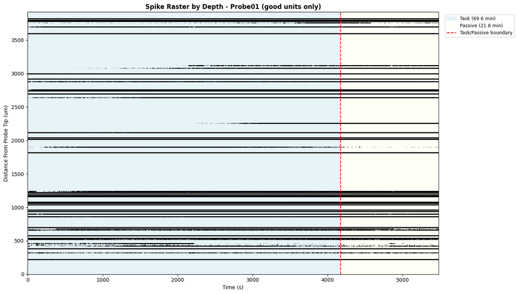

```python
task_epoch = epochs_df[epochs_df['protocol_type'] == 'task'].iloc[0]
passive_epoch = epochs_df[epochs_df['protocol_type'] == 'passive'].iloc[0]

# Calculate durations for labels
task_duration = task_epoch['stop_time'] - task_epoch['start_time']
passive_duration = passive_epoch['stop_time'] - passive_epoch['start_time']

# Filter to good units only (IBL quality score == 1)
df = units_probe_df[units_probe_df['ibl_quality_score'] == 1].copy()
print(f"Number of good units on {probe_name}: {len(units_probe_df[units_probe_df['ibl_quality_score'] == 1])}")

# Sort units by depth
units_probe = df.sort_values('distance_from_probe_tip_um')

# Create figure
fig, ax = plt.subplots(figsize=(14, 8))

# Add epoch background colors with duration in labels
ax.axvspan(task_epoch['start_time'], task_epoch['stop_time'],
           color='lightblue', alpha=0.3, label=f'Task ({task_duration/60:.1f} min)')
ax.axvspan(passive_epoch['start_time'], passive_epoch['stop_time'],
           color='lightyellow', alpha=0.3, label=f'Passive ({passive_duration/60:.1f} min)')

# Plot spikes for each unit at its depth
for idx, (unit_id, unit) in enumerate(units_probe.iterrows()):
    spike_times = unit['spike_times']
    depth = unit['distance_from_probe_tip_um']

    # Plot all spikes
    ax.scatter(spike_times, np.full(len(spike_times), depth),
               c='black', s=1.0, marker='|', linewidths=0.5, alpha=0.5)

# Add epoch boundary line
ax.axvline(task_epoch['stop_time'], color='red', linestyle='--', linewidth=1.5, label='Task/Passive boundary')

# Labels and styling
ax.set_xlabel('Time (s)')
ax.set_ylabel('Distance From Probe Tip (um)')
ax.set_title(f'Spike Raster by Depth - {probe_name} (good units only)',
             fontsize=12, fontweight='bold')
ax.set_xlim(0, passive_epoch['stop_time'])
ax.set_ylim(0, units_probe['distance_from_probe_tip_um'].max() + 100)

# Keep y-axis normal (depth increases upward, deeper units at top)

# Add legend outside the plot
ax.legend(loc='upper left', bbox_to_anchor=(1.01, 1), fontsize=9)

plt.tight_layout()
plt.show()
```

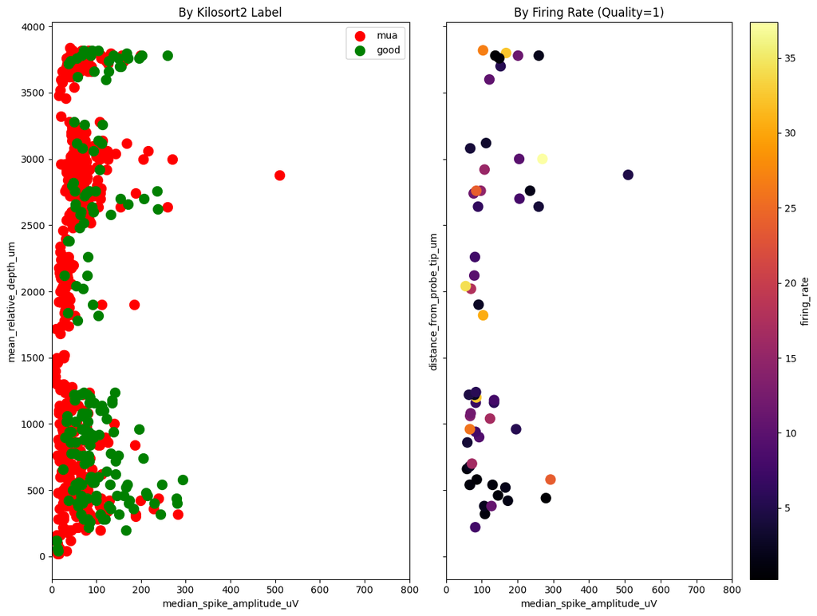

```python
import matplotlib.pyplot as plt

fig, axes = plt.subplots(1, 2, figsize=(12, 9), sharey=True)

# Left plot - colored by kilosort2_label
df = units_probe_df
value_to_color = {"mua": "red", "good": "green"}

for label, color in value_to_color.items():
    subset = df[df["kilosort2_label"] == label]
    axes[0].scatter(
        subset["median_spike_amplitude_uV"],
        subset["distance_from_probe_tip_um"],
        c=color,
        label=label,
        s=100,
    )
axes[0].set_xlim([0, 800])
axes[0].set_xlabel("median_spike_amplitude_uV")
axes[0].set_ylabel("mean_relative_depth_um")
axes[0].set_title("By Kilosort2 Label")
axes[0].legend()

# Right plot - colored by firing_rate
df = units_probe_df[units_probe_df["ibl_quality_score"] == 1]

df.plot.scatter(
    x="median_spike_amplitude_uV",
    y="distance_from_probe_tip_um",
    c="firing_rate",
    colormap="inferno",
    s=100,
    ax=axes[1]
)
axes[1].set_xlim([0, 800])
axes[1].set_xlabel("median_spike_amplitude_uV")
axes[1].set_title("By Firing Rate (Quality=1)")

plt.tight_layout()
plt.show()
```

### Accessing Waveform Data

The units table contains mean waveform data stored as `waveform_mean` - a 2D array with shape `(num_samples, num_channels)` for each unit. These are the average spike shapes computed by IBL's spike sorting pipeline:

The electrodes associated with each unit are stored in the `electrodes` column, which provides the channel positions (`rel_y`) needed to reorder waveforms by depth for visualization.

```python
import matplotlib.pyplot as plt
import numpy as np
from matplotlib.patches import Patch

# COSMOS_FULL_NAMES and get_cosmos_color defined above


def get_cosmos_region_data(probe_table):
    """Extract COSMOS region blocks from probe table for visualization."""
    probe_table = probe_table.sort_values("rel_y").reset_index(drop=True)
    cosmos_values = probe_table["cosmos_location"].values
    rel_y_values = probe_table["rel_y"].values

    blocks = []
    current_region = cosmos_values[0]
    block_start = rel_y_values[0]

    for i in range(1, len(cosmos_values)):
        if cosmos_values[i] != current_region:
            block_end = (rel_y_values[i - 1] + rel_y_values[i]) / 2
            blocks.append((current_region, block_start, block_end))
            current_region = cosmos_values[i]
            block_start = block_end

    blocks.append((current_region, block_start, rel_y_values[-1] + 5))

    unique_regions = []
    for region, _, _ in blocks:
        if region not in unique_regions:
            unique_regions.append(region)

    return blocks, unique_regions


def plot_probe_regions(probe_table, ax, unit_depths=None, unit_ids=None):
    """Plot probe with COSMOS region strip and electrode contacts."""
    probe_table = probe_table.sort_values("rel_y").reset_index(drop=True)
    rel_x_values = probe_table["rel_x"].values
    rel_y_values = probe_table["rel_y"].values

    x_min, x_max = rel_x_values.min(), rel_x_values.max()
    y_min, y_max = rel_y_values.min(), rel_y_values.max()

    blocks, unique_regions = get_cosmos_region_data(probe_table)
    strip_width = x_max - x_min + 30
    strip_x = x_min - 15

    for region, y_start, y_end in blocks:
        color = get_cosmos_color(region)
        rect = plt.Rectangle(
            (strip_x, y_start), strip_width, y_end - y_start, facecolor=color, edgecolor="none", alpha=0.5
        )
        ax.add_patch(rect)

    for i in range(len(rel_x_values)):
        rect = plt.Rectangle(
            (rel_x_values[i] - 6, rel_y_values[i] - 5), 12, 10, facecolor="white", edgecolor="black", linewidth=0.3
        )
        ax.add_patch(rect)

    if unit_depths is not None and unit_ids is not None:
        for i, depth in enumerate(unit_depths):
            if i < len(unit_ids):
                ax.text(x_max + 25, depth, str(unit_ids[i]), va="center", ha="left", fontsize=7, color="black", fontweight="bold")

    ax.set_xlim(x_min - 50, x_max + 50)
    ax.set_ylim(y_min - 100, y_max + 100)
    ax.set_xticks([])
    ax.set_ylabel("Depth (um)")
    ax.set_aspect("equal", adjustable="box")
    for spine in ax.spines.values():
        spine.set_visible(False)

    legend_handles = [
        Patch(facecolor=get_cosmos_color(r), edgecolor="black", linewidth=0.5, label=COSMOS_FULL_NAMES.get(r, r), alpha=0.5)
        for r in unique_regions
    ]
    return ax, legend_handles


def plot_waveform_wiggle(waveform_uV, electrode_depths, ax, fs=30000.0, gain=0.4, channel_spacing=0.8):
    """Plot waveform as IBL-style double wiggle plot.

    Parameters
    ----------
    waveform_uV : array
        Waveform data in microvolts (num_samples, num_channels).
    electrode_depths : array
        Depth of each electrode channel.
    ax : matplotlib axis
    fs : float
        Sampling rate in Hz.
    gain : float
        Scaling factor for waveform amplitude.
    channel_spacing : float
        Vertical spacing between channels.
    """
    num_samples, num_channels = waveform_uV.shape

    # Handle mismatch between waveform channels and electrode depths
    n_electrodes = len(electrode_depths)
    if num_channels != n_electrodes:
        # Use only channels that have electrode depths
        num_channels = min(num_channels, n_electrodes)
        waveform_uV = waveform_uV[:, :num_channels]
        electrode_depths = electrode_depths[:num_channels]

    center_sample = num_samples // 2
    time_ms = (np.arange(num_samples) - center_sample) / fs * 1000

    sort_order = np.argsort(electrode_depths)
    wf_sorted = waveform_uV[:, sort_order]
    depths_sorted = electrode_depths[sort_order]

    wf_max = np.abs(wf_sorted).max()
    wf_norm = wf_sorted / wf_max * gain if wf_max > 0 else wf_sorted

    for ch in range(num_channels):
        offset = ch * channel_spacing
        trace = wf_norm[:, ch]
        ax.plot(time_ms, trace + offset, color="black", linewidth=0.5)
        ax.fill_between(time_ms, offset, trace + offset, where=(trace > 0), color="orange", alpha=0.8, linewidth=0)
        ax.fill_between(time_ms, offset, trace + offset, where=(trace < 0), color="slateblue", alpha=0.8, linewidth=0)

    ax.set_xlabel("Time (ms)")
    depth_ticks = np.linspace(depths_sorted.min(), depths_sorted.max(), 5)
    channel_positions = np.linspace(0, (num_channels - 1) * channel_spacing, 5)
    ax.set_yticks(channel_positions)
    ax.set_yticklabels([f"{d:.0f}" for d in depth_ticks])
    ax.set_ylabel("Distance from tip (um)")


def get_max_channel_index(unit):
    """Get the index (0-31) of the max electrode within the unit's electrodes list."""
    max_electrode_idx = unit["max_electrode"].index[0]
    electrodes_indices = unit["electrodes"].index.tolist()
    if max_electrode_idx in electrodes_indices:
        return electrodes_indices.index(max_electrode_idx)
    waveform = unit["waveform_mean"]
    peak_to_peak = waveform.max(axis=0) - waveform.min(axis=0)
    return np.argmax(peak_to_peak)


def plot_max_channel_waveform(waveform_uV, ax, max_ch_idx=None, fs=30000.0):
    """Plot waveform on the max amplitude channel.

    Parameters
    ----------
    waveform_uV : array
        Waveform data in microvolts (num_samples, num_channels).
    ax : matplotlib axis
    max_ch_idx : int, optional
        Index of max channel in the waveform array. If None, computed from waveform.
    fs : float
        Sampling rate in Hz.
    """
    num_samples = waveform_uV.shape[0]
    center_sample = num_samples // 2
    time_ms = (np.arange(num_samples) - center_sample) / fs * 1000

    if max_ch_idx is None:
        peak_to_peak = waveform_uV.max(axis=0) - waveform_uV.min(axis=0)
        max_ch_idx = np.argmax(peak_to_peak)

    trace = waveform_uV[:, max_ch_idx]

    ax.plot(time_ms, trace, color="black", linewidth=1.0)
    ax.fill_between(time_ms, 0, trace, where=(trace > 0), color="orange", alpha=0.8, linewidth=0)
    ax.fill_between(time_ms, 0, trace, where=(trace < 0), color="slateblue", alpha=0.8, linewidth=0)
    ax.axhline(0, color="gray", linestyle="--", linewidth=0.5)
    ax.set_xlabel("Time (ms)")
    ax.set_ylabel("Amplitude (uV)")


def plot_waveform_heatmap(waveform_uV, electrode_depths, ax, fs=30000.0, vmax=None, add_colorbar=False):
    """Plot waveform as a heatmap (time x channel).

    Parameters
    ----------
    waveform_uV : array
        Waveform data in microvolts (num_samples, num_channels).
    electrode_depths : array
        Depth of each electrode channel.
    ax : matplotlib axis
    fs : float
        Sampling rate in Hz.
    vmax : float, optional
        Max value for colormap.
    add_colorbar : bool
        Whether to add a colorbar.
    """
    num_samples, num_channels = waveform_uV.shape

    # Handle mismatch between waveform channels and electrode depths
    n_electrodes = len(electrode_depths)
    if num_channels != n_electrodes:
        num_channels = min(num_channels, n_electrodes)
        waveform_uV = waveform_uV[:, :num_channels]
        electrode_depths = electrode_depths[:num_channels]

    center_sample = num_samples // 2
    time_ms = (np.arange(num_samples) - center_sample) / fs * 1000

    sort_order = np.argsort(electrode_depths)
    wf_sorted = waveform_uV[:, sort_order]
    depths_sorted = electrode_depths[sort_order]

    if vmax is None:
        vmax = np.abs(wf_sorted).max()

    im = ax.imshow(
        wf_sorted.T,
        aspect="auto",
        origin="lower",
        extent=[time_ms[0], time_ms[-1], 0, num_channels],
        cmap="RdBu_r",
        vmin=-vmax,
        vmax=vmax,
    )
    ax.set_xlabel("Time (ms)")

    depth_ticks = np.linspace(depths_sorted.min(), depths_sorted.max(), 5)
    channel_positions = np.linspace(0, num_channels, 5)
    ax.set_yticks(channel_positions)
    ax.set_yticklabels([f"{d:.0f}" for d in depth_ticks])
    ax.set_ylabel("Distance from tip (um)")

    if add_colorbar:
        plt.colorbar(im, ax=ax, label="Amplitude (uV)")
    return im
```

```
Selected 51 good units with valid waveforms from Probe00
Converting waveforms from volts to microvolts for display (factor: 1e6)
```

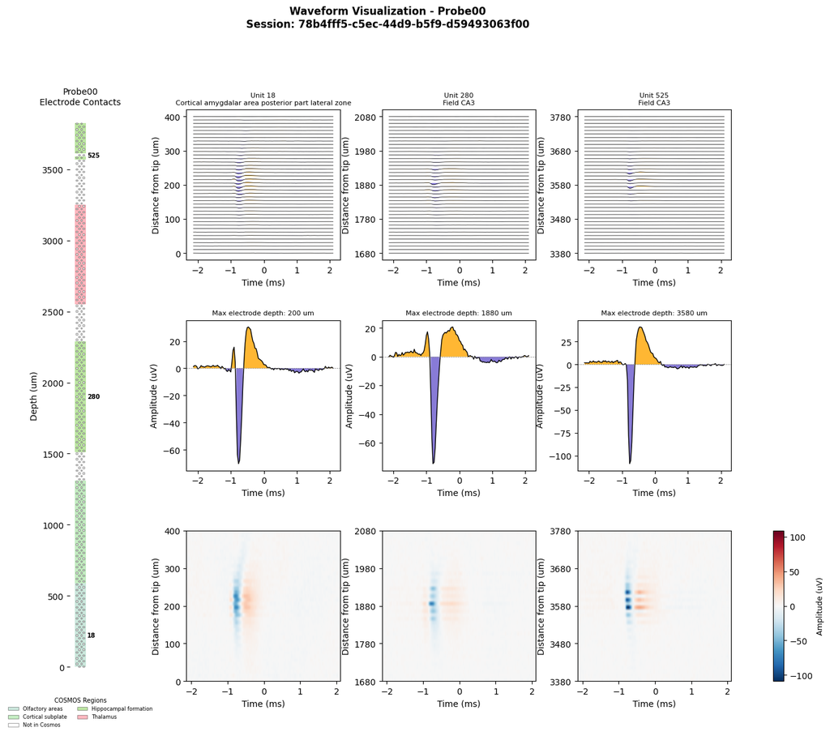

```python
# %% Select good units and create combined waveform visualization
# Get localization data for probe visualization
localization = nwbfile_processed.lab_meta_data.get("localization")
anatomical_tables = localization.anatomical_coordinates_tables
ibl_bregma_table_df = anatomical_tables["ElectrodesIBLBregma"].to_dataframe()

# Extract electrode positions from localized_entity
ibl_bregma_table_df["rel_x"] = [electrode["rel_x"].iloc[0] for electrode in ibl_bregma_table_df["localized_entity"]]
ibl_bregma_table_df["rel_y"] = [electrode["rel_y"].iloc[0] for electrode in ibl_bregma_table_df["localized_entity"]]

# Select good units from the first probe that has them
probe_names = sorted(units_df["probe_name"].unique())
probe_name = None
good_units = None
for candidate in probe_names:
    candidate_units = units_df[(units_df["probe_name"] == candidate) & (units_df["ibl_quality_score"] == 1.0)].copy()
    if len(candidate_units) > 0:
        probe_name = candidate
        good_units = candidate_units
        break

if good_units is None or len(good_units) == 0:
    raise ValueError(f"No good units found in any probe: {probe_names}")

good_units = good_units.sort_values("distance_from_probe_tip_um")
probe_table = ibl_bregma_table_df[ibl_bregma_table_df["probe_name"] == probe_name].copy()

# Filter out units with any NaN waveforms (some units have partial NaN data)
valid_waveform_mask = [not np.isnan(unit["waveform_mean"]).any() for _, unit in good_units.iterrows()]
good_units = good_units[valid_waveform_mask]

print(f"Selected {len(good_units)} good units with valid waveforms from {probe_name}")

# Select 3 units evenly spaced across depth
depths = good_units["distance_from_probe_tip_um"].values
target_depths = np.linspace(depths.min(), depths.max(), 3)
selected_indices = []
available_mask = np.ones(len(good_units), dtype=bool)

for target in target_depths:
    available_depths = depths.copy()
    available_depths[~available_mask] = np.inf
    closest_idx = np.argmin(np.abs(available_depths - target))
    selected_indices.append(closest_idx)
    available_mask[closest_idx] = False

selected_indices = sorted(selected_indices, key=lambda i: depths[i])
example_units = good_units.iloc[selected_indices]
example_depths = example_units["distance_from_probe_tip_um"].values.tolist()
example_unit_ids = example_units.index.tolist()

# Convert waveforms from volts to microvolts for visualization
# NWB schema has waveform_mean unit fixed to 'volts', so we always convert to uV for display
conversion_factor = 1e6
print("Converting waveforms from volts to microvolts for display (factor: 1e6)")

# Compute shared vmax for heatmaps (in microvolts)
shared_vmax = max(np.abs(unit["waveform_mean"] * conversion_factor).max() for _, unit in example_units.iterrows())

# Create combined figure: Probe | 3x3 waveforms | colorbar
fig = plt.figure(figsize=(16, 12))
gs = fig.add_gridspec(3, 5, width_ratios=[1.0, 1.2, 1.2, 1.2, 0.08], wspace=0.35, hspace=0.4)

# Probe visualization (spans all 3 rows)
ax_probe = fig.add_subplot(gs[:, 0])
_, legend_handles = plot_probe_regions(probe_table, ax_probe, unit_depths=example_depths, unit_ids=example_unit_ids)
ax_probe.set_title(f"{probe_name}\nElectrode Contacts", fontsize=10)

if legend_handles:
    ax_probe.legend(handles=legend_handles, loc="upper center", bbox_to_anchor=(0.5, -0.02),
                    ncol=2, fontsize=6, frameon=False, title="COSMOS Regions", title_fontsize=7)

# Store last heatmap image for shared colorbar
last_heatmap_im = None

# Plot waveforms for each unit (columns 1-3)
for col_idx, (unit_id, unit) in enumerate(example_units.iterrows()):
    # Convert waveform to microvolts for visualization
    waveform_uV = unit["waveform_mean"] * conversion_factor
    depth = unit["distance_from_probe_tip_um"]
    region = unit["max_electrode"]["location"].values[0]
    electrode_depths = unit["electrodes"]["rel_y"].values

    # Get max channel index from the unit's electrode mapping
    max_ch_idx = get_max_channel_index(unit)
    max_electrode_depth = unit["max_electrode"]["rel_y"].values[0]

    # Row 0: Wiggle plot
    ax_wiggle = fig.add_subplot(gs[0, col_idx + 1])
    plot_waveform_wiggle(waveform_uV, electrode_depths, ax_wiggle, gain=0.4, channel_spacing=0.8)
    ax_wiggle.set_title(f"Unit {unit_id}\n{region}", fontsize=8)

    # Row 1: Max channel waveform (use max_electrode depth in title)
    ax_max = fig.add_subplot(gs[1, col_idx + 1])
    plot_max_channel_waveform(waveform_uV, ax_max, max_ch_idx=max_ch_idx)
    ax_max.set_title(f"Max electrode depth: {max_electrode_depth:.0f} um", fontsize=8)

    # Row 2: Heatmap
    ax_heatmap = fig.add_subplot(gs[2, col_idx + 1])
    last_heatmap_im = plot_waveform_heatmap(waveform_uV, electrode_depths, ax_heatmap, vmax=shared_vmax)

# Add shared colorbar for heatmaps
cbar_ax = fig.add_subplot(gs[2, 4])
cbar = fig.colorbar(last_heatmap_im, cax=cbar_ax)
cbar.set_label("Amplitude (uV)", fontsize=9)

fig.suptitle(f"Waveform Visualization - {probe_name}\nSession: {nwbfile_processed.session_id}",
             fontsize=12, fontweight="bold", y=1.02)
plt.tight_layout()
plt.show()
```

## Loading Trials Data

```python
trials = nwbfile_processed.trials
trials
```

trials (TimeIntervals)

description: Trial data from the IBL decision-making task. On each trial, a visual stimulus (Gabor patch) appears on the left or right of a screen, and the mouse must move it to the center by turning a wheel with its front paws within 60 seconds. Correct responses are rewarded with water; incorrect responses trigger a white noise auditory cue and 2-second timeout. If no response is recorded during 60 seconds, a white noise auditory cue is presented. Trial timeline: (1) start_time begins a quiescence period where the mouse must hold the wheel still; (2) after quiescence_period elapses, the stimulus and auditory go cue are presented (gabor_stimulus_onset_time); (3) the mouse responds by turning the wheel to move the stimulus; correct choices are defined by moving the visual stimulus into the center; (4) feedback_time marks reward punishment or presentation of the white noise auditory cue; (5) stop_time marks trial end. Stimulus contrast is uniformly sampled from 5 values (0%, 6.25%, 12.5%, 25%, 100%). On 0% contrast trials, no stimulus is visible but a correct side is still assigned based on block probability, allowing mice to perform above chance using prior information. After an initial 90 unbiased trials, stimulus probability alternates between left-biased (80:20) and right-biased (20:80) blocks of 20-100 trials (mean 51). Block changes are not cued. See IBL et al. (2021) eLife 10:e63711 for full task details.

**columns**

**start_time**

The beginning of the trial.

**stop_time**

The end of the trial.

**quiescence_period**

Required duration (seconds) the mouse must hold the wheel still before stimulus presentation. Sampled from exponential distribution (400-700ms, mean ~550ms).

**gabor_stimulus_onset_time**

Time when the visual stimulus (Gabor patch) appears on the screen, detected by the photodiode. Presented together with the auditory go cue.

**auditory_cue_time**

Time of the auditory go cue (100ms, 5kHz tone) signaling the mouse may respond. Presented together with the visual stimulus.

**wheel_movement_onset_time**

Time of first detected wheel movement (>= 0.1 radians threshold) after the go cue.

**choice_registration_time**

Time when the mouse's choice was registered: either the wheel movement reached the +/-35 degree threshold, or 60-second timeout elapsed.

**feedback_time**

Time of feedback delivery: water reward for correct responses, or white noise pulse + 2-second timeout for incorrect responses.

**gabor_stimulus_offset_time**

Time when the Gabor patch disappears from the screen, detected by the photodiode.

**gabor_stimulus_contrast**

Contrast of the Gabor patch as a percentage (0, 6.25, 12.5, 25, or 100). Uniformly sampled across trials. At 0% contrast (no visible stimulus), mice can still perform above chance using block probability prior.

**gabor_stimulus_side**

Side on the screen where stimulus was presented: 'left' or 'right'. Even at 0% contrast (no visible stimulus), a side is assigned to the stimulus for the trial, enabling the mice to perform a correct response using prior knowledge of the block distribution.

**mouse_wheel_choice**

Mouse's response: 'counter_clockwise' (counter_clockwise wheel turn moving stimulus leftward), 'clockwise' (clockwise wheel turn moving stimulus rightward), or 'none' (no response within 60s timeout). clockwise and counter_clockwise are wheel movements as seen from the perspective of the mouse

**is_mouse_rewarded**

Whether the mouse received a water reward (True) or not (False). If False, an additional negative feedback consisting of an auditory white noise stimulus.

**reward_volume_uL**

Volume of water reward in microliters (0 for incorrect/timeout trials).

**probability_left**

Block prior probability for the visual stimulus to be presented on the left side of the screen. After an initial block of 90 unbiased trials (0.5), blocks alternate between a probability of 0.2 (right-biased) and 0.8 (left-biased). Block lengths: 20-100 trials from truncated geometric distribution (mean 51). Block changes are not cued.

**block_type**

Block type based on stimulus probability bias: 'unbiased' (probability_left=0.5), 'left_block' (probability_left=0.8, stimulus 80% likely on the left side of the screen), or 'right_block' (probability_left=0.2, stimulus 80% likely on the right side of the screen).

**block_index**

Zero-indexed block number. Increments each time probability_left changes. Block 0 is the initial unbiased block (90 trials at 0.5 probability).

**table**

| id | start_time | stop_time | quiescence_period | gabor_stimulus_onset_time | auditory_cue_time | wheel_movement_onset_time | choice_registration_time | feedback_time | gabor_stimulus_offset_time | gabor_stimulus_contrast | gabor_stimulus_side | mouse_wheel_choice | is_mouse_rewarded | reward_volume_uL | probability_left | block_type | block_index |
| --- | --- | --- | --- | --- | --- | --- | --- | --- | --- | --- | --- | --- | --- | --- | --- | --- | --- |
| 0 | 103.884959 | 115.226015 | 0.541949 | NaN | 113.439040 | 113.477967 | 113.677692 | 113.677785 | 114.725958 | 100.0 | right | counter_clockwise | True | 1.5 | 0.5 | unbiased | 0 |
| 1 | 115.866423 | 119.975890 | 0.457997 | 116.381644 | 116.382710 | 117.707967 | 118.402564 | 118.402663 | 119.475868 | 25.0 | left | clockwise | True | 1.5 | 0.5 | unbiased | 0 |
| 2 | 120.616099 | 123.259428 | 0.426862 | 121.098089 | 121.099023 | 121.328967 | 121.695111 | 121.695203 | 122.759341 | 25.0 | right | counter_clockwise | True | 1.5 | 0.5 | unbiased | 0 |
| 3 | 123.949635 | 131.142860 | 0.423191 | 124.431558 | 124.432692 | 128.465967 | 128.570015 | 128.571022 | 130.642804 | 12.5 | right | clockwise | False | 0.0 | 0.5 | unbiased | 0 |

... and 888 more row(s).

```python
trials_df = trials.to_dataframe()
trials_df
```

| id | start_time | stop_time | quiescence_period | gabor_stimulus_onset_time | auditory_cue_time | wheel_movement_onset_time | choice_registration_time | feedback_time | gabor_stimulus_offset_time | gabor_stimulus_contrast | gabor_stimulus_side | mouse_wheel_choice | is_mouse_rewarded | reward_volume_uL | probability_left | block_type | block_index |
| --- | --- | --- | --- | --- | --- | --- | --- | --- | --- | --- | --- | --- | --- | --- | --- | --- | --- |
| 0 | 103.884959 | 115.226015 | 0.541949 | NaN | 113.439040 | 113.477967 | 113.677692 | 113.677785 | 114.725958 | 100.00 | right | counter_clockwise | True | 1.5 | 0.5 | unbiased | 0 |
| 1 | 115.866423 | 119.975890 | 0.457997 | 116.381644 | 116.382710 | 117.707967 | 118.402564 | 118.402663 | 119.475868 | 25.00 | left | clockwise | True | 1.5 | 0.5 | unbiased | 0 |
| 2 | 120.616099 | 123.259428 | 0.426862 | 121.098089 | 121.099023 | 121.328967 | 121.695111 | 121.695203 | 122.759341 | 25.00 | right | counter_clockwise | True | 1.5 | 0.5 | unbiased | 0 |
| 3 | 123.949635 | 131.142860 | 0.423191 | 124.431558 | 124.432692 | 128.465967 | 128.570015 | 128.571022 | 130.642804 | 12.50 | right | clockwise | False | 0.0 | 0.5 | unbiased | 0 |
| 4 | 131.780569 | 134.242488 | 0.501897 | 132.348152 | 132.349018 | 132.234967 | 132.667375 | 132.667490 | 133.742494 | 25.00 | right | counter_clockwise | True | 1.5 | 0.5 | unbiased | 0 |
| ... | ... | ... | ... | ... | ... | ... | ... | ... | ... | ... | ... | ... | ... | ... | ... | ... | ... |
| 887 | 4126.191615 | 4129.673361 | 0.520284 | 4126.762697 | 4126.763797 | 4126.945967 | 4127.106626 | 4127.107466 | 4129.173315 | 12.50 | right | clockwise | False | 0.0 | 0.8 | left_block | 17 |
| 888 | 4130.436269 | 4133.523842 | 0.597641 | 4131.079445 | 4131.080445 | 4131.272967 | 4131.967004 | 4131.967099 | 4133.023805 | 6.25 | left | clockwise | True | 1.5 | 0.8 | left_block | 17 |
| 889 | 4134.293658 | 4136.623874 | 0.406433 | 4134.746018 | 4134.747084 | 4134.891967 | 4135.059662 | 4135.059756 | 4136.123828 | 12.50 | left | clockwise | True | 1.5 | 0.8 | left_block | 17 |
| 890 | 4137.435277 | 4139.756922 | 0.552693 | 4138.046090 | 4138.047090 | 4137.946967 | 4138.188392 | 4138.188510 | 4139.256848 | 6.25 | left | clockwise | True | 1.5 | 0.8 | left_block | 17 |
| 891 | 4140.520935 | 4145.340227 | 0.681441 | 4142.495992 | 4142.497092 | 4142.510967 | 4142.772978 | 4142.773734 | 4144.840116 | 12.50 | right | clockwise | False | 0.0 | 0.8 | left_block | 17 |

892 rows × 17 columns

### Overview of Trials

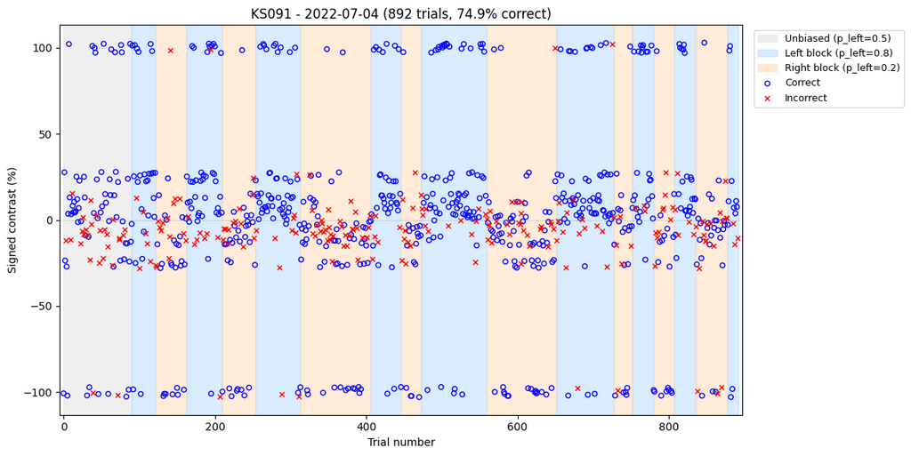

```python
from pathlib import Path

import matplotlib.pyplot as plt
import numpy as np

# %% Compute signed contrast for y-position
contrast = trials_df["gabor_stimulus_contrast"].values
side = trials_df["gabor_stimulus_side"].values
signed_contrast = np.where(side == "left", contrast, -contrast)
trials_df["signed_contrast"] = signed_contrast

# Add jitter for overlapping points
np.random.seed(42)
trials_df["y_jitter"] = signed_contrast + np.random.uniform(-3, 3, len(trials_df))

# %% Define block background colors
block_bg_colors = {
    "unbiased": "#E0E0E0",
    "left_block": "#B3D9FF",
    "right_block": "#FFD9B3",
}
block_labels = {
    "unbiased": "Unbiased (p_left=0.5)",
    "left_block": "Left block (p_left=0.8)",
    "right_block": "Right block (p_left=0.2)",
}

# %% Create figure
fig, ax = plt.subplots(figsize=(14, 6))

# Plot block backgrounds
block_changes = trials_df["block_index"].diff().fillna(1) != 0
block_starts = trials_df.index[block_changes].tolist()
block_starts.append(len(trials_df))

added_labels = set()
for i in range(len(block_starts) - 1):
    start_index = block_starts[i]
    end_index = block_starts[i + 1]
    block_type = trials_df.loc[start_index, "block_type"]
    label = block_labels.get(block_type) if block_type not in added_labels else None
    ax.axvspan(
        start_index,
        end_index,
        color=block_bg_colors.get(block_type, "white"),
        alpha=0.5,
        zorder=0,
        label=label,
    )
    added_labels.add(block_type)

# Plot correct trials (blue circles)
correct = trials_df[trials_df["is_mouse_rewarded"]]
ax.scatter(
    correct.index,
    correct["y_jitter"],
    marker="o",
    s=20,
    facecolors="none",
    edgecolors="blue",
    linewidths=1,
    label="Correct",
    zorder=2,
)

# Plot incorrect trials (red X)
incorrect = trials_df[~trials_df["is_mouse_rewarded"]]
ax.scatter(
    incorrect.index,
    incorrect["y_jitter"],
    color="red",
    marker="x",
    s=20,
    linewidths=1,
    label="Incorrect",
    zorder=2,
)

# Formatting
ax.set_xlabel("Trial number")
ax.set_ylabel("Signed contrast (%)")
ax.set_xlim(-5, len(trials_df) + 5)
ax.axhline(0, color="gray", linestyle="--", linewidth=0.5, alpha=0.5)

# Session info
subject = nwbfile.subject.subject_id if nwbfile.subject else "Unknown"
session_date = nwbfile.session_start_time.strftime("%Y-%m-%d")
n_correct = len(correct)
performance = n_correct / len(trials_df) * 100

ax.set_title(f"{subject} - {session_date} ({len(trials_df)} trials, {performance:.1f}% correct)")
ax.legend(loc="upper left", bbox_to_anchor=(1.01, 1), fontsize=9)

plt.tight_layout(rect=[0, 0, 0.85, 1])
plt.show()
```

### Psychometric Curves

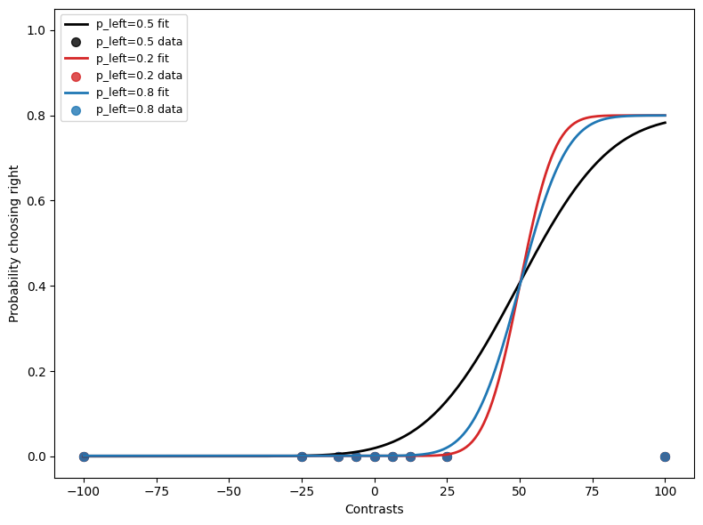

```python
from pathlib import Path

import matplotlib.pyplot as plt
import numpy as np
import psychofit as psy

# %% Compute signed contrast
# Convention: positive = left stimulus, negative = right stimulus
# This ensures P(choose right) increases with signed contrast
contrast = trials_df["gabor_stimulus_contrast"].values
side = trials_df["gabor_stimulus_side"].values
signed_contrast = np.where(side == "left", contrast, -contrast)

trials_df["signed_contrast"] = signed_contrast
trials_df["chose_right"] = (trials_df["mouse_wheel_choice"] == "right").astype(int)

# %% Define block types and colors (matching IBL style)
blocks = {
    0.5: {"color": "black", "label": "p_left=0.5"},
    0.2: {"color": "tab:red", "label": "p_left=0.2"},
    0.8: {"color": "tab:blue", "label": "p_left=0.8"},
}

# %% Fit and collect data for each block
x_fit = np.linspace(-100, 100, 200)
block_results = {}

for p_left, style in blocks.items():
    block_trials = trials_df[trials_df["probability_left"] == p_left]

    if len(block_trials) == 0:
        print(f"No trials for p_left={p_left}")
        continue

    # Aggregate by contrast
    grouped = (
        block_trials.groupby("signed_contrast")
        .agg(
            n_total=("chose_right", "count"),
            p_right=("chose_right", "mean"),
        )
        .reset_index()
    )

    # Fit psychometric curve
    data = np.vstack(
        [grouped["signed_contrast"].values, grouped["n_total"].values, grouped["p_right"].values]
    )

    pars, _ = psy.mle_fit_psycho(
        data,
        P_model="erf_psycho_2gammas",
        parstart=np.array([0.0, 40.0, 0.1, 0.1]),
        parmin=np.array([-50.0, 10.0, 0.0, 0.0]),
        parmax=np.array([50.0, 50.0, 0.2, 0.2]),
        nfits=10,
    )

    y_fit = psy.erf_psycho_2gammas(pars, x_fit)

    block_results[p_left] = {
        "grouped": grouped,
        "pars": pars,
        "y_fit": y_fit,
        "n_trials": len(block_trials),
    }

# %% Plot psychometric curves for all blocks
fig, ax = plt.subplots(figsize=(8, 6))

for p_left, style in blocks.items():
    if p_left not in block_results:
        continue

    result = block_results[p_left]
    grouped = result["grouped"]
    color = style["color"]
    label = style["label"]

    # Fitted curve
    ax.plot(x_fit, result["y_fit"], color=color, linewidth=2, label=f"{label} fit")

    # Data points
    ax.scatter(
        grouped["signed_contrast"],
        grouped["p_right"],
        color=color,
        s=50,
        alpha=0.8,
        label=f"{label} data",
    )

# Formatting
ax.set_xlabel("Contrasts")
ax.set_ylabel("Probability choosing right")
ax.set_ylim(-0.05, 1.05)
ax.legend(loc="upper left", fontsize=9)

plt.tight_layout()
plt.show()
```

### Reaction Time by Contrast

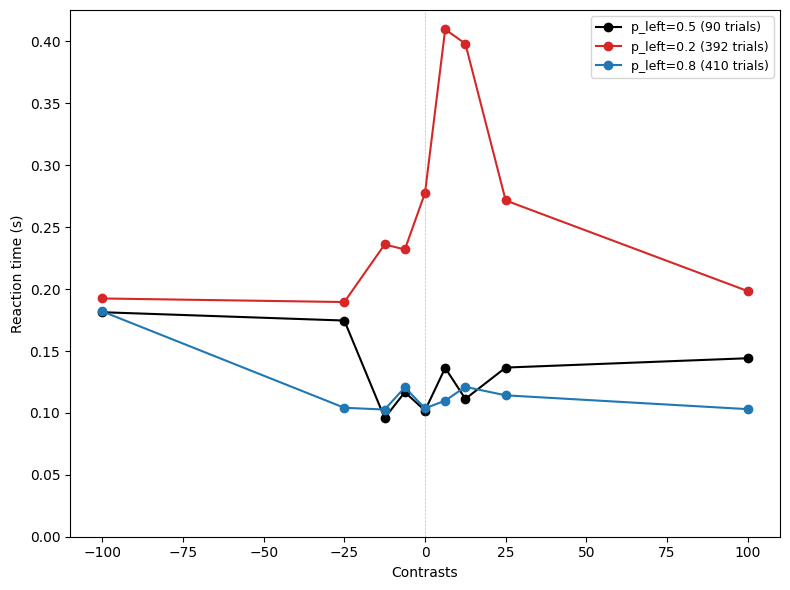

```python
from pathlib import Path

import matplotlib.pyplot as plt
import numpy as np

# %% Calculate reaction time and signed contrast
trials_df["reaction_time"] = (
    trials_df["wheel_movement_onset_time"] - trials_df["gabor_stimulus_onset_time"]
)

# Signed contrast: positive = left stimulus, negative = right stimulus
contrast = trials_df["gabor_stimulus_contrast"].values
side = trials_df["gabor_stimulus_side"].values
trials_df["signed_contrast"] = np.where(side == "left", contrast, -contrast)

# Get unique contrasts sorted
contrasts = sorted(trials_df["signed_contrast"].unique())

# %% Define block styles (matching IBL and psychometric_curve.py)
blocks = {
    0.5: {"color": "black", "label": "p_left=0.5"},
    0.2: {"color": "tab:red", "label": "p_left=0.2"},
    0.8: {"color": "tab:blue", "label": "p_left=0.8"},
}

# %% Plot reaction time by contrast for each block
fig, ax = plt.subplots(figsize=(8, 6))

for p_left, style in blocks.items():
    block_trials = trials_df[trials_df["probability_left"] == p_left]

    if len(block_trials) == 0:
        continue

    # Calculate median reaction time for each contrast (robust to outliers)
    median_rt = []
    contrast_vals = []

    for c in contrasts:
        contrast_trials = block_trials[block_trials["signed_contrast"] == c]
        if len(contrast_trials) > 0:
            median_rt.append(contrast_trials["reaction_time"].median())
            contrast_vals.append(c)

    ax.plot(
        contrast_vals,
        median_rt,
        "o-",
        color=style["color"],
        label=f"{style['label']} ({len(block_trials)} trials)",
        linewidth=1.5,
        markersize=6,
    )

# Formatting
ax.set_xlabel("Contrasts")
ax.set_ylabel("Reaction time (s)")
ax.set_xlim(-110, 110)
ax.set_ylim(0, None)
ax.axvline(0, color="gray", linestyle="--", linewidth=0.5, alpha=0.5)
ax.legend(loc="upper right", fontsize=9)

plt.tight_layout()
plt.show()
```